# Study 2 — Full Sample (MAR) Analyses

Anonymous authors

2025-10-13

# Study 2 — Full Sample (MAR) Analyses

This document reports the Study 2 analyses on the **full randomised sample** under a missing-at-random (MAR) assumption: all participants who provided valid initial-session data are retained, and missing follow-up responses are handled by the mixed models rather than by listwise deletion. This is the full-sample counterpart to the follow-up completer-only analyses and supports a like-for-like attrition robustness comparison.

As in all Study 2 analyses, participants with a Stage-1 baseline (task 0) accuracy of `>= 0.90` are excluded as a ceiling-effect screen. Unless otherwise noted, all linear mixed models include Age, Gender, Field, and weekly LLM-usage as covariates, with by-participant (and, for task-level outcomes, by-task) random effects. Hypotheses: **H1** task performance (accuracy), **H2** confidence and attitude change over time, and **H3** moderation of long-term outcomes.

## Packages

```r
library(broom)
library(car)
library(DescTools)
library(dplyr)
library(DT)
library(effectsize)
library(emmeans)
library(ggplot2)
library(janitor)
library(lme4)
library(lmerTest)
library(lsr)
library(MASS)
library(openxlsx)
library(ordinal)
library(performance)
library(readxl)
library(stringr)
library(tidyr)
library(report)
library(interactions)

# Output directories: results are organised into per-hypothesis subfolders.
for (h in c("H1", "H2", "H3")) {
  dir.create(file.path("results/MAR", h), recursive = TRUE, showWarnings = FALSE)
}
```

## Data Preprocessing

The full-sample data are loaded, the ceiling-effect screen (`stage1_task0_accuracy < 0.9`) is applied, background variables are recoded, and the data are reshaped to long format for the mixed-model analyses. The factor ordering AI < AI + Human < Human is used throughout.

```r
df <- read_xlsx("data/Study_2_Full_Data.xlsx")
```

```r
# Reproduce the follow-up interval summary from the deposited interval-days
# input. Exact submission timestamps are not needed for this analysis and are
# therefore not included in the public data.
interval_data <- read_xlsx("data/Followup_Interval_Days.xlsx")

required_interval_columns <- c("ID", "Label", "paired", "interval_days")
if (!identical(names(interval_data), required_interval_columns)) {
  stop(
    "Followup_Interval_Days.xlsx must contain exactly: ",
    paste(required_interval_columns, collapse = ", ")
  )
}
if (nrow(interval_data) != nrow(df) || anyDuplicated(interval_data$ID)) {
  stop("Follow-up interval data must contain one row for each Study 2 participant.")
}

id_match <- match(interval_data$ID, df$ID)
if (anyNA(id_match) ||
    !all(as.character(interval_data$Label) == as.character(df$Label[id_match]))) {
  stop("Follow-up interval IDs or condition labels do not match Study_2_Full_Data.xlsx.")
}
if (anyNA(interval_data$paired) ||
    !all(interval_data$paired == !is.na(interval_data$interval_days))) {
  stop("The paired flag must identify exactly the rows with an observed interval_days value.")
}

interval_descriptives <- function(x, sample_name) {
  x <- x[!is.na(x)]
  data.frame(
    Sample = sample_name,
    n = length(x),
    `Mean (days)` = mean(x),
    SD = sd(x),
    Median = median(x),
    Q1 = unname(quantile(x, 0.25, type = 7)),
    Q3 = unname(quantile(x, 0.75, type = 7)),
    IQR = IQR(x, type = 7),
    Minimum = min(x),
    Maximum = max(x),
    check.names = FALSE
  )
}

all_intervals <- interval_data$interval_days[interval_data$paired]
analytic_ids <- df$ID[df$stage1_task0_accuracy < 0.9]
analytic_intervals <- interval_data$interval_days[
  interval_data$paired & interval_data$ID %in% analytic_ids
]

if (length(all_intervals) != 87 || length(analytic_intervals) != 84) {
  stop("Expected 87 follow-up respondents and 84 analytic completers.")
}

interval_summary <- rbind(
  interval_descriptives(all_intervals, "All follow-up respondents"),
  interval_descriptives(analytic_intervals, "Analytic completers")
)

dir.create("results/MAR/Baseline", recursive = TRUE, showWarnings = FALSE)
interval_workbook <- createWorkbook()
addWorksheet(interval_workbook, "Summary", gridLines = FALSE)

title_style <- createStyle(
  fontName = "Arial", fontSize = 11, fontColour = "#FFFFFF",
  fgFill = "#1F4E78", textDecoration = "bold", halign = "left"
)
header_style <- createStyle(
  fontName = "Arial", fontSize = 11, fontColour = "#1F1F1F",
  fgFill = "#D9EAF7", textDecoration = "bold", halign = "center",
  border = "bottom", borderStyle = "medium", borderColour = "#1F4E78"
)
count_style <- createStyle(numFmt = "0", halign = "right")
value_style <- createStyle(numFmt = "0.00", halign = "right")
note_style <- createStyle(fontName = "Arial", fontSize = 9, wrapText = TRUE)

mergeCells(interval_workbook, "Summary", cols = 1:10, rows = 1)
writeData(interval_workbook, "Summary", "Observed Follow-up Interval", startRow = 1)
addStyle(interval_workbook, "Summary", title_style, rows = 1, cols = 1:10, gridExpand = TRUE)
writeData(
  interval_workbook, "Summary", interval_summary,
  startRow = 3, headerStyle = header_style, borders = "rows"
)
addStyle(interval_workbook, "Summary", count_style, rows = 4:5, cols = 2, gridExpand = TRUE)
addStyle(interval_workbook, "Summary", value_style, rows = 4:5, cols = 3:10, gridExpand = TRUE)

mergeCells(interval_workbook, "Summary", cols = 1:10, rows = 7)
mergeCells(interval_workbook, "Summary", cols = 1:10, rows = 8)
writeData(
  interval_workbook, "Summary",
  "Analytic completers exclude three participants meeting the preregistered ceiling criterion (stage1_task0_accuracy >= 0.9).",
  startRow = 7
)
writeData(
  interval_workbook, "Summary",
  "Source: data/Followup_Interval_Days.xlsx. The deposited source contains pseudonymous IDs and interval-days values but no exact submission timestamps.",
  startRow = 8
)
addStyle(interval_workbook, "Summary", note_style, rows = 7:8, cols = 1:10, gridExpand = TRUE)

setColWidths(interval_workbook, "Summary", cols = 1, widths = 31)
setColWidths(interval_workbook, "Summary", cols = 2:10, widths = 14)
setRowHeights(interval_workbook, "Summary", rows = c(7, 8), heights = c(28, 34))
freezePane(interval_workbook, "Summary", firstActiveRow = 4)
pageSetup(
  interval_workbook, "Summary", orientation = "landscape",
  fitToWidth = 1, fitToHeight = 1, paperSize = 9
)
saveWorkbook(
  interval_workbook,
  "results/MAR/Baseline/Followup_Interval_Descriptives.xlsx",
  overwrite = TRUE
)

interval_summary
```

```
##                      Sample  n Mean (days)       SD   Median       Q1       Q3
## 1 All follow-up respondents 87    27.69719 3.091513 27.32862 25.56437 28.73056
## 2       Analytic completers 84    27.55490 2.893440 27.32848 25.45872 28.56472
##        IQR  Minimum  Maximum
## 1 3.166186 23.02758 38.91831
## 2 3.106001 23.02758 38.91831
```

```r
# Define Variables and Factor Levels
rename_vars <- c(
  "Pre_GLAT_Objective_AI_Literacy",
  "Pre_AILS_CCS_Subjective_AI_Literacy",
  "Pre_AI_Trust",
  "Pre_AI_Usefulness",
  "Pre_AI_Affect",
  "Pre_AI_Self_Efficacy",
  "Pre_Behavioral_Intention",
  "stage1_task0_accuracy",
  "stage1_task1_accuracy",
  "stage1_task2_accuracy",
  "stage1_task3_accuracy",
  "stage2_task0_accuracy",
  "stage2_task1_accuracy",
  "stage2_task2_accuracy",
  "stage2_task3_accuracy",
  "stage3_task0_accuracy",
  "stage3_task1_accuracy",
  "stage3_task2_accuracy",
  "stage3_task3_accuracy",
  "stage1_task0_confidence",
  "stage1_task1_confidence",
  "stage1_task2_confidence",
  "stage1_task3_confidence",
  "stage2_task0_confidence",
  "stage2_task1_confidence",
  "stage2_task2_confidence",
  "stage2_task3_confidence",
  "stage3_task0_confidence",
  "stage3_task1_confidence",
  "stage3_task2_confidence",
  "stage3_task3_confidence",
  "stage2_task0_willing",
  "stage2_task1_willing",
  "stage2_task2_willing",
  "stage2_task3_willing",
  "stage3_task0_willing",
  "stage3_task1_willing",
  "stage3_task2_willing",
  "stage3_task3_willing",
  "stage2_task0_useful",
  "stage2_task1_useful",
  "stage2_task2_useful",
  "stage2_task3_useful",
  "stage3_task0_useful",
  "stage3_task1_useful",
  "stage3_task2_useful",
  "stage3_task3_useful",
  "Post_AI_Trust",
  "Post_AI_Usefulness",
  "Post_AI_Affect",
  "Post_Behavioral_Intention"
)

df$Label <- factor(df$Label, levels = c("AI", "AI Human", "Human"))
```

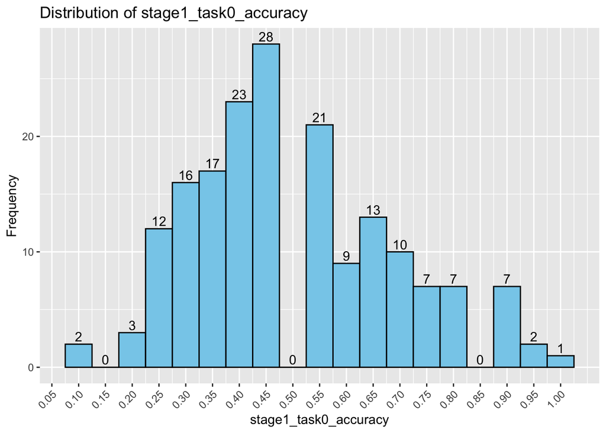

```r
# Check Distribution
ggplot(df, aes(x = stage1_task0_accuracy)) +
  geom_histogram(binwidth = 0.05, fill = "skyblue", color = "black") +
  stat_bin(binwidth = 0.05, geom = "text", aes(label = ..count..), vjust = -0.3) +
  scale_x_continuous(
    breaks = seq(0, 1, by = 0.05),
    labels = sprintf("%.2f", seq(0, 1, by = 0.05))
  ) +
  labs(
    title = "Distribution of stage1_task0_accuracy",
    x = "stage1_task0_accuracy",
    y = "Frequency"
  ) +
  theme(axis.text.x = element_text(angle = 45, hjust = 1))
```

```r
# Filter Out stage1_task0_accuracy >= 0.9
Count <- sum(df$stage1_task0_accuracy >= 0.9)
Count
```

```
## [1] 3
```

```r
df <- df %>%
  filter(stage1_task0_accuracy < 0.9)
```

```r
# Recode Background and LLM Usage
df$Stats_Background <- cut(
  as.numeric(as.character(df$Stats_Background)),
  breaks = c(1, 3, 5, 8),
  labels = c("Low", "Medium", "High"),
  right = TRUE,
  include.lowest = TRUE
)

df$Used_LLM_Frequency <- forcats::fct_collapse(
  as.character(df$Used_LLM_Frequency),
  Rarely = c("Never", "Less than once a month", "1–3 times per month"),
  Often  = c("Weekly", "Daily")
)

df$Used_LLM_Hours <- forcats::fct_collapse(
  as.character(df$Used_LLM_Hours),
  None = "0",
  Low  = c("1–5", "6–10"),
  High = c("11–20", ">20")
)
```

```r
summary(df$Label)
```

```
##       AI AI Human    Human
##       59       58       58
```

```r
# Convert To Longer Table
cols_to_long <- grep("^(Pre|Post|stage\\d+|follow)_", colnames(df), value = TRUE)

df_long <- df %>%
  pivot_longer(
    cols = all_of(cols_to_long),
    names_to = "fullvar",
    values_to = "Value"
  ) %>%
  mutate(
    Phase = str_extract(fullvar, "^(Pre|Post|stage\\d+|follow)"),
    tmp = str_remove(fullvar, "^(Pre|Post|stage\\d+|follow)_"),
    task = ifelse(str_detect(tmp, "^task\\d+"), str_extract(tmp, "^task\\d+"), NA),
    measure = ifelse(!is.na(task), str_remove(tmp, "^task\\d+_"), tmp),
    tmp = NULL,
    fullvar = NULL
  )

df_long$Phase <- factor(df_long$Phase, levels = c("follow", "Post", "stage3", "stage2", "stage1", "Pre"))
df_long$Task <- as.factor(df_long$task)

df_long <- df_long %>%
  dplyr::select(-task)

df_long$Label <- as.factor(df_long$Label)
df_long$ID <- as.factor(df_long$ID)

head(df_long)
```

```
## # A tibble: 6 × 21
##   Attention_Check ID    Label Gender Age   Identity      Field  Stats_Background
##             <dbl> <fct> <fct> <chr>  <chr> <chr>         <chr>  <fct>
## 1               1 2     AI    Male   21–30 Undergraduate Compu… Medium
## 2               1 2     AI    Male   21–30 Undergraduate Compu… Medium
## 3               1 2     AI    Male   21–30 Undergraduate Compu… Medium
## 4               1 2     AI    Male   21–30 Undergraduate Compu… Medium
## 5               1 2     AI    Male   21–30 Undergraduate Compu… Medium
## 6               1 2     AI    Male   21–30 Undergraduate Compu… Medium
## # ℹ 13 more variables: Used_LLM <dbl>, Used_LLM_Frequency <fct>,
## #   Used_LLM_Hours <fct>, Task_Difficulty <dbl>, Stats_Improvement <dbl>,
## #   Satisfaction <dbl>, Recalled_Label <chr>, Sign_Up <dbl>, drop <dbl>,
## #   Value <dbl>, Phase <fct>, measure <chr>, Task <fct>
```

## H1: Task Performance (Accuracy)

H1 tests task accuracy across phases (Stage 1–3 and follow-up) by labelling condition on the full sample. The registered unadjusted participant- intercept model is reported first, followed by task-structured sensitivity models without and with the attrition covariates.

### Descriptive Statistics

```r
performance_long <- df_long %>%
  rename(Measure = measure) %>%
  filter(
    Measure == "accuracy",
    Task != "task0"
  )

head(performance_long)
```

```
## # A tibble: 6 × 21
##   Attention_Check ID    Label Gender Age   Identity      Field  Stats_Background
##             <dbl> <fct> <fct> <chr>  <chr> <chr>         <chr>  <fct>
## 1               1 2     AI    Male   21–30 Undergraduate Compu… Medium
## 2               1 2     AI    Male   21–30 Undergraduate Compu… Medium
## 3               1 2     AI    Male   21–30 Undergraduate Compu… Medium
## 4               1 2     AI    Male   21–30 Undergraduate Compu… Medium
## 5               1 2     AI    Male   21–30 Undergraduate Compu… Medium
## 6               1 2     AI    Male   21–30 Undergraduate Compu… Medium
## # ℹ 13 more variables: Used_LLM <dbl>, Used_LLM_Frequency <fct>,
## #   Used_LLM_Hours <fct>, Task_Difficulty <dbl>, Stats_Improvement <dbl>,
## #   Satisfaction <dbl>, Recalled_Label <chr>, Sign_Up <dbl>, drop <dbl>,
## #   Value <dbl>, Phase <fct>, Measure <chr>, Task <fct>
```

```r
performance_long$Label <- as.factor(performance_long$Label)
performance_long$Phase <- as.factor(performance_long$Phase)
performance_long$Task <- as.factor(performance_long$Task)

stage_summary <- performance_long %>%
  group_by(Phase, Label) %>%
  summarise(
    Mean = round(mean(Value, na.rm = TRUE), 2),
    SD = round(sd(Value, na.rm = TRUE), 2),
    N = n()
  )

head(stage_summary)
```

```
## # A tibble: 6 × 5
## # Groups:   Phase [2]
##   Phase  Label     Mean    SD     N
##   <fct>  <fct>    <dbl> <dbl> <int>
## 1 follow AI        0.63  0.3    177
## 2 follow AI Human  0.65  0.25   174
## 3 follow Human     0.62  0.27   174
## 4 stage3 AI        0.87  0.23   177
## 5 stage3 AI Human  0.88  0.22   174
## 6 stage3 Human     0.9   0.19   174
```

### Linear Mixed Models

Phase is the within-participant factor and Label the between-participant factor. The primary model follows the registered participant-intercept specification; the sensitivity models represent the repeated task-level scores.

#### Registered Participant-Intercept Model and Sensitivity Models

```r
follow_up_stage <- c("stage1", "stage2", "stage3", "follow")

performance_long1 <- performance_long %>%
  filter(Phase %in% follow_up_stage)

performance_long1$Phase <- factor(performance_long1$Phase, levels = c("follow", "stage3", "stage2", "stage1"))

model <- lmer(
  Value ~ Phase * Label + (1 | ID),
  data = performance_long1
)

fit_lmer_with_warnings <- function(formula, data) {
  captured_warnings <- character()
  fitted_model <- withCallingHandlers(
    lmer(formula, data = data),
    warning = function(w) {
      captured_warnings <<- c(captured_warnings, conditionMessage(w))
      invokeRestart("muffleWarning")
    }
  )
  list(model = fitted_model, warnings = unique(captured_warnings))
}

model_expanded_unadjusted_fit <- fit_lmer_with_warnings(
  Value ~ Phase * Label + (1 | ID) + (1 | Task) + (1 | ID:Task),
  performance_long1
)
model_expanded_unadjusted <- model_expanded_unadjusted_fit$model

model_expanded_adjusted_fit <- fit_lmer_with_warnings(
  Value ~ Phase * Label + Age + Gender + Field + Used_LLM_Hours +
    (1 | ID) + (1 | Task) + (1 | ID:Task),
  performance_long1
)
model_expanded_adjusted <- model_expanded_adjusted_fit$model

extract_retention_model_comparison <- function(name, fit, warnings) {
  model_anova <- anova(fit, type = 3, ddf = "Satterthwaite")
  interaction_row <- model_anova["Phase:Label", , drop = FALSE]
  optimizer_messages <- fit@optinfo$conv$lme4$messages
  diagnostic_messages <- unique(c(warnings, optimizer_messages))
  diagnostic_messages <- diagnostic_messages[!is.na(diagnostic_messages)]

  data.frame(
    Model = name,
    Analysis_Unit = "Three task-level scores per participant x phase",
    Formula = paste(deparse(formula(fit)), collapse = " "),
    Observations = nobs(fit),
    Participants = dplyr::n_distinct(model.frame(fit)$ID),
    NumDF = interaction_row[["NumDF"]],
    DenDF = interaction_row[["DenDF"]],
    F = interaction_row[["F value"]],
    P = interaction_row[["Pr(>F)"]],
    Singular = lme4::isSingular(fit, tol = 1e-4),
    Diagnostic = if (length(diagnostic_messages) == 0) "" else
      paste(diagnostic_messages, collapse = " | "),
    stringsAsFactors = FALSE
  )
}

retention_model_comparison <- bind_rows(
  extract_retention_model_comparison(
    "Registered participant intercept (unadjusted)",
    model,
    character()
  ),
  extract_retention_model_comparison(
    "Expanded task-structured sensitivity (unadjusted)",
    model_expanded_unadjusted,
    model_expanded_unadjusted_fit$warnings
  ),
  extract_retention_model_comparison(
    "Expanded task-structured sensitivity (attrition adjusted)",
    model_expanded_adjusted,
    model_expanded_adjusted_fit$warnings
  )
)

retention_model_comparison
```

```
##                                                       Model
## 1             Registered participant intercept (unadjusted)
## 2         Expanded task-structured sensitivity (unadjusted)
## 3 Expanded task-structured sensitivity (attrition adjusted)
##                                     Analysis_Unit
## 1 Three task-level scores per participant x phase
## 2 Three task-level scores per participant x phase
## 3 Three task-level scores per participant x phase
##                                                                                                      Formula
## 1                                                                           Value ~ Phase * Label + (1 | ID)
## 2                                              Value ~ Phase * Label + (1 | ID) + (1 | Task) + (1 | ID:Task)
## 3 Value ~ Phase * Label + Age + Gender + Field + Used_LLM_Hours +      (1 | ID) + (1 | Task) + (1 | ID:Task)
##   Observations Participants NumDF    DenDF        F          P Singular
## 1         1827          175     6 1681.182 1.836387 0.08851789    FALSE
## 2         1827          175     6 1320.055 2.441604 0.02368805    FALSE
## 3         1809          173     6 1307.139 2.373128 0.02765312    FALSE
##   Diagnostic
## 1
## 2
## 3
```

```r
cat("===LMM MODEL SUM===\n")
```

```
## ===LMM MODEL SUM===
```

```r
model_summary <- summary(model)$coefficients
print(model_summary)
```

```
##                               Estimate Std. Error        df    t value
## (Intercept)                0.606761557 0.03158698 1000.8106 19.2092327
## Phasestage3                0.264413584 0.03355699 1742.3630  7.8795384
## Phasestage2               -0.085868902 0.03355699 1742.3630 -2.5588977
## Phasestage1               -0.102806755 0.03355699 1742.3630 -3.0636466
## LabelAI Human              0.009890711 0.04665004 1071.3355  0.2120193
## LabelHuman                -0.011061314 0.04407610  968.4632 -0.2509595
## Phasestage3:LabelAI Human -0.005812979 0.04934682 1750.8749 -0.1177985
## Phasestage2:LabelAI Human  0.067078703 0.04934682 1750.8749  1.3593319
## Phasestage1:LabelAI Human -0.022270801 0.04934682 1750.8749 -0.4513118
## Phasestage3:LabelHuman     0.038702265 0.04692104 1738.1735  0.8248382
## Phasestage2:LabelHuman     0.034237625 0.04692104 1738.1735  0.7296859
## Phasestage1:LabelHuman    -0.037134867 0.04692104 1738.1735 -0.7914331
##                               Pr(>|t|)
## (Intercept)               2.996418e-70
## Phasestage3               5.739267e-15
## Phasestage2               1.058430e-02
## Phasestage1               2.220075e-03
## LabelAI Human             8.321323e-01
## LabelHuman                8.018987e-01
## Phasestage3:LabelAI Human 9.062409e-01
## Phasestage2:LabelAI Human 1.742165e-01
## Phasestage1:LabelAI Human 6.518207e-01
## Phasestage3:LabelHuman    4.095767e-01
## Phasestage2:LabelHuman    4.656805e-01
## Phasestage1:LabelHuman    4.287993e-01
```

```r
anova_results <- anova(model, type = 3, ddf = "Satterthwaite")
cat("\n===ANOVA===\n")
```

```
##
## ===ANOVA===
```

```r
print(anova_results)
```

```
## Type III Analysis of Variance Table with Satterthwaite's method
##             Sum Sq Mean Sq NumDF  DenDF  F value  Pr(>F)
## Phase       47.573 15.8576     3 1681.3 259.3525 < 2e-16 ***
## Label        0.052  0.0258     2  184.2   0.4213 0.65683
## Phase:Label  0.674  0.1123     6 1681.2   1.8364 0.08852 .
## ---
## Signif. codes:  0 '***' 0.001 '**' 0.01 '*' 0.05 '.' 0.1 ' ' 1
```

```r
eta_sq <- effectsize::eta_squared(model, partial = TRUE)
cat("\n===ETA SQUARED===\n")
```

```
##
## ===ETA SQUARED===
```

```r
print(eta_sq)
```

```
## # Effect Size for ANOVA (Type III)
##
## Parameter   | Eta2 (partial) |       95% CI
## -------------------------------------------
## Phase       |           0.32 | [0.29, 1.00]
## Label       |       4.55e-03 | [0.00, 1.00]
## Phase:Label |       6.51e-03 | [0.00, 1.00]
##
## - One-sided CIs: upper bound fixed at [1.00].
```

```r
cat("\n===DESCRIPTIVE: PHASE===\n")
```

```
##
## ===DESCRIPTIVE: PHASE===
```

```r
print(performance_long1 %>% group_by(Phase) %>%
  summarise(Mean = mean(Value, na.rm=TRUE), SD = sd(Value, na.rm=TRUE), N = sum(!is.na(Value))))
```

```
## # A tibble: 4 × 4
##   Phase   Mean    SD     N
##   <fct>  <dbl> <dbl> <int>
## 1 follow 0.632 0.272   252
## 2 stage3 0.882 0.216   525
## 3 stage2 0.554 0.301   525
## 4 stage1 0.484 0.290   525
```

```r
posthoc_stage <- emmeans(model, pairwise ~ Phase)
cat("\n===POST HOC STAGE===\n")
```

```
##
## ===POST HOC STAGE===
```

```r
print(posthoc_stage)
```

```
## $emmeans
##  Phase  emmean     SE   df lower.CL upper.CL
##  follow  0.606 0.0186 1031    0.570    0.643
##  stage3  0.882 0.0138  508    0.855    0.909
##  stage2  0.554 0.0138  508    0.527    0.581
##  stage1  0.484 0.0138  508    0.457    0.511
##
## Results are averaged over the levels of: Label
## Degrees-of-freedom method: kenward-roger
## Confidence level used: 0.95
##
## $contrasts
##  contrast        estimate     SE   df t.ratio p.value
##  follow - stage3  -0.2754 0.0198 1746 -13.937  <.0001
##  follow - stage2   0.0521 0.0198 1746   2.637  0.0420
##  follow - stage1   0.1226 0.0198 1746   6.205  <.0001
##  stage3 - stage2   0.3275 0.0153 1643  21.456  <.0001
##  stage3 - stage1   0.3980 0.0153 1643  26.076  <.0001
##  stage2 - stage1   0.0705 0.0153 1643   4.620  <.0001
##
## Results are averaged over the levels of: Label
## Degrees-of-freedom method: kenward-roger
## P value adjustment: tukey method for comparing a family of 4 estimates
```

```r
cat("\n===COHEN'S D: STAGE===\n")
```

```
##
## ===COHEN'S D: STAGE===
```

```r
print(eff_size(posthoc_stage, sigma = sigma(model), edf = df.residual(model)))
```

```
##  contrast          effect.size     SE   df lower.CL upper.CL
##  (follow - stage3)      -1.114 0.0820 1746  -1.2745   -0.953
##  (follow - stage2)       0.211 0.0800 1746   0.0538    0.368
##  (follow - stage1)       0.496 0.0803 1746   0.3383    0.653
##  (stage3 - stage2)       1.324 0.0655 1643   1.1958    1.453
##  (stage3 - stage1)       1.610 0.0673 1643   1.4776    1.741
##  (stage2 - stage1)       0.285 0.0619 1643   0.1637    0.407
##
## Results are averaged over the levels of: Label
## sigma used for effect sizes: 0.2473
## Degrees-of-freedom method: inherited from kenward-roger when re-gridding
## Confidence level used: 0.95
```

```r
cat("\n===DESCRIPTIVE: LABEL===\n")
```

```
##
## ===DESCRIPTIVE: LABEL===
```

```r
print(performance_long1 %>% group_by(Label) %>%
  summarise(Mean = mean(Value, na.rm=TRUE), SD = sd(Value, na.rm=TRUE), N = sum(!is.na(Value))))
```

```
## # A tibble: 3 × 4
##   Label     Mean    SD     N
##   <fct>    <dbl> <dbl> <int>
## 1 AI       0.632 0.313   618
## 2 AI Human 0.654 0.313   594
## 3 Human    0.631 0.320   615
```

```r
posthoc_label <- emmeans(model, pairwise ~ Label)
cat("\n===POST HOC LABEL===\n")
```

```
##
## ===POST HOC LABEL===
```

```r
print(posthoc_label)
```

```
## $emmeans
##  Label    emmean     SE  df lower.CL upper.CL
##  AI        0.626 0.0182 183    0.590    0.662
##  AI Human  0.645 0.0186 194    0.609    0.682
##  Human     0.624 0.0182 179    0.588    0.660
##
## Results are averaged over the levels of: Phase
## Degrees-of-freedom method: kenward-roger
## Confidence level used: 0.95
##
## $contrasts
##  contrast         estimate     SE  df t.ratio p.value
##  AI - AI Human    -0.01964 0.0260 189  -0.755  0.7312
##  AI - Human        0.00211 0.0257 181   0.082  0.9963
##  AI Human - Human  0.02175 0.0261 186   0.835  0.6819
##
## Results are averaged over the levels of: Phase
## Degrees-of-freedom method: kenward-roger
## P value adjustment: tukey method for comparing a family of 3 estimates
```

```r
cat("\n===COHEN'S D: LABEL===\n")
```

```
##
## ===COHEN'S D: LABEL===
```

```r
print(eff_size(posthoc_label, sigma = sigma(model), edf = df.residual(model)))
```

```
##  contrast           effect.size    SE  df lower.CL upper.CL
##  (AI - AI Human)       -0.07942 0.105 189   -0.287    0.128
##  (AI - Human)           0.00853 0.104 181   -0.197    0.214
##  (AI Human - Human)     0.08796 0.105 186   -0.120    0.296
##
## Results are averaged over the levels of: Phase
## sigma used for effect sizes: 0.2473
## Degrees-of-freedom method: inherited from kenward-roger when re-gridding
## Confidence level used: 0.95
```

```r
cat("\n===DESCRIPTIVE: PHASE X LABEL===\n")
```

```
##
## ===DESCRIPTIVE: PHASE X LABEL===
```

```r
print(performance_long1 %>% group_by(Label, Phase) %>%
  summarise(Mean = mean(Value, na.rm=TRUE), SD = sd(Value, na.rm=TRUE), N = sum(!is.na(Value))))
```

```
## # A tibble: 12 × 5
## # Groups:   Label [3]
##    Label    Phase   Mean    SD     N
##    <fct>    <fct>  <dbl> <dbl> <int>
##  1 AI       follow 0.629 0.295    87
##  2 AI       stage3 0.871 0.230   177
##  3 AI       stage2 0.521 0.285   177
##  4 AI       stage1 0.504 0.284   177
##  5 AI Human follow 0.650 0.253    72
##  6 AI Human stage3 0.875 0.221   174
##  7 AI Human stage2 0.598 0.310   174
##  8 AI Human stage1 0.492 0.293   174
##  9 Human    follow 0.621 0.266    93
## 10 Human    stage3 0.899 0.194   174
## 11 Human    stage2 0.544 0.304   174
## 12 Human    stage1 0.456 0.293   174
```

```r
posthoc_stage_label <- emmeans(model, pairwise ~ Phase | Label)
cat("\n===POST HOC PHASE X LABEL===\n")
```

```
##
## ===POST HOC PHASE X LABEL===
```

```r
print(posthoc_stage_label)
```

```
## $emmeans
## Label = AI:
##  Phase  emmean     SE   df lower.CL upper.CL
##  follow  0.607 0.0316 1004    0.545    0.669
##  stage3  0.871 0.0237  508    0.825    0.918
##  stage2  0.521 0.0237  508    0.474    0.567
##  stage1  0.504 0.0237  508    0.457    0.551
##
## Label = AI Human:
##  Phase  emmean     SE   df lower.CL upper.CL
##  follow  0.617 0.0343 1137    0.549    0.684
##  stage3  0.875 0.0239  508    0.828    0.922
##  stage2  0.598 0.0239  508    0.551    0.645
##  stage1  0.492 0.0239  508    0.445    0.539
##
## Label = Human:
##  Phase  emmean     SE   df lower.CL upper.CL
##  follow  0.596 0.0308  938    0.535    0.656
##  stage3  0.899 0.0239  508    0.852    0.946
##  stage2  0.544 0.0239  508    0.497    0.591
##  stage1  0.456 0.0239  508    0.409    0.503
##
## Degrees-of-freedom method: kenward-roger
## Confidence level used: 0.95
##
## $contrasts
## Label = AI:
##  contrast        estimate     SE   df t.ratio p.value
##  follow - stage3  -0.2644 0.0336 1743  -7.876  <.0001
##  follow - stage2   0.0859 0.0336 1743   2.558  0.0518
##  follow - stage1   0.1028 0.0336 1743   3.062  0.0119
##  stage3 - stage2   0.3503 0.0263 1643  13.327  <.0001
##  stage3 - stage1   0.3672 0.0263 1643  13.971  <.0001
##  stage2 - stage1   0.0169 0.0263 1643   0.644  0.9175
##
## Label = AI Human:
##  contrast        estimate     SE   df t.ratio p.value
##  follow - stage3  -0.2586 0.0362 1758  -7.144  <.0001
##  follow - stage2   0.0188 0.0362 1758   0.519  0.9545
##  follow - stage1   0.1251 0.0362 1758   3.455  0.0032
##  stage3 - stage2   0.2774 0.0265 1643  10.464  <.0001
##  stage3 - stage1   0.3837 0.0265 1643  14.473  <.0001
##  stage2 - stage1   0.1063 0.0265 1643   4.009  0.0004
##
## Label = Human:
##  contrast        estimate     SE   df t.ratio p.value
##  follow - stage3  -0.3031 0.0328 1734  -9.239  <.0001
##  follow - stage2   0.0516 0.0328 1734   1.574  0.3939
##  follow - stage1   0.1399 0.0328 1734   4.266  0.0001
##  stage3 - stage2   0.3547 0.0265 1643  13.381  <.0001
##  stage3 - stage1   0.4431 0.0265 1643  16.713  <.0001
##  stage2 - stage1   0.0883 0.0265 1643   3.331  0.0049
##
## Degrees-of-freedom method: kenward-roger
## P value adjustment: tukey method for comparing a family of 4 estimates
```

```r
cat("\n===COHEN'S D: PHASE X LABEL===\n")
```

```
##
## ===COHEN'S D: PHASE X LABEL===
```

```r
print(eff_size(posthoc_stage_label, sigma = sigma(model), edf = df.residual(model)))
```

```
## Label = AI:
##  contrast          effect.size    SE   df lower.CL upper.CL
##  (follow - stage3)     -1.0693 0.137 1743  -1.3379   -0.801
##  (follow - stage2)      0.3473 0.136 1743   0.0807    0.614
##  (follow - stage1)      0.4158 0.136 1743   0.1491    0.682
##  (stage3 - stage2)      1.4166 0.109 1643   1.2031    1.630
##  (stage3 - stage1)      1.4851 0.109 1643   1.2711    1.699
##  (stage2 - stage1)      0.0685 0.106 1643  -0.1400    0.277
##
## Label = AI Human:
##  contrast          effect.size    SE   df lower.CL upper.CL
##  (follow - stage3)     -1.0458 0.147 1758  -1.3350   -0.757
##  (follow - stage2)      0.0760 0.146 1758  -0.2111    0.363
##  (follow - stage1)      0.5058 0.147 1758   0.2182    0.793
##  (stage3 - stage2)      1.1218 0.109 1643   0.9084    1.335
##  (stage3 - stage1)      1.5516 0.110 1643   1.3354    1.768
##  (stage2 - stage1)      0.4298 0.107 1643   0.2191    0.641
##
## Label = Human:
##  contrast          effect.size    SE   df lower.CL upper.CL
##  (follow - stage3)     -1.2258 0.134 1734  -1.4891   -0.963
##  (follow - stage2)      0.2088 0.133 1734  -0.0515    0.469
##  (follow - stage1)      0.5659 0.133 1734   0.3051    0.827
##  (stage3 - stage2)      1.4346 0.110 1643   1.2192    1.650
##  (stage3 - stage1)      1.7918 0.111 1643   1.5736    2.010
##  (stage2 - stage1)      0.3571 0.107 1643   0.1465    0.568
##
## sigma used for effect sizes: 0.2473
## Degrees-of-freedom method: inherited from kenward-roger when re-gridding
## Confidence level used: 0.95
```

```r
posthoc_label_stage <- emmeans(model, pairwise ~ Label | Phase)
cat("\n===POST HOC LABEL X PHASE===\n")
```

```
##
## ===POST HOC LABEL X PHASE===
```

```r
print(posthoc_label_stage)
```

```
## $emmeans
## Phase = follow:
##  Label    emmean     SE   df lower.CL upper.CL
##  AI        0.607 0.0316 1004    0.545    0.669
##  AI Human  0.617 0.0343 1137    0.549    0.684
##  Human     0.596 0.0308  938    0.535    0.656
##
## Phase = stage3:
##  Label    emmean     SE   df lower.CL upper.CL
##  AI        0.871 0.0237  508    0.825    0.918
##  AI Human  0.875 0.0239  508    0.828    0.922
##  Human     0.899 0.0239  508    0.852    0.946
##
## Phase = stage2:
##  Label    emmean     SE   df lower.CL upper.CL
##  AI        0.521 0.0237  508    0.474    0.567
##  AI Human  0.598 0.0239  508    0.551    0.645
##  Human     0.544 0.0239  508    0.497    0.591
##
## Phase = stage1:
##  Label    emmean     SE   df lower.CL upper.CL
##  AI        0.504 0.0237  508    0.457    0.551
##  AI Human  0.492 0.0239  508    0.445    0.539
##  Human     0.456 0.0239  508    0.409    0.503
##
## Degrees-of-freedom method: kenward-roger
## Confidence level used: 0.95
##
## $contrasts
## Phase = follow:
##  contrast         estimate     SE   df t.ratio p.value
##  AI - AI Human    -0.00989 0.0467 1074  -0.212  0.9755
##  AI - Human        0.01106 0.0441  971   0.251  0.9659
##  AI Human - Human  0.02095 0.0461 1045   0.454  0.8924
##
## Phase = stage3:
##  contrast         estimate     SE   df t.ratio p.value
##  AI - AI Human    -0.00408 0.0337  508  -0.121  0.9920
##  AI - Human       -0.02764 0.0337  508  -0.821  0.6905
##  AI Human - Human -0.02356 0.0338  508  -0.697  0.7656
##
## Phase = stage2:
##  contrast         estimate     SE   df t.ratio p.value
##  AI - AI Human    -0.07697 0.0337  508  -2.285  0.0588
##  AI - Human       -0.02318 0.0337  508  -0.688  0.7706
##  AI Human - Human  0.05379 0.0338  508   1.590  0.2508
##
## Phase = stage1:
##  contrast         estimate     SE   df t.ratio p.value
##  AI - AI Human     0.01238 0.0337  508   0.368  0.9283
##  AI - Human        0.04820 0.0337  508   1.431  0.3259
##  AI Human - Human  0.03582 0.0338  508   1.059  0.5402
##
## Degrees-of-freedom method: kenward-roger
## P value adjustment: tukey method for comparing a family of 3 estimates
```

```r
cat("\n===COHEN'S D: LABEL X PHASE===\n")
```

```
##
## ===COHEN'S D: LABEL X PHASE===
```

```r
print(eff_size(posthoc_label_stage, sigma = sigma(model), edf = df.residual(model)))
```

```
## Phase = follow:
##  contrast           effect.size    SE   df lower.CL upper.CL
##  (AI - AI Human)        -0.0400 0.189 1074  -0.4104   0.3304
##  (AI - Human)            0.0447 0.178  971  -0.3052   0.3947
##  (AI Human - Human)      0.0847 0.186 1045  -0.2811   0.4506
##
## Phase = stage3:
##  contrast           effect.size    SE   df lower.CL upper.CL
##  (AI - AI Human)        -0.0165 0.136  508  -0.2841   0.2512
##  (AI - Human)           -0.1118 0.136  508  -0.3795   0.1559
##  (AI Human - Human)     -0.0953 0.137  508  -0.3641   0.1735
##
## Phase = stage2:
##  contrast           effect.size    SE   df lower.CL upper.CL
##  (AI - AI Human)        -0.3113 0.136  508  -0.5791  -0.0434
##  (AI - Human)           -0.0937 0.136  508  -0.3614   0.1739
##  (AI Human - Human)      0.2175 0.137  508  -0.0513   0.4864
##
## Phase = stage1:
##  contrast           effect.size    SE   df lower.CL upper.CL
##  (AI - AI Human)         0.0501 0.136  508  -0.2176   0.3177
##  (AI - Human)            0.1949 0.136  508  -0.0728   0.4626
##  (AI Human - Human)      0.1448 0.137  508  -0.1240   0.4137
##
## sigma used for effect sizes: 0.2473
## Degrees-of-freedom method: inherited from kenward-roger when re-gridding
## Confidence level used: 0.95
```

#### Export Registered and Sensitivity Models

```r
write.xlsx(
  list(
    Model_Summary = as.data.frame(model_summary),
    ANOVA = as.data.frame(anova_results),
    Eta_Squared = as.data.frame(eta_sq),
    Posthoc_Stage = as.data.frame(posthoc_stage$contrasts),
    Posthoc_Label = as.data.frame(posthoc_label$contrasts),
    Posthoc_Stage_Label = as.data.frame(posthoc_stage_label$contrasts),
    Posthoc_Label_Stage = as.data.frame(posthoc_label_stage$contrasts)
  ),
  file = "results/MAR/H1/H1_Performance_Comparison_LMM.xlsx",
  rowNames = TRUE
)

write.xlsx(
  list(
    Model_Comparison = retention_model_comparison,
    Registered_Intercept_ANOVA = as.data.frame(anova_results),
    Expanded_Unadjusted_ANOVA = as.data.frame(
      anova(model_expanded_unadjusted, type = 3, ddf = "Satterthwaite")
    ),
    Expanded_Adjusted_ANOVA = as.data.frame(
      anova(model_expanded_adjusted, type = 3, ddf = "Satterthwaite")
    )
  ),
  file = "results/MAR/H1/H1_Model_Specification_Comparison.xlsx",
  rowNames = TRUE
)

write.csv(
  retention_model_comparison,
  file = "results/MAR/H1/H1_Model_Specification_Comparison.csv",
  row.names = FALSE
)
```

#### With Task

```r
follow_up_stage <- c("stage1", "stage2", "stage3", "follow")

performance_long1 <- performance_long %>%
  filter(Phase %in% follow_up_stage)

performance_long1$Phase <- factor(performance_long1$Phase, levels = c("follow", "stage3", "stage2", "stage1"))

model <- lmer(
  Value ~ Phase * Label * Task + Age + Gender + Field + Used_LLM_Hours +
    (1 | ID) + (1 | ID:Task),
  data = performance_long1
)

cat("===LMM MODEL SUM===\n")
```

```
## ===LMM MODEL SUM===
```

```r
model_summary <- summary(model)$coefficients

anova_results <- anova(model)
cat("\n===ANOVA===\n")
```

```
##
## ===ANOVA===
```

```r
print(anova_results)
```

```
## Type III Analysis of Variance Table with Satterthwaite's method
##                  Sum Sq Mean Sq NumDF   DenDF  F value  Pr(>F)
## Phase            47.001 15.6671     3 1283.51 358.8935 < 2e-16 ***
## Label             0.001  0.0006     2  167.60   0.0142 0.98587
## Task              9.175  4.5877     2  372.27 105.0933 < 2e-16 ***
## Age               0.258  0.0861     3  162.31   1.9726 0.12016
## Gender            0.026  0.0128     2  157.80   0.2937 0.74589
## Field             0.346  0.0692     5  158.47   1.5860 0.16700
## Used_LLM_Hours    0.005  0.0047     1  159.75   0.1068 0.74420
## Phase:Label       0.659  0.1099     6 1285.75   2.5178 0.01993 *
## Phase:Task        3.944  0.6574     6 1323.86  15.0586 < 2e-16 ***
## Label:Task        0.047  0.0116     4  371.95   0.2668 0.89923
## Phase:Label:Task  0.296  0.0247    12 1323.60   0.5651 0.87122
## ---
## Signif. codes:  0 '***' 0.001 '**' 0.01 '*' 0.05 '.' 0.1 ' ' 1
```

```r
eta_sq <- effectsize::eta_squared(model, partial = TRUE)
cat("\n===ETA SQUARED===\n")
```

```
##
## ===ETA SQUARED===
```

```r
print(eta_sq)
```

```
## # Effect Size for ANOVA (Type III)
##
## Parameter        | Eta2 (partial) |       95% CI
## ------------------------------------------------
## Phase            |           0.46 | [0.43, 1.00]
## Label            |       1.70e-04 | [0.00, 1.00]
## Task             |           0.36 | [0.30, 1.00]
## Age              |           0.04 | [0.00, 1.00]
## Gender           |       3.71e-03 | [0.00, 1.00]
## Field            |           0.05 | [0.00, 1.00]
## Used_LLM_Hours   |       6.68e-04 | [0.00, 1.00]
## Phase:Label      |           0.01 | [0.00, 1.00]
## Phase:Task       |           0.06 | [0.04, 1.00]
## Label:Task       |       2.86e-03 | [0.00, 1.00]
## Phase:Label:Task |       5.10e-03 | [0.00, 1.00]
##
## - One-sided CIs: upper bound fixed at [1.00].
```

```r
cat("\n===DESCRIPTIVE: PHASE===\n")
```

```
##
## ===DESCRIPTIVE: PHASE===
```

```r
print(performance_long1 %>% group_by(Phase) %>%
  summarise(Mean = mean(Value, na.rm=TRUE), SD = sd(Value, na.rm=TRUE), N = sum(!is.na(Value))))
```

```
## # A tibble: 4 × 4
##   Phase   Mean    SD     N
##   <fct>  <dbl> <dbl> <int>
## 1 follow 0.632 0.272   252
## 2 stage3 0.882 0.216   525
## 3 stage2 0.554 0.301   525
## 4 stage1 0.484 0.290   525
```

```r
posthoc_stage <- emmeans(model, pairwise ~ Phase)
cat("\n===POST HOC STAGE===\n")
```

```
##
## ===POST HOC STAGE===
```

```r
print(posthoc_stage)
```

```
## $emmeans
##  Phase  emmean     SE  df lower.CL upper.CL
##  follow  0.638 0.0541 186    0.531    0.744
##  stage3  0.919 0.0529 171    0.814    1.023
##  stage2  0.592 0.0529 171    0.488    0.697
##  stage1  0.521 0.0529 171    0.416    0.625
##
## Results are averaged over the levels of: Label, Task, Age, Gender, Field, Used_LLM_Hours
## Degrees-of-freedom method: kenward-roger
## Confidence level used: 0.95
##
## $contrasts
##  contrast        estimate     SE   df t.ratio p.value
##  follow - stage3  -0.2809 0.0168 1317 -16.677  <.0001
##  follow - stage2   0.0454 0.0168 1317   2.696  0.0358
##  follow - stage1   0.1171 0.0168 1317   6.954  <.0001
##  stage3 - stage2   0.3263 0.0130 1266  25.154  <.0001
##  stage3 - stage1   0.3980 0.0130 1266  30.683  <.0001
##  stage2 - stage1   0.0717 0.0130 1266   5.529  <.0001
##
## Results are averaged over the levels of: Label, Task, Age, Gender, Field, Used_LLM_Hours
## Degrees-of-freedom method: kenward-roger
## P value adjustment: tukey method for comparing a family of 4 estimates
```

```r
cat("\n===COHEN'S D: STAGE===\n")
```

```
##
## ===COHEN'S D: STAGE===
```

```r
print(eff_size(posthoc_stage, sigma = sigma(model), edf = df.residual(model)))
```

```
##  contrast          effect.size     SE   df lower.CL upper.CL
##  (follow - stage3)      -1.344 0.0837 1317   -1.509   -1.180
##  (follow - stage2)       0.217 0.0807 1317    0.059    0.376
##  (follow - stage1)       0.561 0.0812 1317    0.401    0.720
##  (stage3 - stage2)       1.562 0.0674 1266    1.429    1.694
##  (stage3 - stage1)       1.905 0.0699 1266    1.768    2.042
##  (stage2 - stage1)       0.343 0.0624 1266    0.221    0.466
##
## Results are averaged over the levels of: Label, Task, Age, Gender, Field, Used_LLM_Hours
## sigma used for effect sizes: 0.2089
## Degrees-of-freedom method: inherited from kenward-roger when re-gridding
## Confidence level used: 0.95
```

```r
cat("\n===DESCRIPTIVE: TASK===\n")
```

```
##
## ===DESCRIPTIVE: TASK===
```

```r
print(performance_long1 %>% group_by(Task) %>%
  summarise(Mean = mean(Value, na.rm=TRUE), SD = sd(Value, na.rm=TRUE), N = sum(!is.na(Value))))
```

```
## # A tibble: 3 × 4
##   Task   Mean    SD     N
##   <fct> <dbl> <dbl> <int>
## 1 task1 0.616 0.339   609
## 2 task2 0.535 0.344   609
## 3 task3 0.765 0.198   609
```

```r
posthoc_label <- emmeans(model, pairwise ~ Task)
cat("\n===POST HOC Task===\n")
```

```
##
## ===POST HOC Task===
```

```r
print(posthoc_label)
```

```
## $emmeans
##  Task  emmean     SE  df lower.CL upper.CL
##  task1  0.645 0.0532 174    0.540    0.750
##  task2  0.565 0.0532 174    0.460    0.670
##  task3  0.791 0.0532 174    0.686    0.896
##
## Results are averaged over the levels of: Phase, Label, Age, Gender, Field, Used_LLM_Hours
## Degrees-of-freedom method: kenward-roger
## Confidence level used: 0.95
##
## $contrasts
##  contrast      estimate     SE  df t.ratio p.value
##  task1 - task2   0.0798 0.0158 375   5.052  <.0001
##  task1 - task3  -0.1459 0.0158 375  -9.240  <.0001
##  task2 - task3  -0.2257 0.0158 375 -14.292  <.0001
##
## Results are averaged over the levels of: Phase, Label, Age, Gender, Field, Used_LLM_Hours
## Degrees-of-freedom method: kenward-roger
## P value adjustment: tukey method for comparing a family of 3 estimates
```

```r
cat("\n===COHEN'S D: TASK===\n")
```

```
##
## ===COHEN'S D: TASK===
```

```r
print(eff_size(posthoc_label, sigma = sigma(model), edf = df.residual(model)))
```

```
##  contrast        effect.size     SE  df lower.CL upper.CL
##  (task1 - task2)       0.382 0.0758 375    0.233    0.531
##  (task1 - task3)      -0.698 0.0765 375   -0.849   -0.548
##  (task2 - task3)      -1.080 0.0777 375   -1.233   -0.927
##
## Results are averaged over the levels of: Phase, Label, Age, Gender, Field, Used_LLM_Hours
## sigma used for effect sizes: 0.2089
## Degrees-of-freedom method: inherited from kenward-roger when re-gridding
## Confidence level used: 0.95
```

```r
cat("\n===DESCRIPTIVE: TASK X PHASE===\n")
```

```
##
## ===DESCRIPTIVE: TASK X PHASE===
```

```r
print(performance_long1 %>% group_by(Phase, Task) %>%
  summarise(Mean = mean(Value, na.rm=TRUE), SD = sd(Value, na.rm=TRUE), N = sum(!is.na(Value))))
```

```
## # A tibble: 12 × 5
## # Groups:   Phase [4]
##    Phase  Task   Mean    SD     N
##    <fct>  <fct> <dbl> <dbl> <int>
##  1 follow task1 0.631 0.277    84
##  2 follow task2 0.543 0.302    84
##  3 follow task3 0.722 0.199    84
##  4 stage3 task1 0.892 0.231   175
##  5 stage3 task2 0.837 0.262   175
##  6 stage3 task3 0.916 0.122   175
##  7 stage2 task1 0.505 0.329   175
##  8 stage2 task2 0.419 0.289   175
##  9 stage2 task3 0.738 0.162   175
## 10 stage1 task1 0.445 0.289   175
## 11 stage1 task2 0.344 0.274   175
## 12 stage1 task3 0.663 0.204   175
```

```r
posthoc_stage_label <- emmeans(model, pairwise ~ Task | Phase)
cat("\n===POST HOC PHASE X Label===\n")
```

```
##
## ===POST HOC PHASE X Label===
```

```r
print(posthoc_stage_label)
```

```
## $emmeans
## Phase = follow:
##  Task  emmean     SE  df lower.CL upper.CL
##  task1  0.629 0.0577 240    0.515    0.743
##  task2  0.546 0.0577 240    0.432    0.659
##  task3  0.738 0.0577 240    0.624    0.852
##
## Phase = stage3:
##  Task  emmean     SE  df lower.CL upper.CL
##  task1  0.928 0.0547 195    0.820    1.036
##  task2  0.875 0.0547 195    0.767    0.983
##  task3  0.952 0.0547 195    0.844    1.060
##
## Phase = stage2:
##  Task  emmean     SE  df lower.CL upper.CL
##  task1  0.542 0.0547 195    0.434    0.650
##  task2  0.459 0.0547 195    0.352    0.567
##  task3  0.775 0.0547 195    0.667    0.883
##
## Phase = stage1:
##  Task  emmean     SE  df lower.CL upper.CL
##  task1  0.482 0.0547 195    0.374    0.589
##  task2  0.381 0.0547 195    0.273    0.489
##  task3  0.699 0.0547 195    0.591    0.807
##
## Results are averaged over the levels of: Label, Age, Gender, Field, Used_LLM_Hours
## Degrees-of-freedom method: kenward-roger
## Confidence level used: 0.95
##
## $contrasts
## Phase = follow:
##  contrast      estimate     SE   df t.ratio p.value
##  task1 - task2   0.0835 0.0346 1554   2.411  0.0423
##  task1 - task3  -0.1090 0.0346 1554  -3.147  0.0048
##  task2 - task3  -0.1925 0.0346 1554  -5.558  <.0001
##
## Phase = stage3:
##  contrast      estimate     SE   df t.ratio p.value
##  task1 - task2   0.0528 0.0243 1345   2.175  0.0759
##  task1 - task3  -0.0240 0.0243 1345  -0.986  0.5856
##  task2 - task3  -0.0768 0.0243 1345  -3.161  0.0046
##
## Phase = stage2:
##  contrast      estimate     SE   df t.ratio p.value
##  task1 - task2   0.0825 0.0243 1345   3.399  0.0020
##  task1 - task3  -0.2333 0.0243 1345  -9.607  <.0001
##  task2 - task3  -0.3159 0.0243 1345 -13.006  <.0001
##
## Phase = stage1:
##  contrast      estimate     SE   df t.ratio p.value
##  task1 - task2   0.1002 0.0243 1345   4.127  0.0001
##  task1 - task3  -0.2173 0.0243 1345  -8.948  <.0001
##  task2 - task3  -0.3175 0.0243 1345 -13.074  <.0001
##
## Results are averaged over the levels of: Label, Age, Gender, Field, Used_LLM_Hours
## Degrees-of-freedom method: kenward-roger
## P value adjustment: tukey method for comparing a family of 3 estimates
```

```r
cat("\n===COHEN'S D: TASK X PHASE===\n")
```

```
##
## ===COHEN'S D: TASK X PHASE===
```

```r
print(eff_size(posthoc_stage_label, sigma = sigma(model), edf = df.residual(model)))
```

```
## Phase = follow:
##  contrast        effect.size    SE   df lower.CL upper.CL
##  (task1 - task2)       0.400 0.166 1554   0.0743    0.725
##  (task1 - task3)      -0.522 0.166 1554  -0.8472   -0.196
##  (task2 - task3)      -0.921 0.166 1554  -1.2478   -0.595
##
## Phase = stage3:
##  contrast        effect.size    SE   df lower.CL upper.CL
##  (task1 - task2)       0.253 0.116 1345   0.0246    0.481
##  (task1 - task3)      -0.115 0.116 1345  -0.3427    0.113
##  (task2 - task3)      -0.367 0.116 1345  -0.5958   -0.139
##
## Phase = stage2:
##  contrast        effect.size    SE   df lower.CL upper.CL
##  (task1 - task2)       0.395 0.116 1345   0.1667    0.623
##  (task1 - task3)      -1.117 0.118 1345  -1.3477   -0.886
##  (task2 - task3)      -1.512 0.119 1345  -1.7452   -1.278
##
## Phase = stage1:
##  contrast        effect.size    SE   df lower.CL upper.CL
##  (task1 - task2)       0.480 0.117 1345   0.2511    0.708
##  (task1 - task3)      -1.040 0.118 1345  -1.2707   -0.809
##  (task2 - task3)      -1.520 0.119 1345  -1.7532   -1.286
##
## Results are averaged over the levels of: Label, Age, Gender, Field, Used_LLM_Hours
## sigma used for effect sizes: 0.2089
## Degrees-of-freedom method: inherited from kenward-roger when re-gridding
## Confidence level used: 0.95
```

```r
cat("\n===DESCRIPTIVE: PHASE X TASK X LABEL===\n")
```

```
##
## ===DESCRIPTIVE: PHASE X TASK X LABEL===
```

```r
print(performance_long1 %>% group_by(Label, Task, Phase) %>%
  summarise(Mean = mean(Value, na.rm=TRUE), SD = sd(Value, na.rm=TRUE), N = sum(!is.na(Value))))
```

```
## # A tibble: 36 × 6
## # Groups:   Label, Task [9]
##    Label Task  Phase   Mean    SD     N
##    <fct> <fct> <fct>  <dbl> <dbl> <int>
##  1 AI    task1 follow 0.626 0.294    29
##  2 AI    task1 stage3 0.881 0.244    59
##  3 AI    task1 stage2 0.486 0.304    59
##  4 AI    task1 stage1 0.492 0.297    59
##  5 AI    task2 follow 0.524 0.340    29
##  6 AI    task2 stage3 0.817 0.281    59
##  7 AI    task2 stage2 0.376 0.268    59
##  8 AI    task2 stage1 0.359 0.265    59
##  9 AI    task3 follow 0.736 0.207    29
## 10 AI    task3 stage3 0.915 0.133    59
## # ℹ 26 more rows
```

```r
posthoc_stage_task_label <- emmeans(model, pairwise ~ Phase | Task | Label)
cat("\n===POST HOC PHASE X Task X Label===\n")
```

```
##
## ===POST HOC PHASE X Task X Label===
```

```r
print(posthoc_stage_task_label)
```

```
## $emmeans
## Task = task1, Label = AI:
##  Phase  emmean     SE  df lower.CL upper.CL
##  follow  0.630 0.0690 367    0.494    0.765
##  stage3  0.925 0.0621 250    0.803    1.047
##  stage2  0.530 0.0621 250    0.407    0.652
##  stage1  0.535 0.0621 250    0.413    0.658
##
## Task = task2, Label = AI:
##  Phase  emmean     SE  df lower.CL upper.CL
##  follow  0.537 0.0690 367    0.401    0.673
##  stage3  0.861 0.0621 250    0.738    0.983
##  stage2  0.420 0.0621 250    0.298    0.542
##  stage1  0.403 0.0621 250    0.281    0.525
##
## Task = task3, Label = AI:
##  Phase  emmean     SE  df lower.CL upper.CL
##  follow  0.764 0.0690 367    0.628    0.899
##  stage3  0.959 0.0621 250    0.837    1.081
##  stage2  0.744 0.0621 250    0.622    0.867
##  stage1  0.705 0.0621 250    0.582    0.827
##
## Task = task1, Label = AI Human:
##  Phase  emmean     SE  df lower.CL upper.CL
##  follow  0.609 0.0690 454    0.473    0.744
##  stage3  0.896 0.0594 266    0.779    1.013
##  stage2  0.583 0.0594 266    0.466    0.700
##  stage1  0.475 0.0594 266    0.358    0.592
##
## Task = task2, Label = AI Human:
##  Phase  emmean     SE  df lower.CL upper.CL
##  follow  0.560 0.0690 454    0.425    0.696
##  stage3  0.874 0.0594 266    0.757    0.991
##  stage2  0.485 0.0594 266    0.368    0.602
##  stage1  0.358 0.0594 266    0.241    0.475
##
## Task = task3, Label = AI Human:
##  Phase  emmean     SE  df lower.CL upper.CL
##  follow  0.737 0.0690 454    0.602    0.873
##  stage3  0.934 0.0594 266    0.817    1.051
```

[output cut: 98 more lines]

```
##  stage3 - stage1  0.50877 0.0391 1266  13.000  <.0001
##  stage2 - stage1  0.09123 0.0391 1266   2.331  0.0916
##
## Task = task3, Label = Human:
##  contrast        estimate     SE   df t.ratio p.value
##  follow - stage3 -0.24959 0.0477 1379  -5.229  <.0001
##  follow - stage2 -0.06252 0.0477 1379  -1.310  0.5568
##  follow - stage1  0.03690 0.0477 1379   0.773  0.8667
##  stage3 - stage2  0.18707 0.0391 1266   4.780  <.0001
##  stage3 - stage1  0.28649 0.0391 1266   7.320  <.0001
##  stage2 - stage1  0.09942 0.0391 1266   2.540  0.0544
##
## Results are averaged over the levels of: Age, Gender, Field, Used_LLM_Hours
## Degrees-of-freedom method: kenward-roger
## P value adjustment: tukey method for comparing a family of 4 estimates
```

```r
cat("\n===COHEN'S D: PHASE X TASK X LABEL===\n")
```

```
##
## ===COHEN'S D: PHASE X TASK X LABEL===
```

```r
print(eff_size(posthoc_stage_task_label, sigma = sigma(model), edf = df.residual(model)))
```

```
## Task = task1, Label = AI:
##  contrast          effect.size    SE   df lower.CL upper.CL
##  (follow - stage3)     -1.4145 0.234 1394 -1.87397   -0.955
##  (follow - stage2)      0.4782 0.233 1394  0.02079    0.936
##  (follow - stage1)      0.4511 0.233 1394 -0.00627    0.908
##  (stage3 - stage2)      1.8926 0.187 1266  1.52606    2.259
##  (stage3 - stage1)      1.8656 0.187 1266  1.49912    2.232
##  (stage2 - stage1)     -0.0271 0.184 1266 -0.38830    0.334
##
## Task = task2, Label = AI:
##  contrast          effect.size    SE   df lower.CL upper.CL
##  (follow - stage3)     -1.5487 0.234 1394 -2.00864   -1.089
##  (follow - stage2)      0.5605 0.233 1394  0.10301    1.018
##  (follow - stage1)      0.6416 0.233 1394  0.18401    1.099
##  (stage3 - stage2)      2.1092 0.188 1266  1.74128    2.477
##  (stage3 - stage1)      2.1903 0.188 1266  1.82189    2.559
##  (stage2 - stage1)      0.0811 0.184 1266 -0.28009    0.442
##
## Task = task3, Label = AI:
##  contrast          effect.size    SE   df lower.CL upper.CL
##  (follow - stage3)     -0.9346 0.234 1394 -1.39280   -0.476
##  (follow - stage2)      0.0931 0.233 1394 -0.36403    0.550
##  (follow - stage1)      0.2823 0.233 1394 -0.17494    0.739
##  (stage3 - stage2)      1.0277 0.185 1266  0.66493    1.391
##  (stage3 - stage1)      1.2169 0.185 1266  0.85347    1.580
##  (stage2 - stage1)      0.1892 0.184 1266 -0.17208    0.550
##
## Task = task1, Label = AI Human:
##  contrast          effect.size    SE   df lower.CL upper.CL
##  (follow - stage3)     -1.3757 0.252 1417 -1.87076   -0.881
##  (follow - stage2)      0.1217 0.251 1417 -0.37127    0.615
##  (follow - stage1)      0.6395 0.252 1417  0.14612    1.133
##  (stage3 - stage2)      1.4974 0.189 1266  1.12659    1.868
##  (stage3 - stage1)      2.0152 0.190 1266  1.64175    2.389
##  (stage2 - stage1)      0.5178 0.188 1266  0.14995    0.886
##
## Task = task2, Label = AI Human:
##  contrast          effect.size    SE   df lower.CL upper.CL
##  (follow - stage3)     -1.5021 0.253 1417 -1.99756   -1.007
##  (follow - stage2)      0.3620 0.251 1417 -0.13112    0.855
```

[output cut: 30 more lines]

```
##  (stage2 - stage1)      0.4366 0.187 1266  0.06886    0.804
##
## Task = task3, Label = Human:
##  contrast          effect.size    SE   df lower.CL upper.CL
##  (follow - stage3)     -1.1946 0.229 1379 -1.64450   -0.745
##  (follow - stage2)     -0.2992 0.229 1379 -0.74752    0.149
##  (follow - stage1)      0.1766 0.228 1379 -0.27160    0.625
##  (stage3 - stage2)      0.8954 0.188 1266  0.52667    1.264
##  (stage3 - stage1)      1.3712 0.189 1266  1.00092    1.741
##  (stage2 - stage1)      0.4758 0.187 1266  0.10802    0.844
##
## Results are averaged over the levels of: Age, Gender, Field, Used_LLM_Hours
## sigma used for effect sizes: 0.2089
## Degrees-of-freedom method: inherited from kenward-roger when re-gridding
## Confidence level used: 0.95
```

#### Export With Task

```r
write.xlsx(
  list(
    Model_Summary = as.data.frame(model_summary),
    ANOVA = as.data.frame(anova_results),
    Eta_Squared = as.data.frame(eta_sq),
    Posthoc_Phase = as.data.frame(posthoc_stage$contrasts),
    Posthoc_Task = as.data.frame(posthoc_label$contrasts),
    Posthoc_Task_Phase = as.data.frame(posthoc_stage_label$contrasts),
    Posthoc_3way = as.data.frame(posthoc_stage_task_label$contrasts)
  ),
  file = "results/MAR/H1/H1_Performance_Comparison_LMM_Task.xlsx",
  rowNames = TRUE
)
```

### Robustness: Item-Level Binomial GLMM

The H1 models treat phase-level accuracy — a proportion of only 5–6 binary items — as a Gaussian outcome, which can strain linear-model assumptions. As a robustness check we refit the phase effect as an **item-level binomial GLMM** (the response family used for the early/late analysis), modelling each binary item response directly with the same fixed effects and covariates, crossed participant and item intercepts, plus a participant-by-item term that absorbs repeated exposure and binomial overdispersion:

`correct ~ Phase * Label + Age + Gender + Field + Used_LLM_Hours + (1 | ID) + (1 | Item) + (1 | ID:Item)`

Item responses are read from `correction_raw_data.xlsx` for the same (ceiling-screened) cohort; the follow-up phase is included, with items missing for non-completers dropped exactly as in the Gaussian model under MAR. A task-level intercept is omitted (items nest in only three tasks, so its variance sits near the boundary while `(1 | Item)` already absorbs item clustering); this does not affect the Phase × Label inference. Matching the Gaussian LMM confirms the conclusion is robust to the modelling choice.

#### Build Item-Level Dataset (MAR Cohort)

```r
# Ground-truth key for the 17 items (task 1: 6, task 2: 5, task 3: 6).
item_names <- c(paste0("t1_q", 1:6), paste0("t2_q", 1:5), paste0("t3_q", 1:6))
item_truth <- c(rep(FALSE, 6), rep(FALSE, 5), FALSE, TRUE, TRUE, TRUE, FALSE, TRUE)
names(item_truth) <- item_names

# Analytic cohort = the same ceiling-screened participants used by the H1 model.
cohort_ids <- unique(as.character(df$ID))

# Per-participant covariates, recoded identically to the primary model.
demo <- df %>%
  mutate(ID = as.character(ID)) %>%
  dplyr::select(ID, Label, Age, Gender, Field, Used_LLM_Hours) %>%
  distinct()

# Item columns span the three learning stages plus the follow-up phase.
stage_cols  <- paste0(rep(c("stage1_", "stage2_", "stage3_"), each = length(item_names)), item_names)
follow_cols <- paste0("follow_up_", item_names)

item_long <- read_excel("data/correction_raw_data.xlsx") %>%
  mutate(ID = as.character(ID)) %>%
  filter(ID %in% cohort_ids) %>%
  dplyr::select(ID, all_of(stage_cols), all_of(follow_cols)) %>%
  pivot_longer(
    cols = c(all_of(stage_cols), all_of(follow_cols)),
    names_to = c("Phase", "Item"),
    names_pattern = "^(stage[123]|follow_up)_(t[123]_q\\d+)$",
    values_to = "Answer"
  ) %>%
  mutate(
    Phase = ifelse(Phase == "follow_up", "follow", Phase),
    Truth = item_truth[as.character(Item)],
    correct = as.integer(as.logical(Answer) == Truth),
    Task = factor(sub("_q\\d+$", "", Item), levels = c("t1", "t2", "t3")),
    Item = factor(Item, levels = item_names),
    # Match the primary model's factor ordering (reference = follow).
    Phase = factor(Phase, levels = c("follow", "stage3", "stage2", "stage1")),
    ID = as.character(ID)
  ) %>%
  filter(!is.na(correct)) %>%               # drop missing follow-up items (MAR)
  left_join(demo, by = "ID") %>%
  mutate(ID = factor(ID))

# Cohort check: stage rows cover the full cohort; follow rows the completers.
cat("Item-level cohort n =", dplyr::n_distinct(item_long$ID),
    "| item responses =", nrow(item_long), "\n")
```

```
## Item-level cohort n = 175 | item responses = 10353
```

```r
print(item_long %>% group_by(Phase) %>% summarise(n_resp = dplyr::n(), n_id = dplyr::n_distinct(ID)))
```

```
## # A tibble: 4 × 3
##   Phase  n_resp  n_id
##   <fct>   <int> <int>
## 1 follow   1428    84
## 2 stage3   2975   175
## 3 stage2   2975   175
## 4 stage1   2975   175
```

```r
head(item_long)
```

```
## # A tibble: 6 × 12
##   ID    Phase  Item  Answer Truth correct Task  Label Age   Gender Field
##   <fct> <fct>  <fct> <lgl>  <lgl>   <int> <fct> <fct> <chr> <chr>  <chr>
## 1 2     stage1 t1_q1 FALSE  FALSE       1 t1    AI    21–30 Male   Computer Sci…
## 2 2     stage1 t1_q2 FALSE  FALSE       1 t1    AI    21–30 Male   Computer Sci…
## 3 2     stage1 t1_q3 FALSE  FALSE       1 t1    AI    21–30 Male   Computer Sci…
## 4 2     stage1 t1_q4 FALSE  FALSE       1 t1    AI    21–30 Male   Computer Sci…
## 5 2     stage1 t1_q5 TRUE   FALSE       0 t1    AI    21–30 Male   Computer Sci…
## 6 2     stage1 t1_q6 FALSE  FALSE       1 t1    AI    21–30 Male   Computer Sci…
## # ℹ 1 more variable: Used_LLM_Hours <fct>
```

#### Fit Item-Level Binomial GLMM

```r
itemlevel_model <- glmer(
  correct ~ Phase * Label + Age + Gender + Field + Used_LLM_Hours +
    (1 | ID) + (1 | Item) + (1 | ID:Item),
  data = item_long,
  family = binomial,
  control = glmerControl(optimizer = "bobyqa", optCtrl = list(maxfun = 2e5))
)

summary(itemlevel_model)
```

```
## Generalized linear mixed model fit by maximum likelihood (Laplace
##   Approximation) [glmerMod]
##  Family: binomial  ( logit )
## Formula: correct ~ Phase * Label + Age + Gender + Field + Used_LLM_Hours +
##     (1 | ID) + (1 | Item) + (1 | ID:Item)
##    Data: item_long
## Control: glmerControl(optimizer = "bobyqa", optCtrl = list(maxfun = 2e+05))
##
##       AIC       BIC    logLik -2*log(L)  df.resid
##   10441.2   10629.4   -5194.6   10389.2     10225
##
## Scaled residuals:
##     Min      1Q  Median      3Q     Max
## -7.9999 -0.5526  0.2300  0.5174  3.0220
##
## Random effects:
##  Groups  Name        Variance Std.Dev.
##  ID:Item (Intercept) 1.0873   1.0427
##  ID      (Intercept) 0.6413   0.8008
##  Item    (Intercept) 0.9515   0.9755
## Number of obs: 10251, groups:  ID:Item, 2941; ID, 173; Item, 17
##
## Fixed effects:
##                                      Estimate Std. Error z value Pr(>|z|)
## (Intercept)                           0.42056    0.46543   0.904 0.366204
## Phasestage3                           2.13388    0.16848  12.666  < 2e-16 ***
## Phasestage2                          -0.42851    0.14456  -2.964 0.003033 **
## Phasestage1                          -0.53075    0.14460  -3.670 0.000242 ***
## LabelAI Human                        -0.09747    0.24759  -0.394 0.693827
## LabelHuman                           -0.07083    0.23296  -0.304 0.761079
## Age21–30                              0.11996    0.22901   0.524 0.600395
## Age31–40                              1.13762    0.46033   2.471 0.013463 *
## Age41–50                              1.43430    1.31202   1.093 0.274309
## GenderMale                            0.10533    0.15674   0.672 0.501590
## GenderPrefer not to say               0.08834    0.68065   0.130 0.896729
## FieldComputer Science or Engineering  0.26592    0.30459   0.873 0.382630
## FieldHealth and Medical              -0.03602    0.36012  -0.100 0.920321
## FieldNatural Sciences                -0.74400    0.47221  -1.576 0.115122
## FieldOther                           -0.77235    0.95073  -0.812 0.416574
## FieldSocial Sciences                 -0.02993    0.29695  -0.101 0.919709
## Used_LLM_HoursLow                    -0.01530    0.14521  -0.105 0.916100
## Phasestage3:LabelAI Human             0.08809    0.24572   0.358 0.719979
## Phasestage2:LabelAI Human             0.44274    0.21567   2.053 0.040082 *
## Phasestage1:LabelAI Human            -0.12813    0.21482  -0.596 0.550866
## Phasestage3:LabelHuman                0.39348    0.23823   1.652 0.098605 .
## Phasestage2:LabelHuman                0.20889    0.20258   1.031 0.302456
## Phasestage1:LabelHuman               -0.23216    0.20250  -1.146 0.251607
## ---
## Signif. codes:  0 '***' 0.001 '**' 0.01 '*' 0.05 '.' 0.1 ' ' 1
```

#### Odds Ratios, Type-III Tests, and Contrasts

```r
# Odds ratios for fixed effects (Wald CIs).
itemlevel_or <- exp(cbind(
  OR = fixef(itemlevel_model),
  confint(itemlevel_model, parm = "beta_", method = "Wald")
))
itemlevel_or
```

```
##                                             OR      2.5 %     97.5 %
## (Intercept)                          1.5228214 0.61161123  3.7915996
## Phasestage3                          8.4476094 6.07190778 11.7528307
## Phasestage2                          0.6514761 0.49074019  0.8648590
## Phasestage1                          0.5881646 0.44301030  0.7808793
## LabelAI Human                        0.9071321 0.55837099  1.4737310
## LabelHuman                           0.9316159 0.59012163  1.4707276
## Age21–30                             1.1274552 0.71972320  1.7661722
## Age31–40                             3.1193374 1.26539075  7.6895347
## Age41–50                             4.1966945 0.32070834 54.9167019
## GenderMale                           1.1110726 0.81719821  1.5106279
## GenderPrefer not to say              1.0923642 0.28773838  4.1470297
## FieldComputer Science or Engineering 1.3046325 0.71816590  2.3700179
## FieldHealth and Medical              0.9646189 0.47623712  1.9538370
## FieldNatural Sciences                0.4752081 0.18833884  1.1990236
## FieldOther                           0.4619246 0.07166508  2.9773821
## FieldSocial Sciences                 0.9705110 0.54229674  1.7368564
## Used_LLM_HoursLow                    0.9848183 0.74088186  1.3090712
## Phasestage3:LabelAI Human            1.0920841 0.67467932  1.7677254
## Phasestage2:LabelAI Human            1.5569722 1.02024525  2.3760585
## Phasestage1:LabelAI Human            0.8797390 0.57743299  1.3403125
## Phasestage3:LabelHuman               1.4821279 0.92918324  2.3641225
## Phasestage2:LabelHuman               1.2323154 0.82848958  1.8329756
## Phasestage1:LabelHuman               0.7928217 0.53309839  1.1790811
```

```r
# Type-III tests (matches the early/late analysis convention).
itemlevel_anova <- car::Anova(itemlevel_model, type = 3)
itemlevel_anova
```

```
## Analysis of Deviance Table (Type III Wald chisquare tests)
##
## Response: correct
##                   Chisq Df Pr(>Chisq)
## (Intercept)      0.8165  1   0.366204
## Phase          405.8500  3  < 2.2e-16 ***
## Label            0.1733  2   0.917012
## Age              7.5730  3   0.055713 .
## Gender           0.4588  2   0.794991
## Field            8.6556  5   0.123616
## Used_LLM_Hours   0.0111  1   0.916100
## Phase:Label     22.2540  6   0.001089 **
## ---
## Signif. codes:  0 '***' 0.001 '**' 0.01 '*' 0.05 '.' 0.1 ' ' 1
```

```r
# Phase contrasts overall and within each label, on the response scale.
itemlevel_emm_phase <- emmeans(itemlevel_model, pairwise ~ Phase, type = "response")
itemlevel_emm_phase_label <- emmeans(itemlevel_model, pairwise ~ Phase | Label, type = "response")
itemlevel_emm_label_phase <- emmeans(itemlevel_model, pairwise ~ Label | Phase, type = "response")
itemlevel_emm_phase$contrasts
```

```
##  contrast        odds.ratio     SE  df null z.ratio p.value
##  follow / stage3      0.101 0.0107 Inf    1 -21.631  <.0001
##  follow / stage2      1.235 0.1070 Inf    1   2.449  0.0682
##  follow / stage1      1.917 0.1660 Inf    1   7.520  <.0001
##  stage3 / stage2     12.252 1.1000 Inf    1  27.951  <.0001
##  stage3 / stage1     19.015 1.7700 Inf    1  31.574  <.0001
##  stage2 / stage1      1.552 0.1010 Inf    1   6.749  <.0001
##
## Results are averaged over the levels of: Label, Age, Gender, Field, Used_LLM_Hours
## P value adjustment: tukey method for comparing a family of 4 estimates
## Tests are performed on the log odds ratio scale
```

```r
itemlevel_emm_phase_label$contrasts
```

```
## Label = AI:
##  contrast        odds.ratio     SE  df null z.ratio p.value
##  follow / stage3     0.1184 0.0199 Inf    1 -12.666  <.0001
##  follow / stage2     1.5350 0.2220 Inf    1   2.964  0.0160
##  follow / stage1     1.7002 0.2460 Inf    1   3.670  0.0014
##  stage3 / stage2    12.9669 1.8200 Inf    1  18.221  <.0001
##  stage3 / stage1    14.3627 2.0300 Inf    1  18.863  <.0001
##  stage2 / stage1     1.1076 0.1210 Inf    1   0.932  0.7877
##
## Label = AI Human:
##  contrast        odds.ratio     SE  df null z.ratio p.value
##  follow / stage3     0.1084 0.0201 Inf    1 -11.973  <.0001
##  follow / stage2     0.9859 0.1580 Inf    1  -0.089  0.9997
##  follow / stage1     1.9326 0.3090 Inf    1   4.127  0.0002
##  stage3 / stage2     9.0952 1.3300 Inf    1  15.117  <.0001
##  stage3 / stage1    17.8294 2.6700 Inf    1  19.224  <.0001
##  stage2 / stage1     1.9603 0.2250 Inf    1   5.854  <.0001
##
## Label = Human:
##  contrast        odds.ratio     SE  df null z.ratio p.value
##  follow / stage3     0.0799 0.0140 Inf    1 -14.408  <.0001
##  follow / stage2     1.2456 0.1770 Inf    1   1.546  0.4102
##  follow / stage1     2.1445 0.3050 Inf    1   5.356  <.0001
##  stage3 / stage2    15.5955 2.3600 Inf    1  18.144  <.0001
##  stage3 / stage1    26.8501 4.1600 Inf    1  21.219  <.0001
##  stage2 / stage1     1.7217 0.1940 Inf    1   4.829  <.0001
##
## Results are averaged over the levels of: Age, Gender, Field, Used_LLM_Hours
## P value adjustment: tukey method for comparing a family of 4 estimates
## Tests are performed on the log odds ratio scale
```

```r
itemlevel_emm_label_phase$contrasts
```

```
## Phase = follow:
##  contrast         odds.ratio    SE  df null z.ratio p.value
##  AI / AI Human         1.102 0.273 Inf    1   0.394  0.9181
##  AI / Human            1.073 0.250 Inf    1   0.304  0.9503
##  AI Human / Human      0.974 0.241 Inf    1  -0.107  0.9937
##
## Phase = stage3:
##  contrast         odds.ratio    SE  df null z.ratio p.value
##  AI / AI Human         1.009 0.233 Inf    1   0.041  0.9991
##  AI / Human            0.724 0.167 Inf    1  -1.403  0.3393
##  AI Human / Human      0.717 0.171 Inf    1  -1.392  0.3449
##
## Phase = stage2:
##  contrast         odds.ratio    SE  df null z.ratio p.value
##  AI / AI Human         0.708 0.142 Inf    1  -1.722  0.1969
##  AI / Human            0.871 0.170 Inf    1  -0.709  0.7584
##  AI Human / Human      1.230 0.250 Inf    1   1.018  0.5653
##
## Phase = stage1:
##  contrast         odds.ratio    SE  df null z.ratio p.value
##  AI / AI Human         1.253 0.250 Inf    1   1.129  0.4964
##  AI / Human            1.354 0.264 Inf    1   1.555  0.2654
##  AI Human / Human      1.080 0.219 Inf    1   0.381  0.9229
##
## Results are averaged over the levels of: Age, Gender, Field, Used_LLM_Hours
## P value adjustment: tukey method for comparing a family of 3 estimates
## Tests are performed on the log odds ratio scale
```

#### Export Item-Level Robustness Results

```r
write.xlsx(
  list(
    Fixed_Effects = as.data.frame(summary(itemlevel_model)$coefficients),
    Odds_Ratios = as.data.frame(itemlevel_or),
    Type3_ANOVA = as.data.frame(itemlevel_anova),
    Posthoc_Phase = as.data.frame(itemlevel_emm_phase$contrasts),
    Posthoc_Phase_by_Label = as.data.frame(itemlevel_emm_phase_label$contrasts)
  ),
  file = "results/MAR/H1/H1_Performance_ItemLevel_Binomial_GLMM.xlsx",
  rowNames = TRUE
)
```

### H1 Sensitivity: Manipulation Passers Only

Because source attribution is the manipulation, we refit the primary H1 model (without the task factor) on participants who correctly recalled their assigned label. Recall (`Recalled_Label`) is taken from this analysis’s data file, where every participant in the cohort has a response. If the Phase × Label pattern holds, the conclusion is not driven by participants who misremembered their condition.

#### Restrict to Passers

```r
# Recall lookup from the analysis data file, recoded to match the Label factor
# ("AI", "AI Human", "Human").
recall_lk <- df %>%
  transmute(
    ID = as.character(ID),
    Recalled_Label = dplyr::recode(Recalled_Label, "AI + Human" = "AI Human")
  )

# Passer = recalled label matches assigned label.
passer_ids <- df %>%
  mutate(ID = as.character(ID)) %>%
  dplyr::select(ID, Label) %>%
  left_join(recall_lk, by = "ID") %>%
  filter(as.character(Label) == as.character(Recalled_Label)) %>%
  pull(ID) %>%
  unique()

# Rebuild the H1 (without-task) modelling data, then restrict to passers.
performance_pass <- performance_long %>%
  filter(Phase %in% c("stage1", "stage2", "stage3", "follow")) %>%
  filter(as.character(ID) %in% passer_ids) %>%
  droplevels()
performance_pass$Phase <- factor(performance_pass$Phase,
                                 levels = c("follow", "stage3", "stage2", "stage1"))

# Denominator = participants in the H1 (without-task) modelling data.
h1_n <- performance_long %>%
  filter(Phase %in% c("stage1", "stage2", "stage3", "follow")) %>%
  pull(ID) %>% as.character() %>% dplyr::n_distinct()
cat("Passers retained:", dplyr::n_distinct(performance_pass$ID), "of", h1_n, "participants\n")
```

```
## Passers retained: 153 of 175 participants
```

```r
print(performance_pass %>% group_by(Phase, Label) %>%
  summarise(Mean = round(mean(Value, na.rm = TRUE), 2),
            SD = round(sd(Value, na.rm = TRUE), 2),
            N = sum(!is.na(Value)), .groups = "drop"))
```

```
## # A tibble: 12 × 5
##    Phase  Label     Mean    SD     N
##    <fct>  <fct>    <dbl> <dbl> <int>
##  1 follow AI        0.63  0.3     72
##  2 follow AI Human  0.65  0.25    72
##  3 follow Human     0.66  0.26    69
##  4 stage3 AI        0.88  0.23   150
##  5 stage3 AI Human  0.88  0.22   174
##  6 stage3 Human     0.9   0.2    135
##  7 stage2 AI        0.52  0.29   150
##  8 stage2 AI Human  0.6   0.31   174
##  9 stage2 Human     0.56  0.29   135
## 10 stage1 AI        0.5   0.29   150
## 11 stage1 AI Human  0.49  0.29   174
## 12 stage1 Human     0.44  0.29   135
```

#### Mixed Model (Without Task, Passers Only)

```r
model_pass <- lmer(
  Value ~ Phase * Label + Age + Gender + Field + Used_LLM_Hours +
    (1 | ID) + (1 | Task) + (1 | ID:Task),
  data = performance_pass
)

model_pass_summary <- summary(model_pass)$coefficients
anova_pass <- anova(model_pass)
eta_pass <- effectsize::eta_squared(model_pass, partial = TRUE)

model_pass_summary
```

```
##                                          Estimate Std. Error          df
## (Intercept)                           0.621218371 0.10129959    8.350982
## Phasestage3                           0.266141011 0.03173969 1161.297373
## Phasestage2                          -0.088538989 0.03173969 1161.297373
## Phasestage1                          -0.106292323 0.03173969 1161.297373
## LabelAI Human                        -0.016941709 0.04505878  649.410983
## LabelHuman                            0.008171615 0.04571257  610.308719
## Age21–30                             -0.017068967 0.03876376  139.913925
## Age31–40                              0.113963569 0.07023229  141.354992
## Age41–50                              0.202204278 0.19751862  136.735312
## GenderMale                            0.006557237 0.02541073  135.937154
## GenderPrefer not to say              -0.012791854 0.10374983  134.999623
## FieldComputer Science or Engineering  0.034062298 0.05588761  138.970216
## FieldHealth and Medical              -0.022703704 0.06487031  138.352297
## FieldNatural Sciences                -0.125572396 0.07734078  140.472694
## FieldOther                           -0.143501288 0.14591886  129.133575
## FieldSocial Sciences                 -0.015289081 0.05427061  139.017683
## Used_LLM_HoursLow                     0.007806468 0.02355863  137.538279
## Phasestage3:LabelAI Human            -0.001604510 0.04453001 1168.664354
## Phasestage2:LabelAI Human             0.076081338 0.04453001 1168.664354
## Phasestage1:LabelAI Human            -0.014516206 0.04453001 1168.664354
## Phasestage3:LabelHuman                0.006437730 0.04560657 1158.319840
## Phasestage2:LabelHuman                0.034117730 0.04560657 1158.319841
## Phasestage1:LabelHuman               -0.076144089 0.04560657 1158.319840
##                                          t value     Pr(>|t|)
## (Intercept)                           6.13248681 2.345434e-04
## Phasestage3                           8.38511694 1.451499e-16
## Phasestage2                          -2.78953543 5.364666e-03
## Phasestage1                          -3.34887717 8.374359e-04
## LabelAI Human                        -0.37599132 7.070461e-01
## LabelHuman                            0.17876079 8.581849e-01
## Age21–30                             -0.44033307 6.603754e-01
## Age31–40                              1.62266621 1.068890e-01
## Age41–50                              1.02372260 3.077740e-01
## GenderMale                            0.25804992 7.967586e-01
## GenderPrefer not to say              -0.12329519 9.020567e-01
## FieldComputer Science or Engineering  0.60947850 5.432025e-01
## FieldHealth and Medical              -0.34998607 7.268814e-01
## FieldNatural Sciences                -1.62362470 1.066979e-01
## FieldOther                           -0.98343210 3.272338e-01
## FieldSocial Sciences                 -0.28171933 7.785777e-01
## Used_LLM_HoursLow                     0.33136335 7.408744e-01
## Phasestage3:LabelAI Human            -0.03603211 9.712629e-01
## Phasestage2:LabelAI Human             1.70854071 8.780159e-02
## Phasestage1:LabelAI Human            -0.32598703 7.444925e-01
## Phasestage3:LabelHuman                0.14115795 8.877697e-01
## Phasestage2:LabelHuman                0.74808806 4.545589e-01
## Phasestage1:LabelHuman               -1.66958599 9.527151e-02
```

```r
anova_pass
```

```
## Type III Analysis of Variance Table with Satterthwaite's method
##                Sum Sq Mean Sq NumDF   DenDF  F value  Pr(>F)
## Phase          40.839 13.6132     3 1131.03 302.9988 < 2e-16 ***
## Label           0.000  0.0001     2  144.16   0.0024 0.99760
## Age             0.270  0.0899     3  139.44   2.0009 0.11667
## Gender          0.004  0.0019     2  135.44   0.0434 0.95758
## Field           0.442  0.0884     5  136.54   1.9668 0.08741 .
## Used_LLM_Hours  0.005  0.0049     1  137.54   0.1098 0.74087
## Phase:Label     0.717  0.1194     6 1132.63   2.6584 0.01449 *
## ---
## Signif. codes:  0 '***' 0.001 '**' 0.01 '*' 0.05 '.' 0.1 ' ' 1
```

```r
eta_pass
```

```
## # Effect Size for ANOVA (Type III)
##
## Parameter      | Eta2 (partial) |       95% CI
## ----------------------------------------------
## Phase          |           0.45 | [0.41, 1.00]
## Label          |       3.33e-05 | [0.00, 1.00]
## Age            |           0.04 | [0.00, 1.00]
## Gender         |       6.40e-04 | [0.00, 1.00]
## Field          |           0.07 | [0.00, 1.00]
## Used_LLM_Hours |       7.98e-04 | [0.00, 1.00]
## Phase:Label    |           0.01 | [0.00, 1.00]
##
## - One-sided CIs: upper bound fixed at [1.00].
```

#### Post-hoc Comparisons (Passers Only)

```r
posthoc_phase_pass <- emmeans(model_pass, pairwise ~ Phase)
posthoc_label_pass <- emmeans(model_pass, pairwise ~ Label)
posthoc_phase_label_pass <- emmeans(model_pass, pairwise ~ Phase | Label)
posthoc_label_phase_pass <- emmeans(model_pass, pairwise ~ Label | Phase)

cat("===Phase===\n");        print(posthoc_phase_pass$contrasts)
```

```
## ===Phase===
```

```
##  contrast        estimate     SE   df t.ratio p.value
##  follow - stage3  -0.2678 0.0185 1160 -14.508  <.0001
##  follow - stage2   0.0518 0.0185 1160   2.807  0.0261
##  follow - stage1   0.1365 0.0185 1160   7.397  <.0001
##  stage3 - stage2   0.3196 0.0142 1113  22.563  <.0001
##  stage3 - stage1   0.4043 0.0142 1113  28.544  <.0001
##  stage2 - stage1   0.0847 0.0142 1113   5.981  <.0001
##
## Results are averaged over the levels of: Label, Age, Gender, Field, Used_LLM_Hours
## Degrees-of-freedom method: kenward-roger
## P value adjustment: tukey method for comparing a family of 4 estimates
```

```r
cat("\n===Label===\n");      print(posthoc_label_pass$contrasts)
```

```
##
## ===Label===
```

```
##  contrast          estimate     SE  df t.ratio p.value
##  AI - AI Human     0.001952 0.0284 146   0.069  0.9974
##  AI - Human        0.000726 0.0295 142   0.025  0.9997
##  AI Human - Human -0.001226 0.0298 145  -0.041  0.9991
##
## Results are averaged over the levels of: Phase, Age, Gender, Field, Used_LLM_Hours
## Degrees-of-freedom method: kenward-roger
## P value adjustment: tukey method for comparing a family of 3 estimates
```

```r
cat("\n===Phase:Label===\n");print(posthoc_phase_label_pass$contrasts)
```

```
##
## ===Phase:Label===
```

```
## Label = AI:
##  contrast        estimate     SE   df t.ratio p.value
##  follow - stage3  -0.2661 0.0318 1161  -8.382  <.0001
##  follow - stage2   0.0885 0.0318 1161   2.788  0.0276
##  follow - stage1   0.1063 0.0318 1161   3.348  0.0047
##  stage3 - stage2   0.3547 0.0245 1113  14.491  <.0001
##  stage3 - stage1   0.3724 0.0245 1113  15.217  <.0001
##  stage2 - stage1   0.0178 0.0245 1113   0.725  0.8870
##
## Label = AI Human:
##  contrast        estimate     SE   df t.ratio p.value
##  follow - stage3  -0.2645 0.0313 1168  -8.447  <.0001
##  follow - stage2   0.0125 0.0313 1168   0.398  0.9787
##  follow - stage1   0.1208 0.0313 1168   3.858  0.0007
##  stage3 - stage2   0.2770 0.0229 1113  12.084  <.0001
##  stage3 - stage1   0.3853 0.0229 1113  16.810  <.0001
##  stage2 - stage1   0.1084 0.0229 1113   4.727  <.0001
##
## Label = Human:
##  contrast        estimate     SE   df t.ratio p.value
##  follow - stage3  -0.2726 0.0327 1158  -8.326  <.0001
##  follow - stage2   0.0544 0.0327 1158   1.662  0.3443
##  follow - stage1   0.1824 0.0327 1158   5.572  <.0001
##  stage3 - stage2   0.3270 0.0261 1113  12.533  <.0001
##  stage3 - stage1   0.4550 0.0261 1113  17.440  <.0001
##  stage2 - stage1   0.1280 0.0261 1113   4.907  <.0001
##
## Results are averaged over the levels of: Age, Gender, Field, Used_LLM_Hours
## Degrees-of-freedom method: kenward-roger
## P value adjustment: tukey method for comparing a family of 4 estimates
```

```r
cat("\n===Label:Phase===\n");print(posthoc_label_phase_pass$contrasts)
```

```
##
## ===Label:Phase===
```

```
## Phase = follow:
##  contrast         estimate     SE  df t.ratio p.value
##  AI - AI Human     0.01694 0.0451 651   0.376  0.9251
##  AI - Human       -0.00817 0.0457 611  -0.179  0.9826
##  AI Human - Human -0.02511 0.0462 616  -0.544  0.8497
##
## Phase = stage3:
##  contrast         estimate     SE  df t.ratio p.value
##  AI - AI Human     0.01855 0.0343 304   0.541  0.8512
##  AI - Human       -0.01461 0.0361 311  -0.405  0.9137
##  AI Human - Human -0.03316 0.0358 299  -0.925  0.6248
##
## Phase = stage2:
##  contrast         estimate     SE  df t.ratio p.value
##  AI - AI Human    -0.05914 0.0343 304  -1.725  0.1975
##  AI - Human       -0.04229 0.0361 311  -1.171  0.4712
##  AI Human - Human  0.01685 0.0358 299   0.470  0.8854
##
## Phase = stage1:
##  contrast         estimate     SE  df t.ratio p.value
##  AI - AI Human     0.03146 0.0343 304   0.918  0.6296
##  AI - Human        0.06797 0.0361 311   1.883  0.1454
##  AI Human - Human  0.03651 0.0358 299   1.019  0.5655
##
## Results are averaged over the levels of: Age, Gender, Field, Used_LLM_Hours
## Degrees-of-freedom method: kenward-roger
## P value adjustment: tukey method for comparing a family of 3 estimates
```

```r
cat("\n===Cohen's d: Phase===\n")
```

```
##
## ===Cohen's d: Phase===
```

```r
print(eff_size(posthoc_phase_pass, sigma = sigma(model_pass), edf = df.residual(model_pass)))
```

```
##  contrast          effect.size     SE   df lower.CL upper.CL
##  (follow - stage3)      -1.263 0.0900 1160  -1.4398   -1.087
##  (follow - stage2)       0.244 0.0872 1160   0.0734    0.415
##  (follow - stage1)       0.644 0.0878 1160   0.4717    0.816
##  (stage3 - stage2)       1.508 0.0721 1113   1.3661    1.649
##  (stage3 - stage1)       1.907 0.0751 1113   1.7599    2.055
##  (stage2 - stage1)       0.400 0.0672 1113   0.2678    0.531
##
## Results are averaged over the levels of: Label, Age, Gender, Field, Used_LLM_Hours
## sigma used for effect sizes: 0.212
## Degrees-of-freedom method: inherited from kenward-roger when re-gridding
## Confidence level used: 0.95
```

#### Export Results (Passers Only)

```r
report(anova_pass)
```

```
## The ANOVA suggests that:
##
##   - The main effect of Phase is statistically significant and large (F(3) =
## 303.00, p < .001; Eta2 (partial) = 0.45, 95% CI [0.41, 1.00])
##   - The main effect of Label is statistically not significant and very small
## (F(2) = 2.40e-03, p = 0.998; Eta2 (partial) = 3.33e-05, 95% CI [0.00, 1.00])
##   - The main effect of Age is statistically not significant and small (F(3) =
## 2.00, p = 0.117; Eta2 (partial) = 0.04, 95% CI [0.00, 1.00])
##   - The main effect of Gender is statistically not significant and very small
## (F(2) = 0.04, p = 0.958; Eta2 (partial) = 6.40e-04, 95% CI [0.00, 1.00])
##   - The main effect of Field is statistically not significant and medium (F(5) =
## 1.97, p = 0.087; Eta2 (partial) = 0.07, 95% CI [0.00, 1.00])
##   - The main effect of Used_LLM_Hours is statistically not significant and very
## small (F(1) = 0.11, p = 0.741; Eta2 (partial) = 7.98e-04, 95% CI [0.00, 1.00])
##   - The interaction between Phase and Label is statistically significant and
## small (F(6) = 2.66, p = 0.014; Eta2 (partial) = 0.01, 95% CI [1.48e-03, 1.00])
##
## Effect sizes were labelled following Field's (2013) recommendations.
```

```r
write.xlsx(
  list(
    Model_Summary = as.data.frame(model_pass_summary),
    ANOVA = as.data.frame(anova_pass),
    Eta_Squared = as.data.frame(eta_pass),
    Posthoc_Phase = as.data.frame(posthoc_phase_pass$contrasts),
    Posthoc_Label = as.data.frame(posthoc_label_pass$contrasts),
    Posthoc_Phase_Label = as.data.frame(posthoc_phase_label_pass$contrasts),
    Posthoc_Label_Phase = as.data.frame(posthoc_label_phase_pass$contrasts)
  ),
  file = "results/MAR/H1/H1_Performance_PassersOnly_LMM.xlsx",
  rowNames = TRUE
)
```

### H1 Sensitivity: Perceived Label (As-Recalled Condition)

Complementary to the passers-only analysis, this keeps the **full sample** but replaces the assigned `Label` with the **perceived label** each participant recalled — the more proximal cause if the manipulation operates through what participants *believe* they received. Passers enter under their assigned label, non-passers under the one they believed. The primary H1 structure (without the task factor) and covariates are otherwise unchanged.

#### Attach Perceived Label

```r
perceived_lk <- recall_lk %>%
  transmute(ID = as.character(ID),
            PerceivedLabel = factor(Recalled_Label, levels = c("AI", "AI Human", "Human")))

performance_perc <- performance_long %>%
  filter(Phase %in% c("stage1", "stage2", "stage3", "follow")) %>%
  mutate(ID = as.character(ID)) %>%
  left_join(perceived_lk, by = "ID") %>%
  filter(!is.na(PerceivedLabel)) %>%
  mutate(ID = factor(ID)) %>%
  droplevels()
performance_perc$Phase <- factor(performance_perc$Phase,
                                 levels = c("follow", "stage3", "stage2", "stage1"))

cat("Participants with a recalled label:", dplyr::n_distinct(performance_perc$ID),
    "of", h1_n, "\n")
```

```
## Participants with a recalled label: 175 of 175
```

```r
print(performance_perc %>% group_by(Phase, PerceivedLabel) %>%
  summarise(Mean = round(mean(Value, na.rm = TRUE), 2),
            SD = round(sd(Value, na.rm = TRUE), 2),
            N = sum(!is.na(Value)), .groups = "drop"))
```

```
## # A tibble: 12 × 5
##    Phase  PerceivedLabel  Mean    SD     N
##    <fct>  <fct>          <dbl> <dbl> <int>
##  1 follow AI              0.63  0.3     72
##  2 follow AI Human        0.62  0.26   111
##  3 follow Human           0.66  0.26    69
##  4 stage3 AI              0.88  0.23   153
##  5 stage3 AI Human        0.88  0.22   237
##  6 stage3 Human           0.9   0.2    135
##  7 stage2 AI              0.53  0.29   153
##  8 stage2 AI Human        0.57  0.31   237
##  9 stage2 Human           0.56  0.29   135
## 10 stage1 AI              0.51  0.29   153
## 11 stage1 AI Human        0.49  0.29   237
## 12 stage1 Human           0.44  0.29   135
```

#### Mixed Model (Without Task, Perceived Label)

```r
model_perc <- lmer(
  Value ~ Phase * PerceivedLabel + Age + Gender + Field + Used_LLM_Hours +
    (1 | ID) + (1 | Task) + (1 | ID:Task),
  data = performance_perc
)

model_perc_summary <- summary(model_perc)$coefficients
anova_perc <- anova(model_perc)
eta_perc <- effectsize::eta_squared(model_perc, partial = TRUE)

model_perc_summary
```

```
##                                          Estimate Std. Error          df
## (Intercept)                           0.598361319 0.09329283    7.171755
## Phasestage3                           0.266549026 0.03213846 1342.478638
## Phasestage2                          -0.086836595 0.03213846 1342.478638
## Phasestage1                          -0.105333327 0.03213846 1342.478638
## PerceivedLabelAI Human               -0.047627904 0.04120478  749.188530
## PerceivedLabelHuman                   0.005649409 0.04597523  732.596266
## Age21–30                              0.012535701 0.03434654  163.068809
## Age31–40                              0.146983607 0.06684952  165.062203
## Age41–50                              0.231705656 0.19621024  159.292954
## GenderMale                            0.018853321 0.02344246  158.239381
## GenderPrefer not to say               0.020759626 0.10094431  157.235508
## FieldComputer Science or Engineering  0.030016970 0.04536679  159.218171
## FieldHealth and Medical              -0.008168973 0.05362226  159.353731
## FieldNatural Sciences                -0.121299361 0.07143314  163.213330
## FieldOther                           -0.148036564 0.14231818  149.439547
## FieldSocial Sciences                 -0.010927060 0.04452465  159.765761
## Used_LLM_HoursLow                    -0.007681937 0.02172409  159.538188
## Phasestage3:PerceivedLabelAI Human    0.027986891 0.04123597 1346.718586
## Phasestage2:PerceivedLabelAI Human    0.072569093 0.04123597 1346.718587
## Phasestage1:PerceivedLabelAI Human    0.017715398 0.04123597 1346.718586
## Phasestage3:PerceivedLabelHuman       0.006442872 0.04623278 1338.337411
## Phasestage2:PerceivedLabelHuman       0.032828493 0.04623278 1338.337411
## Phasestage1:PerceivedLabelHuman      -0.076689926 0.04623278 1338.337411
##                                         t value     Pr(>|t|)
## (Intercept)                           6.4137976 3.276665e-04
## Phasestage3                           8.2937703 2.637075e-16
## Phasestage2                          -2.7019524 6.980197e-03
## Phasestage1                          -3.2774850 1.074151e-03
## PerceivedLabelAI Human               -1.1558829 2.480975e-01
## PerceivedLabelHuman                   0.1228794 9.022363e-01
## Age21–30                              0.3649771 7.156014e-01
## Age31–40                              2.1987235 2.928867e-02
## Age41–50                              1.1809050 2.394007e-01
## GenderMale                            0.8042381 4.224660e-01
## GenderPrefer not to say               0.2056543 8.373270e-01
## FieldComputer Science or Engineering  0.6616507 5.091515e-01
## FieldHealth and Medical              -0.1523429 8.791092e-01
## FieldNatural Sciences                -1.6980825 9.139787e-02
## FieldOther                           -1.0401803 2.999361e-01
## FieldSocial Sciences                 -0.2454160 8.064493e-01
## Used_LLM_HoursLow                    -0.3536138 7.240952e-01
## Phasestage3:PerceivedLabelAI Human    0.6787009 4.974440e-01
## Phasestage2:PerceivedLabelAI Human    1.7598493 7.866037e-02
## Phasestage1:PerceivedLabelAI Human    0.4296103 6.675479e-01
## Phasestage3:PerceivedLabelHuman       0.1393572 8.891888e-01
## Phasestage2:PerceivedLabelHuman       0.7100697 4.777846e-01
## Phasestage1:PerceivedLabelHuman      -1.6587783 9.739478e-02
```

```r
anova_perc
```

```
## Type III Analysis of Variance Table with Satterthwaite's method
##                      Sum Sq Mean Sq NumDF   DenDF  F value  Pr(>F)
## Phase                45.332 15.1108     3 1305.09 326.3115 < 2e-16 ***
## PerceivedLabel        0.026  0.0129     2  166.66   0.2788 0.75703
## Age                   0.307  0.1023     3  162.56   2.2098 0.08897 .
## Gender                0.031  0.0155     2  157.73   0.3350 0.71586
## Field                 0.397  0.0794     5  158.49   1.7135 0.13444
## Used_LLM_Hours        0.006  0.0058     1  159.54   0.1250 0.72410
## Phase:PerceivedLabel  0.647  0.1078     6 1306.47   2.3278 0.03061 *
## ---
## Signif. codes:  0 '***' 0.001 '**' 0.01 '*' 0.05 '.' 0.1 ' ' 1
```

```r
eta_perc
```

```
## # Effect Size for ANOVA (Type III)
##
## Parameter            | Eta2 (partial) |       95% CI
## ----------------------------------------------------
## Phase                |           0.43 | [0.40, 1.00]
## PerceivedLabel       |       3.33e-03 | [0.00, 1.00]
## Age                  |           0.04 | [0.00, 1.00]
## Gender               |       4.23e-03 | [0.00, 1.00]
## Field                |           0.05 | [0.00, 1.00]
## Used_LLM_Hours       |       7.83e-04 | [0.00, 1.00]
## Phase:PerceivedLabel |           0.01 | [0.00, 1.00]
##
## - One-sided CIs: upper bound fixed at [1.00].
```

#### Post-hoc Comparisons (Perceived Label)

```r
posthoc_phase_perc <- emmeans(model_perc, pairwise ~ Phase)
posthoc_label_perc <- emmeans(model_perc, pairwise ~ PerceivedLabel)
posthoc_phase_label_perc <- emmeans(model_perc, pairwise ~ Phase | PerceivedLabel)
posthoc_label_phase_perc <- emmeans(model_perc, pairwise ~ PerceivedLabel | Phase)

cat("===Phase===\n");        print(posthoc_phase_perc$contrasts)
```

```
## ===Phase===
```

```
##  contrast        estimate     SE   df t.ratio p.value
##  follow - stage3  -0.2780 0.0177 1340 -15.731  <.0001
##  follow - stage2   0.0517 0.0177 1340   2.925  0.0183
##  follow - stage1   0.1250 0.0177 1340   7.072  <.0001
##  stage3 - stage2   0.3297 0.0138 1284  23.972  <.0001
##  stage3 - stage1   0.4030 0.0138 1284  29.300  <.0001
##  stage2 - stage1   0.0733 0.0138 1284   5.328  <.0001
##
## Results are averaged over the levels of: PerceivedLabel, Age, Gender, Field, Used_LLM_Hours
## Degrees-of-freedom method: kenward-roger
## P value adjustment: tukey method for comparing a family of 4 estimates
```

```r
cat("\n===Perceived Label===\n");      print(posthoc_label_perc$contrasts)
```

```
##
## ===Perceived Label===
```

```
##  contrast         estimate     SE  df t.ratio p.value
##  AI - AI Human     0.01806 0.0260 168   0.696  0.7664
##  AI - Human        0.00371 0.0293 166   0.127  0.9912
##  AI Human - Human -0.01435 0.0273 167  -0.526  0.8589
##
## Results are averaged over the levels of: Phase, Age, Gender, Field, Used_LLM_Hours
## Degrees-of-freedom method: kenward-roger
## P value adjustment: tukey method for comparing a family of 3 estimates
```

```r
cat("\n===Phase:Perceived Label===\n");print(posthoc_phase_label_perc$contrasts)
```

```
##
## ===Phase:Perceived Label===
```

```
## PerceivedLabel = AI:
##  contrast        estimate     SE   df t.ratio p.value
##  follow - stage3  -0.2665 0.0321 1344  -8.291  <.0001
##  follow - stage2   0.0868 0.0321 1344   2.701  0.0352
##  follow - stage1   0.1053 0.0321 1344   3.276  0.0059
##  stage3 - stage2   0.3534 0.0246 1284  14.363  <.0001
##  stage3 - stage1   0.3719 0.0246 1284  15.115  <.0001
##  stage2 - stage1   0.0185 0.0246 1284   0.752  0.8759
##
## PerceivedLabel = AI Human:
##  contrast        estimate     SE   df t.ratio p.value
##  follow - stage3  -0.2945 0.0259 1344 -11.367  <.0001
##  follow - stage2   0.0143 0.0259 1344   0.551  0.9464
##  follow - stage1   0.0876 0.0259 1344   3.381  0.0041
##  stage3 - stage2   0.3088 0.0199 1284  15.522  <.0001
##  stage3 - stage1   0.3822 0.0199 1284  19.209  <.0001
##  stage2 - stage1   0.0734 0.0199 1284   3.687  0.0013
##
## PerceivedLabel = Human:
##  contrast        estimate     SE   df t.ratio p.value
##  follow - stage3  -0.2730 0.0332 1339  -8.217  <.0001
##  follow - stage2   0.0540 0.0332 1339   1.626  0.3644
##  follow - stage1   0.1820 0.0332 1339   5.479  <.0001
##  stage3 - stage2   0.3270 0.0265 1284  12.345  <.0001
##  stage3 - stage1   0.4550 0.0265 1284  17.178  <.0001
##  stage2 - stage1   0.1280 0.0265 1284   4.833  <.0001
##
## Results are averaged over the levels of: Age, Gender, Field, Used_LLM_Hours
## Degrees-of-freedom method: kenward-roger
## P value adjustment: tukey method for comparing a family of 4 estimates
```

```r
cat("\n===Perceived Label:Phase===\n");print(posthoc_label_phase_perc$contrasts)
```

```
##
## ===Perceived Label:Phase===
```

```
## Phase = follow:
##  contrast         estimate     SE  df t.ratio p.value
##  AI - AI Human     0.04763 0.0412 750   1.155  0.4803
##  AI - Human       -0.00565 0.0460 734  -0.123  0.9917
##  AI Human - Human -0.05328 0.0423 707  -1.259  0.4189
##
## Phase = stage3:
##  contrast         estimate     SE  df t.ratio p.value
##  AI - AI Human     0.01964 0.0318 366   0.619  0.8100
##  AI - Human       -0.01209 0.0360 370  -0.336  0.9398
##  AI Human - Human -0.03173 0.0334 362  -0.950  0.6089
##
## Phase = stage2:
##  contrast         estimate     SE  df t.ratio p.value
##  AI - AI Human    -0.02494 0.0318 366  -0.786  0.7122
##  AI - Human       -0.03848 0.0360 370  -1.068  0.5346
##  AI Human - Human -0.01354 0.0334 362  -0.405  0.9135
##
## Phase = stage1:
##  contrast         estimate     SE  df t.ratio p.value
##  AI - AI Human     0.02991 0.0318 366   0.942  0.6140
##  AI - Human        0.07104 0.0360 370   1.972  0.1207
##  AI Human - Human  0.04113 0.0334 362   1.231  0.4354
##
## Results are averaged over the levels of: Age, Gender, Field, Used_LLM_Hours
## Degrees-of-freedom method: kenward-roger
## P value adjustment: tukey method for comparing a family of 3 estimates
```

```r
cat("\n===Cohen's d: Phase===\n")
```

```
##
## ===Cohen's d: Phase===
```

```r
print(eff_size(posthoc_phase_perc, sigma = sigma(model_perc), edf = df.residual(model_perc)))
```

```
##  contrast          effect.size     SE   df lower.CL upper.CL
##  (follow - stage3)      -1.292 0.0849 1340   -1.459   -1.125
##  (follow - stage2)       0.240 0.0822 1340    0.079    0.402
##  (follow - stage1)       0.581 0.0827 1340    0.419    0.743
##  (stage3 - stage2)       1.532 0.0689 1284    1.397    1.667
##  (stage3 - stage1)       1.873 0.0712 1284    1.733    2.013
##  (stage2 - stage1)       0.341 0.0642 1284    0.215    0.466
##
## Results are averaged over the levels of: PerceivedLabel, Age, Gender, Field, Used_LLM_Hours
## sigma used for effect sizes: 0.2152
## Degrees-of-freedom method: inherited from kenward-roger when re-gridding
## Confidence level used: 0.95
```

#### Export Results (Perceived Label)

```r
report(anova_perc)
```

```
## The ANOVA suggests that:
##
##   - The main effect of Phase is statistically significant and large (F(3) =
## 326.31, p < .001; Eta2 (partial) = 0.43, 95% CI [0.40, 1.00])
##   - The main effect of PerceivedLabel is statistically not significant and very
## small (F(2) = 0.28, p = 0.757; Eta2 (partial) = 3.33e-03, 95% CI [0.00, 1.00])
##   - The main effect of Age is statistically not significant and small (F(3) =
## 2.21, p = 0.089; Eta2 (partial) = 0.04, 95% CI [0.00, 1.00])
##   - The main effect of Gender is statistically not significant and very small
## (F(2) = 0.33, p = 0.716; Eta2 (partial) = 4.23e-03, 95% CI [0.00, 1.00])
##   - The main effect of Field is statistically not significant and small (F(5) =
## 1.71, p = 0.134; Eta2 (partial) = 0.05, 95% CI [0.00, 1.00])
##   - The main effect of Used_LLM_Hours is statistically not significant and very
## small (F(1) = 0.13, p = 0.724; Eta2 (partial) = 7.83e-04, 95% CI [0.00, 1.00])
##   - The interaction between Phase and PerceivedLabel is statistically significant
## and small (F(6) = 2.33, p = 0.031; Eta2 (partial) = 0.01, 95% CI [4.99e-04,
## 1.00])
##
## Effect sizes were labelled following Field's (2013) recommendations.
```

```r
write.xlsx(
  list(
    Model_Summary = as.data.frame(model_perc_summary),
    ANOVA = as.data.frame(anova_perc),
    Eta_Squared = as.data.frame(eta_perc),
    Posthoc_Phase = as.data.frame(posthoc_phase_perc$contrasts),
    Posthoc_Label = as.data.frame(posthoc_label_perc$contrasts),
    Posthoc_Phase_Label = as.data.frame(posthoc_phase_label_perc$contrasts),
    Posthoc_Label_Phase = as.data.frame(posthoc_label_phase_perc$contrasts)
  ),
  file = "results/MAR/H1/H1_Performance_PerceivedLabel_LMM.xlsx",
  rowNames = TRUE
)
```

## H2: Confidence and Attitude Change

H2 examines self-reported confidence and change over time in AI attitudes, using the same mixed-model specification as H1.

### Confidence

```r
confidence_long <- df_long %>%
  filter(
    measure == "confidence",
    Task != "task0"
  )
```

```r
follow_up_stage <- c("stage1", "stage2", "stage3", "follow")

confidence_long1 <- confidence_long %>%
  filter(Phase %in% follow_up_stage)

confidence_long1$Phase <- factor(confidence_long1$Phase, levels = c("follow", "stage3", "stage2", "stage1"))

model <- lmer(
  Value ~ Phase * Label + Age + Gender + Field + Used_LLM_Hours +
    (1 | ID) + (1 | Task) + (1 | ID:Task),
  data = confidence_long1
)

cat("===LMM MODEL SUM===\n")
```

```
## ===LMM MODEL SUM===
```

```r
model_summary <- summary(model)$coefficients

anova_results <- anova(model)
cat("\n===ANOVA===\n")
```

```
##
## ===ANOVA===
```

```r
print(anova_results)
```

```
## Type III Analysis of Variance Table with Satterthwaite's method
##                Sum Sq Mean Sq NumDF   DenDF F value    Pr(>F)
## Phase          76.451 25.4836     3 1637.34 97.8292 < 2.2e-16 ***
## Label           0.127  0.0635     2  163.30  0.2438  0.783904
## Age             0.601  0.2003     3  160.41  0.7688  0.513062
## Gender          0.770  0.3852     2  158.44  1.4787  0.231060
## Field           2.045  0.4091     5  158.73  1.5704  0.171413
## Used_LLM_Hours  0.264  0.2639     1  159.33  1.0132  0.315654
## Phase:Label     4.462  0.7436     6 1638.87  2.8547  0.009065 **
## ---
## Signif. codes:  0 '***' 0.001 '**' 0.01 '*' 0.05 '.' 0.1 ' ' 1
```

```r
eta_sq <- effectsize::eta_squared(model, partial = TRUE)
cat("\n===ETA SQUARED===\n")
```

```
##
## ===ETA SQUARED===
```

```r
print(eta_sq)
```

```
## # Effect Size for ANOVA (Type III)
##
## Parameter      | Eta2 (partial) |       95% CI
## ----------------------------------------------
## Phase          |           0.15 | [0.13, 1.00]
## Label          |       2.98e-03 | [0.00, 1.00]
## Age            |           0.01 | [0.00, 1.00]
## Gender         |           0.02 | [0.00, 1.00]
## Field          |           0.05 | [0.00, 1.00]
## Used_LLM_Hours |       6.32e-03 | [0.00, 1.00]
## Phase:Label    |           0.01 | [0.00, 1.00]
##
## - One-sided CIs: upper bound fixed at [1.00].
```

```r
cat("\n===DESCRIPTIVE: PHASE===\n")
```

```
##
## ===DESCRIPTIVE: PHASE===
```

```r
print(confidence_long1 %>% group_by(Phase) %>%
  summarise(Mean = mean(Value, na.rm=TRUE), SD = sd(Value, na.rm=TRUE), N = sum(!is.na(Value))))
```

```
## # A tibble: 4 × 4
##   Phase   Mean    SD     N
##   <fct>  <dbl> <dbl> <int>
## 1 follow  3.76 0.734   252
## 2 stage3  4.09 0.689   525
## 3 stage2  3.94 0.645   525
## 4 stage1  3.57 0.729   525
```

```r
posthoc_stage <- emmeans(model, pairwise ~ Phase)
cat("\n===POST HOC STAGE===\n")
```

```
##
## ===POST HOC STAGE===
```

```r
print(posthoc_stage)
```

```
## $emmeans
##  Phase  emmean    SE  df lower.CL upper.CL
##  follow   3.76 0.194 171     3.38     4.14
##  stage3   4.05 0.192 164     3.67     4.43
##  stage2   3.91 0.192 164     3.54     4.29
##  stage1   3.53 0.192 164     3.15     3.91
##
## Results are averaged over the levels of: Label, Age, Gender, Field, Used_LLM_Hours
## Degrees-of-freedom method: kenward-roger
## Confidence level used: 0.95
##
## $contrasts
##  contrast        estimate     SE   df t.ratio p.value
##  follow - stage3   -0.293 0.0414 1313  -7.077  <.0001
##  follow - stage2   -0.155 0.0414 1313  -3.745  0.0011
##  follow - stage1    0.228 0.0414 1313   5.498  <.0001
##  stage3 - stage2    0.138 0.0317 1288   4.351  0.0001
##  stage3 - stage1    0.520 0.0317 1288  16.423  <.0001
##  stage2 - stage1    0.383 0.0317 1288  12.072  <.0001
##
## Results are averaged over the levels of: Label, Age, Gender, Field, Used_LLM_Hours
## Degrees-of-freedom method: kenward-roger
## P value adjustment: tukey method for comparing a family of 4 estimates
```

```r
cat("\n===COHEN'S D: STAGE===\n")
```

```
##
## ===COHEN'S D: STAGE===
```

```r
print(eff_size(posthoc_stage, sigma = sigma(model), edf = df.residual(model)))
```

```
##  contrast          effect.size     SE   df lower.CL upper.CL
##  (follow - stage3)      -0.574 0.0816 1313   -0.734   -0.414
##  (follow - stage2)      -0.304 0.0812 1313   -0.463   -0.144
##  (follow - stage1)       0.446 0.0814 1313    0.286    0.606
##  (stage3 - stage2)       0.270 0.0622 1288    0.148    0.392
##  (stage3 - stage1)       1.020 0.0644 1288    0.893    1.146
##  (stage2 - stage1)       0.749 0.0633 1288    0.625    0.874
##
## Results are averaged over the levels of: Label, Age, Gender, Field, Used_LLM_Hours
## sigma used for effect sizes: 0.5104
## Degrees-of-freedom method: inherited from kenward-roger when re-gridding
## Confidence level used: 0.95
```

```r
cat("\n===DESCRIPTIVE: LABEL===\n")
```

```
##
## ===DESCRIPTIVE: LABEL===
```

```r
print(confidence_long1 %>% group_by(Label) %>%
  summarise(Mean = mean(Value, na.rm=TRUE), SD = sd(Value, na.rm=TRUE), N = sum(!is.na(Value))))
```

```
## # A tibble: 3 × 4
##   Label     Mean    SD     N
##   <fct>    <dbl> <dbl> <int>
## 1 AI        3.83 0.764   618
## 2 AI Human  3.90 0.707   594
## 3 Human     3.83 0.699   615
```

```r
posthoc_label <- emmeans(model, pairwise ~ Label)
cat("\n===POST HOC LABEL===\n")
```

```
##
## ===POST HOC LABEL===
```

```r
print(posthoc_label)
```

```
## $emmeans
##  Label    emmean    SE  df lower.CL upper.CL
##  AI         3.81 0.204 162     3.41     4.21
##  AI Human   3.85 0.192 162     3.47     4.23
##  Human      3.78 0.202 162     3.38     4.18
##
## Results are averaged over the levels of: Phase, Age, Gender, Field, Used_LLM_Hours
## Degrees-of-freedom method: kenward-roger
## Confidence level used: 0.95
##
## $contrasts
##  contrast         estimate     SE  df t.ratio p.value
##  AI - AI Human     -0.0367 0.0977 165  -0.376  0.9251
##  AI - Human         0.0325 0.0946 162   0.344  0.9368
##  AI Human - Human   0.0693 0.0992 164   0.698  0.7648
##
## Results are averaged over the levels of: Phase, Age, Gender, Field, Used_LLM_Hours
## Degrees-of-freedom method: kenward-roger
## P value adjustment: tukey method for comparing a family of 3 estimates
```

```r
cat("\n===COHEN'S D: LABEL===\n")
```

```
##
## ===COHEN'S D: LABEL===
```

```r
print(eff_size(posthoc_label, sigma = sigma(model), edf = df.residual(model)))
```

```
##  contrast           effect.size    SE  df lower.CL upper.CL
##  (AI - AI Human)        -0.0720 0.191 165   -0.450    0.306
##  (AI - Human)            0.0638 0.185 162   -0.302    0.430
##  (AI Human - Human)      0.1357 0.194 164   -0.248    0.520
##
## Results are averaged over the levels of: Phase, Age, Gender, Field, Used_LLM_Hours
## sigma used for effect sizes: 0.5104
## Degrees-of-freedom method: inherited from kenward-roger when re-gridding
## Confidence level used: 0.95
```

```r
cat("\n===DESCRIPTIVE: PHASE X LABEL===\n")
```

```
##
## ===DESCRIPTIVE: PHASE X LABEL===
```

```r
print(confidence_long1 %>% group_by(Label, Phase) %>%
  summarise(Mean = mean(Value, na.rm=TRUE), SD = sd(Value, na.rm=TRUE), N = sum(!is.na(Value))))
```

```
## # A tibble: 12 × 5
## # Groups:   Label [3]
##    Label    Phase   Mean    SD     N
##    <fct>    <fct>  <dbl> <dbl> <int>
##  1 AI       follow  3.67 0.620    87
##  2 AI       stage3  3.99 0.809   177
##  3 AI       stage2  3.95 0.730   177
##  4 AI       stage1  3.62 0.759   177
##  5 AI Human follow  3.90 0.692    72
##  6 AI Human stage3  4.20 0.604   174
##  7 AI Human stage2  3.97 0.640   174
##  8 AI Human stage1  3.53 0.709   174
##  9 Human    follow  3.73 0.847    93
## 10 Human    stage3  4.07 0.618   174
## 11 Human    stage2  3.92 0.554   174
## 12 Human    stage1  3.55 0.719   174
```

```r
posthoc_stage_label <- emmeans(model, pairwise ~ Phase | Label)
cat("\n===POST HOC PHASE X LABEL===\n")
```

```
##
## ===POST HOC PHASE X LABEL===
```

```r
print(posthoc_stage_label)
```

```
## $emmeans
## Label = AI:
##  Phase  emmean    SE  df lower.CL upper.CL
##  follow   3.77 0.211 186     3.36     4.19
##  stage3   3.96 0.206 169     3.56     4.37
##  stage2   3.92 0.206 169     3.51     4.33
##  stage1   3.60 0.206 169     3.19     4.00
##
## Label = AI Human:
##  Phase  emmean    SE  df lower.CL upper.CL
##  follow   3.82 0.201 195     3.43     4.22
##  stage3   4.16 0.194 170     3.77     4.54
##  stage2   3.94 0.194 170     3.55     4.32
##  stage1   3.48 0.194 170     3.10     3.87
##
## Label = Human:
##  Phase  emmean    SE  df lower.CL upper.CL
##  follow   3.68 0.209 185     3.27     4.10
##  stage3   4.04 0.205 170     3.63     4.44
##  stage2   3.89 0.205 170     3.48     4.29
##  stage1   3.51 0.205 170     3.11     3.92
##
## Results are averaged over the levels of: Age, Gender, Field, Used_LLM_Hours
## Degrees-of-freedom method: kenward-roger
## Confidence level used: 0.95
##
## $contrasts
## Label = AI:
##  contrast        estimate     SE   df t.ratio p.value
##  follow - stage3  -0.1901 0.0702 1314  -2.709  0.0345
##  follow - stage2  -0.1490 0.0702 1314  -2.124  0.1460
##  follow - stage1   0.1763 0.0702 1314   2.513  0.0583
##  stage3 - stage2   0.0411 0.0543 1288   0.757  0.8738
##  stage3 - stage1   0.3664 0.0543 1288   6.754  <.0001
##  stage2 - stage1   0.3254 0.0543 1288   5.997  <.0001
##
## Label = AI Human:
##  contrast        estimate     SE   df t.ratio p.value
##  follow - stage3  -0.3342 0.0760 1319  -4.400  0.0001
##  follow - stage2  -0.1128 0.0760 1319  -1.485  0.4468
##  follow - stage1   0.3381 0.0760 1319   4.451  0.0001
##  stage3 - stage2   0.2214 0.0552 1288   4.012  0.0004
##  stage3 - stage1   0.6723 0.0552 1288  12.180  <.0001
##  stage2 - stage1   0.4509 0.0552 1288   8.168  <.0001
##
## Label = Human:
##  contrast        estimate     SE   df t.ratio p.value
##  follow - stage3  -0.3543 0.0686 1312  -5.164  <.0001
##  follow - stage2  -0.2032 0.0686 1312  -2.961  0.0165
##  follow - stage1   0.1682 0.0686 1312   2.451  0.0683
##  stage3 - stage2   0.1511 0.0552 1288   2.738  0.0318
##  stage3 - stage1   0.5224 0.0552 1288   9.465  <.0001
##  stage2 - stage1   0.3713 0.0552 1288   6.727  <.0001
##
## Results are averaged over the levels of: Age, Gender, Field, Used_LLM_Hours
## Degrees-of-freedom method: kenward-roger
## P value adjustment: tukey method for comparing a family of 4 estimates
```

```r
cat("\n===COHEN'S D: PHASE X LABEL===\n")
```

```
##
## ===COHEN'S D: PHASE X LABEL===
```

```r
print(eff_size(posthoc_stage_label, sigma = sigma(model), edf = df.residual(model)))
```

```
## Label = AI:
##  contrast          effect.size    SE   df lower.CL upper.CL
##  (follow - stage3)     -0.3724 0.138 1314  -0.6424  -0.1025
##  (follow - stage2)     -0.2920 0.138 1314  -0.5619  -0.0221
##  (follow - stage1)      0.3455 0.138 1314   0.0756   0.6154
##  (stage3 - stage2)      0.0804 0.106 1288  -0.1281   0.2890
##  (stage3 - stage1)      0.7180 0.107 1288   0.5081   0.9278
##  (stage2 - stage1)      0.6375 0.107 1288   0.4279   0.8471
##
## Label = AI Human:
##  contrast          effect.size    SE   df lower.CL upper.CL
##  (follow - stage3)     -0.6549 0.149 1319  -0.9476  -0.3621
##  (follow - stage2)     -0.2210 0.149 1319  -0.5131   0.0710
##  (follow - stage1)      0.6624 0.149 1319   0.3696   0.9552
##  (stage3 - stage2)      0.4338 0.108 1288   0.2212   0.6465
##  (stage3 - stage1)      1.3172 0.110 1288   1.1007   1.5338
##  (stage2 - stage1)      0.8834 0.109 1288   0.6693   1.0975
##
## Label = Human:
##  contrast          effect.size    SE   df lower.CL upper.CL
##  (follow - stage3)     -0.6941 0.135 1312  -0.9588  -0.4294
##  (follow - stage2)     -0.3980 0.135 1312  -0.6621  -0.1340
##  (follow - stage1)      0.3295 0.135 1312   0.0656   0.5934
##  (stage3 - stage2)      0.2961 0.108 1288   0.0837   0.5085
##  (stage3 - stage1)      1.0236 0.109 1288   0.8088   1.2384
##  (stage2 - stage1)      0.7275 0.109 1288   0.5140   0.9410
##
## Results are averaged over the levels of: Age, Gender, Field, Used_LLM_Hours
## sigma used for effect sizes: 0.5104
## Degrees-of-freedom method: inherited from kenward-roger when re-gridding
## Confidence level used: 0.95
```

```r
posthoc_label_stage <- emmeans(model, pairwise ~ Label | Phase)
cat("\n===POST HOC LABEL X STAGE===\n")
```

```
##
## ===POST HOC LABEL X STAGE===
```

```r
print(posthoc_label_stage)
```

```
## $emmeans
## Phase = follow:
##  Label    emmean    SE  df lower.CL upper.CL
##  AI         3.77 0.211 186     3.36     4.19
##  AI Human   3.82 0.201 195     3.43     4.22
##  Human      3.68 0.209 185     3.27     4.10
##
## Phase = stage3:
##  Label    emmean    SE  df lower.CL upper.CL
##  AI         3.96 0.206 169     3.56     4.37
##  AI Human   4.16 0.194 170     3.77     4.54
##  Human      4.04 0.205 170     3.63     4.44
##
## Phase = stage2:
##  Label    emmean    SE  df lower.CL upper.CL
##  AI         3.92 0.206 169     3.51     4.33
##  AI Human   3.94 0.194 170     3.55     4.32
##  Human      3.89 0.205 170     3.48     4.29
##
## Phase = stage1:
##  Label    emmean    SE  df lower.CL upper.CL
##  AI         3.60 0.206 169     3.19     4.00
##  AI Human   3.48 0.194 170     3.10     3.87
##  Human      3.51 0.205 170     3.11     3.92
##
## Results are averaged over the levels of: Age, Gender, Field, Used_LLM_Hours
## Degrees-of-freedom method: kenward-roger
## Confidence level used: 0.95
##
## $contrasts
## Phase = follow:
##  contrast         estimate    SE  df t.ratio p.value
##  AI - AI Human     -0.0502 0.127 434  -0.394  0.9179
##  AI - Human         0.0892 0.121 403   0.738  0.7408
##  AI Human - Human   0.1394 0.128 415   1.093  0.5190
##
## Phase = stage3:
##  contrast         estimate    SE  df t.ratio p.value
##  AI - AI Human     -0.1943 0.107 238  -1.812  0.1679
##  AI - Human        -0.0750 0.105 243  -0.716  0.7542
##  AI Human - Human   0.1193 0.109 236   1.096  0.5173
##
## Phase = stage2:
##  contrast         estimate    SE  df t.ratio p.value
##  AI - AI Human     -0.0140 0.107 238  -0.130  0.9907
##  AI - Human         0.0350 0.105 243   0.335  0.9402
##  AI Human - Human   0.0490 0.109 236   0.450  0.8944
##
## Phase = stage1:
##  contrast         estimate    SE  df t.ratio p.value
##  AI - AI Human      0.1115 0.107 238   1.040  0.5525
##  AI - Human         0.0810 0.105 243   0.773  0.7198
##  AI Human - Human  -0.0305 0.109 236  -0.281  0.9575
##
## Results are averaged over the levels of: Age, Gender, Field, Used_LLM_Hours
## Degrees-of-freedom method: kenward-roger
## P value adjustment: tukey method for comparing a family of 3 estimates
```

```r
cat("\n===COHEN'S D: LABEL X PHASE===\n")
```

```
##
## ===COHEN'S D: LABEL X PHASE===
```

```r
print(eff_size(posthoc_label_stage, sigma = sigma(model), edf = df.residual(model)))
```

```
## Phase = follow:
##  contrast           effect.size    SE  df lower.CL upper.CL
##  (AI - AI Human)        -0.0983 0.249 434   -0.588   0.3918
##  (AI - Human)            0.1747 0.237 403   -0.290   0.6398
##  (AI Human - Human)      0.2730 0.250 415   -0.218   0.7642
##
## Phase = stage3:
##  contrast           effect.size    SE  df lower.CL upper.CL
##  (AI - AI Human)        -0.3808 0.210 238   -0.795   0.0335
##  (AI - Human)           -0.1470 0.205 243   -0.551   0.2573
##  (AI Human - Human)      0.2338 0.213 236   -0.186   0.6540
##
## Phase = stage2:
##  contrast           effect.size    SE  df lower.CL upper.CL
##  (AI - AI Human)        -0.0273 0.210 238   -0.441   0.3867
##  (AI - Human)            0.0687 0.205 243   -0.336   0.4729
##  (AI Human - Human)      0.0960 0.213 236   -0.324   0.5161
##
## Phase = stage1:
##  contrast           effect.size    SE  df lower.CL upper.CL
##  (AI - AI Human)         0.2185 0.210 238   -0.196   0.6326
##  (AI - Human)            0.1587 0.205 243   -0.246   0.5629
##  (AI Human - Human)     -0.0599 0.213 236   -0.480   0.3603
##
## Results are averaged over the levels of: Age, Gender, Field, Used_LLM_Hours
## sigma used for effect sizes: 0.5104
## Degrees-of-freedom method: inherited from kenward-roger when re-gridding
## Confidence level used: 0.95
```

#### Export Confidence

```r
write.xlsx(
  list(
    Model_Summary = as.data.frame(model_summary),
    ANOVA = as.data.frame(anova_results),
    Eta_Squared = as.data.frame(eta_sq),
    Posthoc_Stage = as.data.frame(posthoc_stage$contrasts),
    Posthoc_Label = as.data.frame(posthoc_label$contrasts),
    Posthoc_Stage_Label = as.data.frame(posthoc_stage_label$contrasts),
    Posthoc_Label_Stage = as.data.frame(posthoc_label_stage$contrasts)
  ),
  file = "results/MAR/H2/H2_Longterm_Confidence_Change.xlsx",
  rowNames = TRUE
)
```

### Attitude Change Over Time

Change in AI attitudes is modelled across the available measurement phases: Pre vs. follow-up for the literacy and self-efficacy measures, and Pre vs. Post vs. follow-up for trust, usefulness, affect, and behavioural intention.

#### Pre and Follow-Up

```r
measures <- c("GLAT_Objective_AI_Literacy", "AILS_CCS_Subjective_AI_Literacy", "AI_Self_Efficacy")

change_stats <- list()
anova_results <- list()
eta_squared_results <- list()
posthoc_results_stage <- list()
posthoc_results_PL <- list()
posthoc_results_LP <- list()

for (msr in measures) {
  d_sub <- df_long %>%
    filter(measure == msr, Phase %in% c("Pre", "follow")) %>%
    dplyr::select(-Task)

  d_wide <- d_sub %>%
    dplyr::select(ID, Label, Phase, Value) %>%
    pivot_wider(names_from = Phase, values_from = Value) %>%
    mutate(change = follow - Pre)

  stat_tab <- d_wide %>%
    group_by(Label) %>%
    summarise(
      MeanChange = round(mean(change, na.rm = TRUE), 2),
      SD = round(sd(change, na.rm = TRUE), 2),
      N = n()
    ) %>%
    mutate(Measure = msr, .before = 1)

  change_stats[[msr]] <- stat_tab

  d_mod <- d_sub %>%
    filter(!is.na(Value))

  if (nrow(d_mod) > 0) {
    d_mod$Phase <- factor(d_mod$Phase, levels = c("follow", "Pre"))
    d_mod$Phase <- relevel(as.factor(d_mod$Phase), ref = "follow")

    model <- lmer(
      Value ~ Phase * Label + Age + Gender + Field + Used_LLM_Hours + (1 | ID),
      data = d_mod
    )

    print(msr)

    aov_tab <- anova(model)
    cat("\n===ANOVA===\n")
    print(aov_tab)

    eta <- effectsize::eta_squared(model, partial = TRUE)
    cat("\n===Eta Squared===\n")
    print(eta)

    cat("\n===Descriptive: Phase===\n")
    print(d_mod %>% group_by(Phase) %>%
      summarise(Mean = mean(Value, na.rm=TRUE), SD = sd(Value, na.rm=TRUE), N = sum(!is.na(Value))))
    posthoc_stage <- emmeans(model, pairwise ~ Phase)
    cat("\n===Post-Hoc Phase===\n")
    print(posthoc_stage)
    cat("\n===Cohen's d: Phase===\n")
    print(eff_size(posthoc_stage, sigma = sigma(model), edf = df.residual(model)))

    cat("\n===Descriptive: Label===\n")
    print(d_mod %>% group_by(Label) %>%
      summarise(Mean = mean(Value, na.rm=TRUE), SD = sd(Value, na.rm=TRUE), N = sum(!is.na(Value))))
    posthoc_label <- emmeans(model, pairwise ~ Label)
    cat("\n===Post-Hoc Label===\n")
    print(posthoc_label)
    cat("\n===Cohen's d: Label===\n")
    print(eff_size(posthoc_label, sigma = sigma(model), edf = df.residual(model)))

    cat("\n===Descriptive: Phase X Label===\n")
    print(d_mod %>% group_by(Label, Phase) %>%
      summarise(Mean = mean(Value, na.rm=TRUE), SD = sd(Value, na.rm=TRUE), N = sum(!is.na(Value))))
    posthoc_PL <- emmeans(model, pairwise ~ Phase | Label)
    cat("\n===t-test: Phase | Label===\n")
    print(posthoc_PL)
    cat("\n===Cohen's d: Phase | Label===\n")
    print(eff_size(posthoc_PL, sigma = sigma(model), edf = df.residual(model)))
    posthoc_LP <- emmeans(model, pairwise ~ Label | Phase)
    cat("\n===t-test: Label | Phase===\n")
    print(posthoc_LP)
    cat("\n===Cohen's d: Label | Phase===\n")
    print(eff_size(posthoc_LP, sigma = sigma(model), edf = df.residual(model)))

    anova_results[[msr]] <- as.data.frame(aov_tab) %>%
      tibble::rownames_to_column("Effect") %>%
      mutate(Measure = msr, .before = 1)

    eta_squared_results[[msr]] <- as.data.frame(eta) %>%
      mutate(Measure = msr, .before = 1)

    posthoc_results_stage[[msr]] <- as.data.frame(posthoc_stage$contrasts) %>%
      mutate(Measure = msr, .before = 1)

    posthoc_results_PL[[msr]] <- as.data.frame(posthoc_PL$contrasts) %>%
      mutate(Measure = msr, .before = 1)

    posthoc_results_LP[[msr]] <- as.data.frame(posthoc_LP$contrasts) %>%
      mutate(Measure = msr, .before = 1)
  }
}
```

```
## [1] "GLAT_Objective_AI_Literacy"
##
## ===ANOVA===
## Type III Analysis of Variance Table with Satterthwaite's method
##                  Sum Sq  Mean Sq NumDF  DenDF F value Pr(>F)
## Phase          0.039774 0.039774     1 115.40  2.0397 0.1559
## Label          0.044993 0.022497     2 174.55  1.1537 0.3179
## Age            0.043369 0.014456     3 183.43  0.7414 0.5287
## Gender         0.037544 0.018772     2 155.16  0.9627 0.3841
## Field          0.159390 0.031878     5 158.35  1.6348 0.1538
## Used_LLM_Hours 0.000132 0.000132     1 164.69  0.0068 0.9344
## Phase:Label    0.012996 0.006498     2 118.25  0.3332 0.7173
##
## ===Eta Squared===
## # Effect Size for ANOVA (Type III)
##
## Parameter      | Eta2 (partial) |       95% CI
## ----------------------------------------------
## Phase          |           0.02 | [0.00, 1.00]
## Label          |           0.01 | [0.00, 1.00]
## Age            |           0.01 | [0.00, 1.00]
## Gender         |           0.01 | [0.00, 1.00]
## Field          |           0.05 | [0.00, 1.00]
## Used_LLM_Hours |       4.12e-05 | [0.00, 1.00]
## Phase:Label    |       5.60e-03 | [0.00, 1.00]
##
## - One-sided CIs: upper bound fixed at [1.00].
## ===Descriptive: Phase===
## # A tibble: 2 × 4
##   Phase   Mean    SD     N
##   <fct>  <dbl> <dbl> <int>
## 1 follow 0.742 0.192    84
## 2 Pre    0.7   0.177   175
```

```
##
## ===Post-Hoc Phase===
## $emmeans
##  Phase  emmean     SE  df lower.CL upper.CL
##  follow  0.708 0.0676 200    0.575    0.841
##  Pre     0.679 0.0657 188    0.550    0.809
##
## Results are averaged over the levels of: Label, Age, Gender, Field, Used_LLM_Hours
## Degrees-of-freedom method: kenward-roger
## Confidence level used: 0.95
##
## $contrasts
##  contrast     estimate     SE  df t.ratio p.value
##  follow - Pre   0.0289 0.0203 111   1.423  0.1576
##
## Results are averaged over the levels of: Label, Age, Gender, Field, Used_LLM_Hours
## Degrees-of-freedom method: kenward-roger
##
##
## ===Cohen's d: Phase===
```

```
##  contrast       effect.size    SE  df lower.CL upper.CL
##  (follow - Pre)       0.207 0.146 111  -0.0818    0.495
##
## Results are averaged over the levels of: Label, Age, Gender, Field, Used_LLM_Hours
## sigma used for effect sizes: 0.1396
## Degrees-of-freedom method: inherited from kenward-roger when re-gridding
## Confidence level used: 0.95
##
## ===Descriptive: Label===
## # A tibble: 3 × 4
##   Label     Mean    SD     N
##   <fct>    <dbl> <dbl> <int>
## 1 AI       0.718 0.183    88
## 2 AI Human 0.727 0.169    82
## 3 Human    0.697 0.195    89
```

```
##
## ===Post-Hoc Label===
## $emmeans
##  Label    emmean     SE  df lower.CL upper.CL
##  AI        0.696 0.0700 186    0.558    0.834
##  AI Human  0.718 0.0664 190    0.587    0.849
##  Human     0.666 0.0696 186    0.529    0.804
##
## Results are averaged over the levels of: Phase, Age, Gender, Field, Used_LLM_Hours
## Degrees-of-freedom method: kenward-roger
## Confidence level used: 0.95
##
## $contrasts
##  contrast         estimate     SE  df t.ratio p.value
##  AI - AI Human     -0.0227 0.0344 175  -0.658  0.7879
##  AI - Human         0.0295 0.0324 164   0.908  0.6358
##  AI Human - Human   0.0521 0.0348 174   1.500  0.2936
##
## Results are averaged over the levels of: Phase, Age, Gender, Field, Used_LLM_Hours
## Degrees-of-freedom method: kenward-roger
## P value adjustment: tukey method for comparing a family of 3 estimates
##
##
## ===Cohen's d: Label===
```

```
##  contrast           effect.size    SE  df lower.CL upper.CL
##  (AI - AI Human)         -0.162 0.247 175   -0.649    0.324
##  (AI - Human)             0.211 0.232 164   -0.248    0.670
##  (AI Human - Human)       0.373 0.249 174   -0.119    0.866
##
## Results are averaged over the levels of: Phase, Age, Gender, Field, Used_LLM_Hours
## sigma used for effect sizes: 0.1396
## Degrees-of-freedom method: inherited from kenward-roger when re-gridding
## Confidence level used: 0.95
##
## ===Descriptive: Phase X Label===
```

```
## # A tibble: 6 × 5
## # Groups:   Label [3]
##   Label    Phase   Mean    SD     N
##   <fct>    <fct>  <dbl> <dbl> <int>
## 1 AI       follow 0.75  0.201    29
## 2 AI       Pre    0.702 0.173    59
## 3 AI Human follow 0.767 0.167    24
## 4 AI Human Pre    0.711 0.169    58
## 5 Human    follow 0.716 0.203    31
## 6 Human    Pre    0.687 0.192    58
##
## ===t-test: Phase | Label===
## $emmeans
## Label = AI:
##  Phase  emmean     SE  df lower.CL upper.CL
##  follow  0.705 0.0740 208    0.560    0.851
##  Pre     0.686 0.0702 190    0.548    0.825
##
## Label = AI Human:
##  Phase  emmean     SE  df lower.CL upper.CL
##  follow  0.745 0.0715 217    0.604    0.886
##  Pre     0.692 0.0664 193    0.561    0.823
##
## Label = Human:
##  Phase  emmean     SE  df lower.CL upper.CL
##  follow  0.674 0.0737 210    0.529    0.819
##  Pre     0.659 0.0694 187    0.522    0.796
##
## Results are averaged over the levels of: Age, Gender, Field, Used_LLM_Hours
## Degrees-of-freedom method: kenward-roger
## Confidence level used: 0.95
##
## $contrasts
## Label = AI:
##  contrast     estimate     SE  df t.ratio p.value
##  follow - Pre   0.0193 0.0342 112   0.563  0.5744
##
## Label = AI Human:
##  contrast     estimate     SE  df t.ratio p.value
##  follow - Pre   0.0525 0.0372 117   1.411  0.1608
##
## Label = Human:
##  contrast     estimate     SE  df t.ratio p.value
##  follow - Pre   0.0148 0.0333 109   0.445  0.6571
##
## Results are averaged over the levels of: Age, Gender, Field, Used_LLM_Hours
## Degrees-of-freedom method: kenward-roger
##
##
## ===Cohen's d: Phase | Label===
```

```
## Label = AI:
##  contrast       effect.size    SE  df lower.CL upper.CL
##  (follow - Pre)       0.138 0.245 112   -0.348    0.624
##
## Label = AI Human:
##  contrast       effect.size    SE  df lower.CL upper.CL
##  (follow - Pre)       0.376 0.267 117   -0.153    0.904
##
## Label = Human:
##  contrast       effect.size    SE  df lower.CL upper.CL
##  (follow - Pre)       0.106 0.238 109   -0.366    0.578
##
## Results are averaged over the levels of: Age, Gender, Field, Used_LLM_Hours
## sigma used for effect sizes: 0.1396
## Degrees-of-freedom method: inherited from kenward-roger when re-gridding
## Confidence level used: 0.95
##
## ===t-test: Label | Phase===
## $emmeans
## Phase = follow:
##  Label    emmean     SE  df lower.CL upper.CL
##  AI        0.705 0.0740 208    0.560    0.851
##  AI Human  0.745 0.0715 217    0.604    0.886
##  Human     0.674 0.0737 210    0.529    0.819
##
## Phase = Pre:
##  Label    emmean     SE  df lower.CL upper.CL
##  AI        0.686 0.0702 190    0.548    0.825
##  AI Human  0.692 0.0664 193    0.561    0.823
##  Human     0.659 0.0694 187    0.522    0.796
##
## Results are averaged over the levels of: Age, Gender, Field, Used_LLM_Hours
## Degrees-of-freedom method: kenward-roger
## Confidence level used: 0.95
##
## $contrasts
## Phase = follow:
##  contrast         estimate     SE  df t.ratio p.value
##  AI - AI Human    -0.03926 0.0490 236  -0.801  0.7028
##  AI - Human        0.03169 0.0456 238   0.695  0.7664
##  AI Human - Human  0.07096 0.0489 237   1.451  0.3164
##
## Phase = Pre:
##  contrast         estimate     SE  df t.ratio p.value
##  AI - AI Human    -0.00605 0.0350 212  -0.173  0.9837
##  AI - Human        0.02723 0.0341 214   0.797  0.7050
##  AI Human - Human  0.03328 0.0356 211   0.936  0.6184
##
## Results are averaged over the levels of: Age, Gender, Field, Used_LLM_Hours
## Degrees-of-freedom method: kenward-roger
## P value adjustment: tukey method for comparing a family of 3 estimates
##
##
## ===Cohen's d: Label | Phase===
```

```
## Phase = follow:
##  contrast           effect.size    SE  df lower.CL upper.CL
##  (AI - AI Human)        -0.2812 0.351 236   -0.973    0.411
##  (AI - Human)            0.2270 0.327 238   -0.416    0.870
##  (AI Human - Human)      0.5081 0.351 237   -0.183    1.199
##
## Phase = Pre:
##  contrast           effect.size    SE  df lower.CL upper.CL
##  (AI - AI Human)        -0.0434 0.251 212   -0.538    0.451
##  (AI - Human)            0.1950 0.245 214   -0.287    0.677
##  (AI Human - Human)      0.2384 0.255 211   -0.264    0.741
##
## Results are averaged over the levels of: Age, Gender, Field, Used_LLM_Hours
## sigma used for effect sizes: 0.1396
## Degrees-of-freedom method: inherited from kenward-roger when re-gridding
## Confidence level used: 0.95
## [1] "AILS_CCS_Subjective_AI_Literacy"
##
## ===ANOVA===
## Type III Analysis of Variance Table with Satterthwaite's method
##                 Sum Sq Mean Sq NumDF  DenDF F value   Pr(>F)
## Phase          1.28668 1.28668     1 125.99  8.8989 0.003427 **
## Label          0.12079 0.06039     2 163.48  0.4177 0.659267
## Age            0.79194 0.26398     3 189.35  1.8257 0.143894
## Gender         0.11664 0.05832     2 147.59  0.4033 0.668822
## Field          1.55112 0.31022     5 152.20  2.1455 0.063016 .
## Used_LLM_Hours 0.11972 0.11972     1 160.02  0.8280 0.364211
## Phase:Label    0.03081 0.01541     2 129.26  0.1065 0.899010
## ---
## Signif. codes:  0 '***' 0.001 '**' 0.01 '*' 0.05 '.' 0.1 ' ' 1
##
## ===Eta Squared===
## # Effect Size for ANOVA (Type III)
##
## Parameter      | Eta2 (partial) |       95% CI
## ----------------------------------------------
## Phase          |           0.07 | [0.01, 1.00]
## Label          |       5.08e-03 | [0.00, 1.00]
## Age            |           0.03 | [0.00, 1.00]
## Gender         |       5.44e-03 | [0.00, 1.00]
## Field          |           0.07 | [0.00, 1.00]
## Used_LLM_Hours |       5.15e-03 | [0.00, 1.00]
## Phase:Label    |       1.65e-03 | [0.00, 1.00]
##
## - One-sided CIs: upper bound fixed at [1.00].
## ===Descriptive: Phase===
## # A tibble: 2 × 4
##   Phase   Mean    SD     N
##   <fct>  <dbl> <dbl> <int>
## 1 follow  4.03 0.382    84
## 2 Pre     3.83 0.464   175
```

```
##
## ===Post-Hoc Phase===
## $emmeans
##  Phase  emmean    SE  df lower.CL upper.CL
##  follow   3.84 0.159 211     3.53     4.15
##  Pre      3.68 0.154 199     3.38     3.98
##
## Results are averaged over the levels of: Label, Age, Gender, Field, Used_LLM_Hours
## Degrees-of-freedom method: kenward-roger
## Confidence level used: 0.95
##
## $contrasts
##  contrast     estimate     SE  df t.ratio p.value
##  follow - Pre     0.16 0.0539 124   2.970  0.0036
##
## Results are averaged over the levels of: Label, Age, Gender, Field, Used_LLM_Hours
## Degrees-of-freedom method: kenward-roger
##
##
## ===Cohen's d: Phase===
```

```
##  contrast       effect.size    SE  df lower.CL upper.CL
##  (follow - Pre)       0.421 0.143 124    0.138    0.704
##
## Results are averaged over the levels of: Label, Age, Gender, Field, Used_LLM_Hours
## sigma used for effect sizes: 0.3802
## Degrees-of-freedom method: inherited from kenward-roger when re-gridding
## Confidence level used: 0.95
##
## ===Descriptive: Label===
## # A tibble: 3 × 4
##   Label     Mean    SD     N
##   <fct>    <dbl> <dbl> <int>
## 1 AI        3.87 0.515    88
## 2 AI Human  3.91 0.353    82
## 3 Human     3.90 0.461    89
```

```
##
## ===Post-Hoc Label===
## $emmeans
##  Label    emmean    SE  df lower.CL upper.CL
##  AI         3.73 0.164 195     3.40     4.05
##  AI Human   3.80 0.156 199     3.49     4.11
##  Human      3.76 0.163 196     3.43     4.08
##
## Results are averaged over the levels of: Phase, Age, Gender, Field, Used_LLM_Hours
## Degrees-of-freedom method: kenward-roger
## Confidence level used: 0.95
##
## $contrasts
##  contrast         estimate     SE  df t.ratio p.value
##  AI - AI Human     -0.0726 0.0797 166  -0.910  0.6345
##  AI - Human        -0.0298 0.0746 155  -0.400  0.9158
##  AI Human - Human   0.0427 0.0804 166   0.531  0.8561
##
## Results are averaged over the levels of: Phase, Age, Gender, Field, Used_LLM_Hours
## Degrees-of-freedom method: kenward-roger
## P value adjustment: tukey method for comparing a family of 3 estimates
##
##
## ===Cohen's d: Label===
```

```
##  contrast           effect.size    SE  df lower.CL upper.CL
##  (AI - AI Human)        -0.1908 0.210 166   -0.605    0.223
##  (AI - Human)           -0.0784 0.196 155   -0.466    0.309
##  (AI Human - Human)      0.1124 0.212 166   -0.305    0.530
##
## Results are averaged over the levels of: Phase, Age, Gender, Field, Used_LLM_Hours
## sigma used for effect sizes: 0.3802
## Degrees-of-freedom method: inherited from kenward-roger when re-gridding
## Confidence level used: 0.95
##
## ===Descriptive: Phase X Label===
```

```
## # A tibble: 6 × 5
## # Groups:   Label [3]
##   Label    Phase   Mean    SD     N
##   <fct>    <fct>  <dbl> <dbl> <int>
## 1 AI       follow  3.99 0.424    29
## 2 AI       Pre     3.82 0.548    59
## 3 AI Human follow  4.03 0.382    24
## 4 AI Human Pre     3.85 0.329    58
## 5 Human    follow  4.06 0.350    31
## 6 Human    Pre     3.82 0.493    58
##
## ===t-test: Phase | Label===
## $emmeans
## Label = AI:
##  Phase  emmean    SE  df lower.CL upper.CL
##  follow   3.80 0.175 217     3.45     4.14
##  Pre      3.66 0.165 202     3.33     3.98
##
## Label = AI Human:
##  Phase  emmean    SE  df lower.CL upper.CL
##  follow   3.87 0.170 224     3.54     4.21
##  Pre      3.73 0.156 206     3.42     4.03
##
## Label = Human:
##  Phase  emmean    SE  df lower.CL upper.CL
##  follow   3.85 0.175 220     3.51     4.20
##  Pre      3.66 0.163 199     3.34     3.98
##
## Results are averaged over the levels of: Age, Gender, Field, Used_LLM_Hours
## Degrees-of-freedom method: kenward-roger
## Confidence level used: 0.95
##
## $contrasts
## Label = AI:
##  contrast     estimate     SE  df t.ratio p.value
##  follow - Pre    0.140 0.0909 125   1.542  0.1256
##
## Label = AI Human:
##  contrast     estimate     SE  df t.ratio p.value
##  follow - Pre    0.146 0.0983 133   1.488  0.1390
##
## Label = Human:
##  contrast     estimate     SE  df t.ratio p.value
##  follow - Pre    0.194 0.0886 121   2.188  0.0306
##
## Results are averaged over the levels of: Age, Gender, Field, Used_LLM_Hours
## Degrees-of-freedom method: kenward-roger
##
##
## ===Cohen's d: Phase | Label===
```

```
## Label = AI:
##  contrast       effect.size    SE  df lower.CL upper.CL
##  (follow - Pre)       0.369 0.240 125  -0.1056    0.843
##
## Label = AI Human:
##  contrast       effect.size    SE  df lower.CL upper.CL
##  (follow - Pre)       0.385 0.259 133  -0.1277    0.897
##
## Label = Human:
##  contrast       effect.size    SE  df lower.CL upper.CL
##  (follow - Pre)       0.510 0.234 121   0.0461    0.973
##
## Results are averaged over the levels of: Age, Gender, Field, Used_LLM_Hours
## sigma used for effect sizes: 0.3802
## Degrees-of-freedom method: inherited from kenward-roger when re-gridding
## Confidence level used: 0.95
##
## ===t-test: Label | Phase===
## $emmeans
## Phase = follow:
##  Label    emmean    SE  df lower.CL upper.CL
##  AI         3.80 0.175 217     3.45     4.14
##  AI Human   3.87 0.170 224     3.54     4.21
##  Human      3.85 0.175 220     3.51     4.20
##
## Phase = Pre:
##  Label    emmean    SE  df lower.CL upper.CL
##  AI         3.66 0.165 202     3.33     3.98
##  AI Human   3.73 0.156 206     3.42     4.03
##  Human      3.66 0.163 199     3.34     3.98
##
## Results are averaged over the levels of: Age, Gender, Field, Used_LLM_Hours
## Degrees-of-freedom method: kenward-roger
## Confidence level used: 0.95
##
## $contrasts
## Phase = follow:
##  contrast         estimate     SE  df t.ratio p.value
##  AI - AI Human     -0.0757 0.1210 239  -0.627  0.8057
##  AI - Human        -0.0566 0.1120 238  -0.505  0.8689
##  AI Human - Human   0.0190 0.1200 238   0.158  0.9863
##
## Phase = Pre:
##  contrast         estimate     SE  df t.ratio p.value
##  AI - AI Human     -0.0695 0.0833 227  -0.834  0.6825
##  AI - Human        -0.0030 0.0813 229  -0.037  0.9992
##  AI Human - Human   0.0665 0.0846 227   0.786  0.7120
##
## Results are averaged over the levels of: Age, Gender, Field, Used_LLM_Hours
## Degrees-of-freedom method: kenward-roger
## P value adjustment: tukey method for comparing a family of 3 estimates
##
##
## ===Cohen's d: Label | Phase===
```

```
## Phase = follow:
##  contrast           effect.size    SE  df lower.CL upper.CL
##  (AI - AI Human)        -0.1990 0.318 239   -0.825    0.427
##  (AI - Human)           -0.1490 0.295 238   -0.730    0.432
##  (AI Human - Human)      0.0500 0.317 238   -0.574    0.674
##
## Phase = Pre:
##  contrast           effect.size    SE  df lower.CL upper.CL
##  (AI - AI Human)        -0.1827 0.219 227   -0.615    0.249
##  (AI - Human)           -0.0079 0.214 229   -0.429    0.413
##  (AI Human - Human)      0.1748 0.223 227   -0.264    0.613
##
## Results are averaged over the levels of: Age, Gender, Field, Used_LLM_Hours
## sigma used for effect sizes: 0.3802
## Degrees-of-freedom method: inherited from kenward-roger when re-gridding
## Confidence level used: 0.95
## [1] "AI_Self_Efficacy"
##
## ===ANOVA===
## Type III Analysis of Variance Table with Satterthwaite's method
##                 Sum Sq Mean Sq NumDF  DenDF F value    Pr(>F)
## Phase          1.54764 1.54764     1 101.81 13.1263 0.0004562 ***
## Label          0.12619 0.06309     2 166.66  0.5351 0.5865970
## Age            0.04324 0.01441     3 173.27  0.1222 0.9468945
## Gender         0.10505 0.05253     2 145.61  0.4455 0.6413722
## Field          0.81379 0.16276     5 148.70  1.3804 0.2348194
## Used_LLM_Hours 0.16670 0.16670     1 155.03  1.4139 0.2362330
## Phase:Label    0.11214 0.05607     2 104.46  0.4756 0.6228630
## ---
## Signif. codes:  0 '***' 0.001 '**' 0.01 '*' 0.05 '.' 0.1 ' ' 1
##
## ===Eta Squared===
## # Effect Size for ANOVA (Type III)
##
## Parameter      | Eta2 (partial) |       95% CI
## ----------------------------------------------
## Phase          |           0.11 | [0.03, 1.00]
## Label          |       6.38e-03 | [0.00, 1.00]
## Age            |       2.11e-03 | [0.00, 1.00]
## Gender         |       6.08e-03 | [0.00, 1.00]
## Field          |           0.04 | [0.00, 1.00]
## Used_LLM_Hours |       9.04e-03 | [0.00, 1.00]
## Phase:Label    |       9.02e-03 | [0.00, 1.00]
##
## - One-sided CIs: upper bound fixed at [1.00].
## ===Descriptive: Phase===
## # A tibble: 2 × 4
##   Phase   Mean    SD     N
##   <fct>  <dbl> <dbl> <int>
## 1 follow  3.09 0.445    84
## 2 Pre     2.88 0.459   175
```

```
##
## ===Post-Hoc Phase===
## $emmeans
##  Phase  emmean    SE  df lower.CL upper.CL
##  follow   3.09 0.172 198     2.75     3.43
##  Pre      2.91 0.168 185     2.58     3.24
##
## Results are averaged over the levels of: Label, Age, Gender, Field, Used_LLM_Hours
## Degrees-of-freedom method: kenward-roger
## Confidence level used: 0.95
##
## $contrasts
##  contrast     estimate     SE  df t.ratio p.value
##  follow - Pre    0.181 0.0501 108   3.610  0.0005
##
## Results are averaged over the levels of: Label, Age, Gender, Field, Used_LLM_Hours
## Degrees-of-freedom method: kenward-roger
##
##
## ===Cohen's d: Phase===
```

```
##  contrast       effect.size    SE  df lower.CL upper.CL
##  (follow - Pre)       0.527 0.148 108    0.234     0.82
##
## Results are averaged over the levels of: Label, Age, Gender, Field, Used_LLM_Hours
## sigma used for effect sizes: 0.3434
## Degrees-of-freedom method: inherited from kenward-roger when re-gridding
## Confidence level used: 0.95
##
## ===Descriptive: Label===
## # A tibble: 3 × 4
##   Label     Mean    SD     N
##   <fct>    <dbl> <dbl> <int>
## 1 AI        2.98 0.444    88
## 2 AI Human  2.93 0.497    82
## 3 Human     2.92 0.455    89
```

```
##
## ===Post-Hoc Label===
## $emmeans
##  Label    emmean    SE  df lower.CL upper.CL
##  AI         3.05 0.179 184     2.69     3.40
##  AI Human   2.98 0.169 187     2.65     3.32
##  Human      2.96 0.178 184     2.61     3.31
##
## Results are averaged over the levels of: Phase, Age, Gender, Field, Used_LLM_Hours
## Degrees-of-freedom method: kenward-roger
## Confidence level used: 0.95
##
## $contrasts
##  contrast         estimate     SE  df t.ratio p.value
##  AI - AI Human      0.0639 0.0879 177   0.727  0.7479
##  AI - Human         0.0818 0.0830 165   0.986  0.5867
##  AI Human - Human   0.0179 0.0888 175   0.202  0.9778
##
## Results are averaged over the levels of: Phase, Age, Gender, Field, Used_LLM_Hours
## Degrees-of-freedom method: kenward-roger
## P value adjustment: tukey method for comparing a family of 3 estimates
##
##
## ===Cohen's d: Label===
```

```
##  contrast           effect.size    SE  df lower.CL upper.CL
##  (AI - AI Human)         0.1861 0.256 177   -0.319    0.692
##  (AI - Human)            0.2382 0.242 165   -0.239    0.716
##  (AI Human - Human)      0.0521 0.259 175   -0.458    0.562
##
## Results are averaged over the levels of: Phase, Age, Gender, Field, Used_LLM_Hours
## sigma used for effect sizes: 0.3434
## Degrees-of-freedom method: inherited from kenward-roger when re-gridding
## Confidence level used: 0.95
##
## ===Descriptive: Phase X Label===
```

```
## # A tibble: 6 × 5
## # Groups:   Label [3]
##   Label    Phase   Mean    SD     N
##   <fct>    <fct>  <dbl> <dbl> <int>
## 1 AI       follow  3.17 0.418    29
## 2 AI       Pre     2.90 0.432    59
## 3 AI Human follow  3.06 0.453    24
## 4 AI Human Pre     2.88 0.509    58
## 5 Human    follow  3.03 0.468    31
## 6 Human    Pre     2.86 0.441    58
##
## ===t-test: Phase | Label===
## $emmeans
## Label = AI:
##  Phase  emmean    SE  df lower.CL upper.CL
##  follow   3.17 0.188 206     2.80     3.54
##  Pre      2.92 0.179 187     2.57     3.27
##
## Label = AI Human:
##  Phase  emmean    SE  df lower.CL upper.CL
##  follow   3.06 0.182 215     2.70     3.41
##  Pre      2.91 0.169 190     2.57     3.24
##
## Label = Human:
##  Phase  emmean    SE  df lower.CL upper.CL
##  follow   3.03 0.187 208     2.67     3.40
##  Pre      2.89 0.177 185     2.54     3.24
##
## Results are averaged over the levels of: Age, Gender, Field, Used_LLM_Hours
## Degrees-of-freedom method: kenward-roger
## Confidence level used: 0.95
##
## $contrasts
## Label = AI:
##  contrast     estimate     SE  df t.ratio p.value
##  follow - Pre    0.248 0.0846 109   2.932  0.0041
##
## Label = AI Human:
##  contrast     estimate     SE  df t.ratio p.value
##  follow - Pre    0.151 0.0920 114   1.647  0.1024
##
## Label = Human:
##  contrast     estimate     SE  df t.ratio p.value
##  follow - Pre    0.143 0.0822 107   1.744  0.0840
##
## Results are averaged over the levels of: Age, Gender, Field, Used_LLM_Hours
## Degrees-of-freedom method: kenward-roger
##
##
## ===Cohen's d: Phase | Label===
```

```
## Label = AI:
##  contrast       effect.size    SE  df lower.CL upper.CL
##  (follow - Pre)       0.722 0.248 109   0.2296    1.215
##
## Label = AI Human:
##  contrast       effect.size    SE  df lower.CL upper.CL
##  (follow - Pre)       0.441 0.269 114  -0.0911    0.973
##
## Label = Human:
##  contrast       effect.size    SE  df lower.CL upper.CL
##  (follow - Pre)       0.417 0.240 107  -0.0586    0.894
##
## Results are averaged over the levels of: Age, Gender, Field, Used_LLM_Hours
## sigma used for effect sizes: 0.3434
## Degrees-of-freedom method: inherited from kenward-roger when re-gridding
## Confidence level used: 0.95
##
## ===t-test: Label | Phase===
## $emmeans
## Phase = follow:
##  Label    emmean    SE  df lower.CL upper.CL
##  AI         3.17 0.188 206     2.80     3.54
##  AI Human   3.06 0.182 215     2.70     3.41
##  Human      3.03 0.187 208     2.67     3.40
##
## Phase = Pre:
##  Label    emmean    SE  df lower.CL upper.CL
##  AI         2.92 0.179 187     2.57     3.27
##  AI Human   2.91 0.169 190     2.57     3.24
##  Human      2.89 0.177 185     2.54     3.24
##
## Results are averaged over the levels of: Age, Gender, Field, Used_LLM_Hours
## Degrees-of-freedom method: kenward-roger
## Confidence level used: 0.95
##
## $contrasts
## Phase = follow:
##  contrast         estimate     SE  df t.ratio p.value
##  AI - AI Human      0.1121 0.1230 236   0.909  0.6354
##  AI - Human         0.1341 0.1150 238   1.168  0.4735
##  AI Human - Human   0.0220 0.1230 237   0.178  0.9826
##
## Phase = Pre:
##  contrast         estimate     SE  df t.ratio p.value
##  AI - AI Human      0.0157 0.0891 208   0.176  0.9831
##  AI - Human         0.0295 0.0868 210   0.340  0.9383
##  AI Human - Human   0.0139 0.0905 208   0.153  0.9872
##
## Results are averaged over the levels of: Age, Gender, Field, Used_LLM_Hours
## Degrees-of-freedom method: kenward-roger
## P value adjustment: tukey method for comparing a family of 3 estimates
##
##
## ===Cohen's d: Label | Phase===
```

```
## Phase = follow:
##  contrast           effect.size    SE  df lower.CL upper.CL
##  (AI - AI Human)         0.3266 0.360 236   -0.382    1.035
##  (AI - Human)            0.3905 0.335 238   -0.269    1.050
##  (AI Human - Human)      0.0639 0.359 237   -0.642    0.770
##
## Phase = Pre:
##  contrast           effect.size    SE  df lower.CL upper.CL
##  (AI - AI Human)         0.0456 0.260 208   -0.466    0.557
##  (AI - Human)            0.0860 0.253 210   -0.413    0.584
##  (AI Human - Human)      0.0403 0.264 208   -0.479    0.560
##
## Results are averaged over the levels of: Age, Gender, Field, Used_LLM_Hours
## sigma used for effect sizes: 0.3434
## Degrees-of-freedom method: inherited from kenward-roger when re-gridding
## Confidence level used: 0.95
```

#### Export Pre and Follow-Up

```r
final_output_list <- list(
  ChangeScore_Summary = bind_rows(change_stats),
  ANOVA_Results = bind_rows(anova_results),
  Eta_Squared_Results = bind_rows(eta_squared_results),
  Posthoc_Stage_Results = bind_rows(posthoc_results_stage),
  Posthoc_PL_Results = bind_rows(posthoc_results_PL),
  Posthoc_LP_Results = bind_rows(posthoc_results_LP)
)

write.xlsx(
  final_output_list,
  file = "results/MAR/H2/H2_Attitude_Change_Longterm_PF.xlsx",
  overwrite = TRUE
)
```

#### Pre, Post, Followup

```r
measures <- c("AI_Trust", "AI_Usefulness", "AI_Affect", "Behavioral_Intention")

change_stats <- list()
anova_results <- list()
eta_squared_results <- list()
posthoc_results_stage <- list()
posthoc_results_PL <- list()
posthoc_results_LP <- list()

for (msr in measures) {
  d_sub <- df_long %>%
    filter(measure == msr, Phase %in% c("Pre", "Post", "follow")) %>%
    dplyr::select(-Task)

  d_wide <- d_sub %>%
    dplyr::select(ID, Label, Phase, Value) %>%
    pivot_wider(names_from = Phase, values_from = Value) %>%
    mutate(change = follow - Pre)

  stat_tab <- d_wide %>%
    group_by(Label) %>%
    summarise(
      MeanChange = round(mean(change, na.rm = TRUE), 2),
      SD = round(sd(change, na.rm = TRUE), 2),
      N = n()
    ) %>%
    mutate(Measure = msr, .before = 1)

  change_stats[[msr]] <- stat_tab

  d_mod <- d_sub %>%
    filter(!is.na(Value))

  if (nrow(d_mod) > 0) {
    d_mod$Phase <- factor(d_mod$Phase, levels = c("follow", "Post", "Pre"))
    d_mod$Phase <- relevel(as.factor(d_mod$Phase), ref = "follow")

    model <- lmer(
      Value ~ Phase * Label + Age + Gender + Field + Used_LLM_Hours + (1 | ID),
      data = d_mod
    )

    cat("\n")
    print(msr)

    aov_tab <- anova(model)
    cat("\n===ANOVA===\n")
    print(aov_tab)

    eta <- effectsize::eta_squared(model, partial = TRUE)
    cat("\n===Eta Squared===\n")
    print(eta)

    cat("\n===Descriptive: Phase===\n")
    print(d_mod %>% group_by(Phase) %>%
      summarise(Mean = mean(Value, na.rm=TRUE), SD = sd(Value, na.rm=TRUE), N = sum(!is.na(Value))))
    posthoc_stage <- emmeans(model, pairwise ~ Phase)
    cat("\n===Post Hoc Phase===\n")
    print(posthoc_stage)
    cat("\n===Cohen's d: Phase===\n")
    print(eff_size(posthoc_stage, sigma = sigma(model), edf = df.residual(model)))

    cat("\n===Descriptive: Label===\n")
    print(d_mod %>% group_by(Label) %>%
      summarise(Mean = mean(Value, na.rm=TRUE), SD = sd(Value, na.rm=TRUE), N = sum(!is.na(Value))))
    posthoc_label <- emmeans(model, pairwise ~ Label)
    cat("\n===Post Hoc Label===\n")
    print(posthoc_label)
    cat("\n===Cohen's d: Label===\n")
    print(eff_size(posthoc_label, sigma = sigma(model), edf = df.residual(model)))

    cat("\n===Descriptive: Phase X Label===\n")
    print(d_mod %>% group_by(Label, Phase) %>%
      summarise(Mean = mean(Value, na.rm=TRUE), SD = sd(Value, na.rm=TRUE), N = sum(!is.na(Value))))
    posthoc_PL <- emmeans(model, pairwise ~ Phase | Label)
    cat("\n===t-test: Phase | Label===\n")
    print(posthoc_PL)
    cat("\n===Cohen's d: Phase | Label===\n")
    print(eff_size(posthoc_PL, sigma = sigma(model), edf = df.residual(model)))
    posthoc_LP <- emmeans(model, pairwise ~ Label | Phase)
    cat("\n===t-test: Label | Phase===\n")
    print(posthoc_LP)
    cat("\n===Cohen's d: Label | Phase===\n")
    print(eff_size(posthoc_LP, sigma = sigma(model), edf = df.residual(model)))

    anova_results[[msr]] <- as.data.frame(aov_tab) %>%
      tibble::rownames_to_column("Effect") %>%
      mutate(Measure = msr, .before = 1)

    eta_squared_results[[msr]] <- as.data.frame(eta) %>%
      mutate(Measure = msr, .before = 1)

    posthoc_results_stage[[msr]] <- as.data.frame(posthoc_stage$contrasts) %>%
      mutate(Measure = msr, .before = 1)

    posthoc_results_PL[[msr]] <- as.data.frame(posthoc_PL$contrasts) %>%
      mutate(Measure = msr, .before = 1)

    posthoc_results_LP[[msr]] <- as.data.frame(posthoc_LP$contrasts) %>%
      mutate(Measure = msr, .before = 1)
  }
}
```

```
##
## [1] "AI_Trust"
##
## ===ANOVA===
## Type III Analysis of Variance Table with Satterthwaite's method
##                Sum Sq Mean Sq NumDF  DenDF F value    Pr(>F)
## Phase          6.1352 3.06760     2 260.01 14.2972 1.286e-06 ***
## Label          0.3566 0.17831     2 169.83  0.8311    0.4373
## Age            1.2544 0.41814     3 163.66  1.9488    0.1238
## Gender         0.3233 0.16164     2 157.26  0.7533    0.4725
## Field          0.6677 0.13355     5 158.18  0.6224    0.6829
## Used_LLM_Hours 0.0018 0.00180     1 159.96  0.0084    0.9271
## Phase:Label    0.0516 0.01289     4 261.15  0.0601    0.9933
## ---
## Signif. codes:  0 '***' 0.001 '**' 0.01 '*' 0.05 '.' 0.1 ' ' 1
##
## ===Eta Squared===
## # Effect Size for ANOVA (Type III)
##
## Parameter      | Eta2 (partial) |       95% CI
## ----------------------------------------------
## Phase          |           0.10 | [0.05, 1.00]
## Label          |       9.69e-03 | [0.00, 1.00]
## Age            |           0.03 | [0.00, 1.00]
## Gender         |       9.49e-03 | [0.00, 1.00]
## Field          |           0.02 | [0.00, 1.00]
## Used_LLM_Hours |       5.25e-05 | [0.00, 1.00]
## Phase:Label    |       9.20e-04 | [0.00, 1.00]
##
## - One-sided CIs: upper bound fixed at [1.00].
## ===Descriptive: Phase===
## # A tibble: 3 × 4
##   Phase   Mean    SD     N
##   <fct>  <dbl> <dbl> <int>
## 1 follow  3.67 0.711    84
## 2 Post    3.45 0.718   175
## 3 Pre     3.27 0.721   175
```

```
##
## ===Post Hoc Phase===
## $emmeans
##  Phase  emmean    SE  df lower.CL upper.CL
##  follow   3.33 0.248 181     2.84     3.82
##  Post     3.19 0.243 169     2.71     3.67
##  Pre      3.01 0.243 169     2.53     3.49
##
## Results are averaged over the levels of: Label, Age, Gender, Field, Used_LLM_Hours
## Degrees-of-freedom method: kenward-roger
## Confidence level used: 0.95
##
## $contrasts
##  contrast      estimate     SE  df t.ratio p.value
##  follow - Post    0.143 0.0660 268   2.161  0.0800
##  follow - Pre     0.328 0.0660 268   4.962  <.0001
##  Post - Pre       0.185 0.0498 251   3.713  0.0007
##
## Results are averaged over the levels of: Label, Age, Gender, Field, Used_LLM_Hours
## Degrees-of-freedom method: kenward-roger
## P value adjustment: tukey method for comparing a family of 3 estimates
##
##
## ===Cohen's d: Phase===
```

```
##  contrast        effect.size    SE  df lower.CL upper.CL
##  (follow - Post)       0.308 0.143 268   0.0265    0.589
##  (follow - Pre)        0.707 0.145 268   0.4224    0.992
##  (Post - Pre)          0.399 0.108 251   0.1857    0.613
##
## Results are averaged over the levels of: Label, Age, Gender, Field, Used_LLM_Hours
## sigma used for effect sizes: 0.4632
## Degrees-of-freedom method: inherited from kenward-roger when re-gridding
## Confidence level used: 0.95
##
## ===Descriptive: Label===
## # A tibble: 3 × 4
##   Label     Mean    SD     N
##   <fct>    <dbl> <dbl> <int>
## 1 AI        3.35 0.734   147
## 2 AI Human  3.41 0.716   140
## 3 Human     3.49 0.740   147
```

```
##
## ===Post Hoc Label===
## $emmeans
##  Label    emmean    SE  df lower.CL upper.CL
##  AI         3.13 0.258 166     2.62     3.64
##  AI Human   3.13 0.244 168     2.65     3.61
##  Human      3.27 0.257 166     2.76     3.78
##
## Results are averaged over the levels of: Phase, Age, Gender, Field, Used_LLM_Hours
## Degrees-of-freedom method: kenward-roger
## Confidence level used: 0.95
##
## $contrasts
##  contrast          estimate    SE  df t.ratio p.value
##  AI - AI Human     0.000104 0.126 173   0.001  1.0000
##  AI - Human       -0.138050 0.121 167  -1.140  0.4910
##  AI Human - Human -0.138154 0.128 171  -1.082  0.5266
##
## Results are averaged over the levels of: Phase, Age, Gender, Field, Used_LLM_Hours
## Degrees-of-freedom method: kenward-roger
## P value adjustment: tukey method for comparing a family of 3 estimates
##
##
## ===Cohen's d: Label===
```

```
##  contrast           effect.size    SE  df lower.CL upper.CL
##  (AI - AI Human)       0.000224 0.272 173   -0.537    0.537
##  (AI - Human)         -0.298033 0.262 167   -0.815    0.219
##  (AI Human - Human)   -0.298257 0.276 171   -0.843    0.246
##
## Results are averaged over the levels of: Phase, Age, Gender, Field, Used_LLM_Hours
## sigma used for effect sizes: 0.4632
## Degrees-of-freedom method: inherited from kenward-roger when re-gridding
## Confidence level used: 0.95
##
## ===Descriptive: Phase X Label===
```

```
## # A tibble: 9 × 5
## # Groups:   Label [3]
##   Label    Phase   Mean    SD     N
##   <fct>    <fct>  <dbl> <dbl> <int>
## 1 AI       follow  3.54 0.695    29
## 2 AI       Post    3.40 0.728    59
## 3 AI       Pre     3.21 0.743    59
## 4 AI Human follow  3.74 0.743    24
## 5 AI Human Post    3.45 0.722    58
## 6 AI Human Pre     3.25 0.658    58
## 7 Human    follow  3.73 0.708    31
## 8 Human    Post    3.52 0.710    58
## 9 Human    Pre     3.34 0.764    58
##
## ===t-test: Phase | Label===
## $emmeans
## Label = AI:
##  Phase  emmean    SE  df lower.CL upper.CL
##  follow   3.29 0.272 200     2.75     3.82
##  Post     3.15 0.262 175     2.63     3.66
##  Pre      2.96 0.262 175     2.44     3.48
##
## Label = AI Human:
##  Phase  emmean    SE  df lower.CL upper.CL
##  follow   3.31 0.261 214     2.79     3.82
##  Post     3.14 0.247 178     2.66     3.63
##  Pre      2.94 0.247 178     2.45     3.43
##
## Label = Human:
##  Phase  emmean    SE  df lower.CL upper.CL
##  follow   3.41 0.270 200     2.87     3.94
##  Post     3.28 0.260 175     2.77     3.80
##  Pre      3.12 0.260 175     2.60     3.63
##
## Results are averaged over the levels of: Age, Gender, Field, Used_LLM_Hours
## Degrees-of-freedom method: kenward-roger
## Confidence level used: 0.95
##
## $contrasts
## Label = AI:
```

[output cut: 8 more lines]

```
##  follow - Pre     0.366 0.1210 271   3.021  0.0078
##  Post - Pre       0.202 0.0868 251   2.325  0.0542
##
## Label = Human:
##  contrast      estimate     SE  df t.ratio p.value
##  follow - Post    0.122 0.1090 267   1.121  0.5023
##  follow - Pre     0.289 0.1090 267   2.648  0.0232
##  Post - Pre       0.167 0.0868 251   1.921  0.1349
##
## Results are averaged over the levels of: Age, Gender, Field, Used_LLM_Hours
## Degrees-of-freedom method: kenward-roger
## P value adjustment: tukey method for comparing a family of 3 estimates
##
##
## ===Cohen's d: Phase | Label===
```

```
## Label = AI:
##  contrast        effect.size    SE  df lower.CL upper.CL
##  (follow - Post)       0.304 0.242 268 -0.17127    0.780
##  (follow - Pre)        0.707 0.243 268  0.22920    1.185
##  (Post - Pre)          0.403 0.185 251  0.03884    0.766
##
## Label = AI Human:
##  contrast        effect.size    SE  df lower.CL upper.CL
##  (follow - Post)       0.356 0.262 271 -0.16066    0.872
##  (follow - Pre)        0.791 0.263 271  0.27261    1.310
##  (Post - Pre)          0.436 0.188 251  0.06543    0.806
##
## Label = Human:
##  contrast        effect.size    SE  df lower.CL upper.CL
##  (follow - Post)       0.264 0.236 267 -0.20018    0.728
##  (follow - Pre)        0.624 0.237 267  0.15800    1.089
##  (Post - Pre)          0.360 0.188 251 -0.00993    0.730
##
## Results are averaged over the levels of: Age, Gender, Field, Used_LLM_Hours
## sigma used for effect sizes: 0.4632
## Degrees-of-freedom method: inherited from kenward-roger when re-gridding
## Confidence level used: 0.95
##
## ===t-test: Label | Phase===
## $emmeans
## Phase = follow:
##  Label    emmean    SE  df lower.CL upper.CL
##  AI         3.29 0.272 200     2.75     3.82
##  AI Human   3.31 0.261 214     2.79     3.82
##  Human      3.41 0.270 200     2.87     3.94
##
## Phase = Post:
##  Label    emmean    SE  df lower.CL upper.CL
##  AI         3.15 0.262 175     2.63     3.66
##  AI Human   3.14 0.247 178     2.66     3.63
##  Human      3.28 0.260 175     2.77     3.80
##
## Phase = Pre:
##  Label    emmean    SE  df lower.CL upper.CL
##  AI         2.96 0.262 175     2.44     3.48
```

[output cut: 17 more lines]

```
##  AI - Human       -0.13772 0.136 256  -1.011  0.5709
##  AI Human - Human -0.14060 0.141 249  -0.994  0.5813
##
## Phase = Pre:
##  contrast         estimate    SE  df t.ratio p.value
##  AI - AI Human     0.01820 0.139 251   0.131  0.9907
##  AI - Human       -0.15749 0.136 256  -1.156  0.4809
##  AI Human - Human -0.17569 0.141 249  -1.242  0.4296
##
## Results are averaged over the levels of: Age, Gender, Field, Used_LLM_Hours
## Degrees-of-freedom method: kenward-roger
## P value adjustment: tukey method for comparing a family of 3 estimates
##
##
## ===Cohen's d: Label | Phase===
```

```
## Phase = follow:
##  contrast           effect.size    SE  df lower.CL upper.CL
##  (AI - AI Human)       -0.04484 0.385 386   -0.801    0.712
##  (AI - Human)          -0.25678 0.362 375   -0.968    0.455
##  (AI Human - Human)    -0.21194 0.384 380   -0.967    0.543
##
## Phase = Post:
##  contrast           effect.size    SE  df lower.CL upper.CL
##  (AI - AI Human)        0.00623 0.301 251   -0.587    0.599
##  (AI - Human)          -0.29731 0.294 256   -0.877    0.282
##  (AI Human - Human)    -0.30354 0.306 249   -0.905    0.298
##
## Phase = Pre:
##  contrast           effect.size    SE  df lower.CL upper.CL
##  (AI - AI Human)        0.03929 0.301 251   -0.554    0.632
##  (AI - Human)          -0.34000 0.294 256   -0.920    0.240
##  (AI Human - Human)    -0.37929 0.306 249   -0.981    0.223
##
## Results are averaged over the levels of: Age, Gender, Field, Used_LLM_Hours
## sigma used for effect sizes: 0.4632
## Degrees-of-freedom method: inherited from kenward-roger when re-gridding
## Confidence level used: 0.95
##
## [1] "AI_Usefulness"
##
## ===ANOVA===
## Type III Analysis of Variance Table with Satterthwaite's method
##                 Sum Sq Mean Sq NumDF  DenDF F value Pr(>F)
## Phase          0.60498 0.30249     2 260.65  2.2519 0.1072
## Label          0.28808 0.14404     2 170.48  1.0723 0.3445
## Age            0.21424 0.07141     3 164.28  0.5316 0.6612
## Gender         0.27054 0.13527     2 157.83  1.0070 0.3676
## Field          0.55654 0.11131     5 158.76  0.8286 0.5311
## Used_LLM_Hours 0.36049 0.36049     1 160.56  2.6836 0.1033
## Phase:Label    0.31633 0.07908     4 261.78  0.5887 0.6711
##
## ===Eta Squared===
## # Effect Size for ANOVA (Type III)
##
## Parameter      | Eta2 (partial) |       95% CI
## ----------------------------------------------
## Phase          |           0.02 | [0.00, 1.00]
## Label          |           0.01 | [0.00, 1.00]
## Age            |       9.61e-03 | [0.00, 1.00]
## Gender         |           0.01 | [0.00, 1.00]
## Field          |           0.03 | [0.00, 1.00]
## Used_LLM_Hours |           0.02 | [0.00, 1.00]
## Phase:Label    |       8.92e-03 | [0.00, 1.00]
##
## - One-sided CIs: upper bound fixed at [1.00].
## ===Descriptive: Phase===
## # A tibble: 3 × 4
##   Phase   Mean    SD     N
##   <fct>  <dbl> <dbl> <int>
## 1 follow  4.32 0.532    84
## 2 Post    4.17 0.576   175
## 3 Pre     4.20 0.574   175
```

```
##
## ===Post Hoc Phase===
## $emmeans
##  Phase  emmean    SE  df lower.CL upper.CL
##  follow   4.25 0.196 181     3.86     4.63
##  Post     4.13 0.192 169     3.76     4.51
##  Pre      4.17 0.192 169     3.79     4.55
##
## Results are averaged over the levels of: Label, Age, Gender, Field, Used_LLM_Hours
## Degrees-of-freedom method: kenward-roger
## Confidence level used: 0.95
##
## $contrasts
##  contrast      estimate     SE  df t.ratio p.value
##  follow - Post   0.1104 0.0522 268   2.114  0.0889
##  follow - Pre    0.0727 0.0522 268   1.392  0.3466
##  Post - Pre     -0.0377 0.0394 251  -0.957  0.6046
##
## Results are averaged over the levels of: Label, Age, Gender, Field, Used_LLM_Hours
## Degrees-of-freedom method: kenward-roger
## P value adjustment: tukey method for comparing a family of 3 estimates
##
##
## ===Cohen's d: Phase===
```

```
##  contrast        effect.size    SE  df lower.CL upper.CL
##  (follow - Post)       0.301 0.143 268   0.0199    0.583
##  (follow - Pre)        0.198 0.143 268  -0.0826    0.479
##  (Post - Pre)         -0.103 0.108 251  -0.3148    0.109
##
## Results are averaged over the levels of: Label, Age, Gender, Field, Used_LLM_Hours
## sigma used for effect sizes: 0.3665
## Degrees-of-freedom method: inherited from kenward-roger when re-gridding
## Confidence level used: 0.95
##
## ===Descriptive: Label===
## # A tibble: 3 × 4
##   Label     Mean    SD     N
##   <fct>    <dbl> <dbl> <int>
## 1 AI        4.21 0.560   147
## 2 AI Human  4.29 0.478   140
## 3 Human     4.15 0.645   147
```

```
##
## ===Post Hoc Label===
## $emmeans
##  Label    emmean    SE  df lower.CL upper.CL
##  AI         4.21 0.204 166     3.81     4.62
##  AI Human   4.24 0.192 168     3.86     4.62
##  Human      4.10 0.203 166     3.70     4.50
##
## Results are averaged over the levels of: Phase, Age, Gender, Field, Used_LLM_Hours
## Degrees-of-freedom method: kenward-roger
## Confidence level used: 0.95
##
## $contrasts
##  contrast         estimate     SE  df t.ratio p.value
##  AI - AI Human      -0.025 0.0994 173  -0.252  0.9656
##  AI - Human          0.111 0.0955 167   1.158  0.4798
##  AI Human - Human    0.136 0.1010 172   1.347  0.3712
##
## Results are averaged over the levels of: Phase, Age, Gender, Field, Used_LLM_Hours
## Degrees-of-freedom method: kenward-roger
## P value adjustment: tukey method for comparing a family of 3 estimates
##
##
## ===Cohen's d: Label===
```

```
##  contrast           effect.size    SE  df lower.CL upper.CL
##  (AI - AI Human)        -0.0683 0.271 173   -0.604    0.467
##  (AI - Human)            0.3019 0.261 167   -0.213    0.817
##  (AI Human - Human)      0.3703 0.275 172   -0.173    0.913
##
## Results are averaged over the levels of: Phase, Age, Gender, Field, Used_LLM_Hours
## sigma used for effect sizes: 0.3665
## Degrees-of-freedom method: inherited from kenward-roger when re-gridding
## Confidence level used: 0.95
##
## ===Descriptive: Phase X Label===
```

```
## # A tibble: 9 × 5
## # Groups:   Label [3]
##   Label    Phase   Mean    SD     N
##   <fct>    <fct>  <dbl> <dbl> <int>
## 1 AI       follow  4.27 0.566    29
## 2 AI       Post    4.16 0.558    59
## 3 AI       Pre     4.23 0.563    59
## 4 AI Human follow  4.32 0.441    24
## 5 AI Human Post    4.29 0.518    58
## 6 AI Human Pre     4.27 0.458    58
## 7 Human    follow  4.35 0.574    31
## 8 Human    Post    4.08 0.636    58
## 9 Human    Pre     4.11 0.678    58
##
## ===t-test: Phase | Label===
## $emmeans
## Label = AI:
##  Phase  emmean    SE  df lower.CL upper.CL
##  follow   4.30 0.215 200     3.87     4.72
##  Post     4.13 0.206 175     3.73     4.54
##  Pre      4.21 0.206 175     3.80     4.62
##
## Label = AI Human:
##  Phase  emmean    SE  df lower.CL upper.CL
##  follow   4.24 0.206 214     3.83     4.64
##  Post     4.24 0.195 178     3.85     4.62
##  Pre      4.24 0.195 178     3.85     4.62
##
## Label = Human:
##  Phase  emmean    SE  df lower.CL upper.CL
##  follow   4.20 0.213 200     3.78     4.62
##  Post     4.03 0.205 175     3.63     4.44
##  Pre      4.07 0.205 175     3.67     4.48
##
## Results are averaged over the levels of: Age, Gender, Field, Used_LLM_Hours
## Degrees-of-freedom method: kenward-roger
## Confidence level used: 0.95
##
## $contrasts
## Label = AI:
```

[output cut: 8 more lines]

```
##  follow - Pre   0.002770 0.0960 272   0.029  0.9995
##  Post - Pre     0.003509 0.0687 251   0.051  0.9986
##
## Label = Human:
##  contrast       estimate     SE  df t.ratio p.value
##  follow - Post  0.169142 0.0863 267   1.959  0.1244
##  follow - Pre   0.127037 0.0863 267   1.472  0.3062
##  Post - Pre    -0.042105 0.0687 251  -0.613  0.8130
##
## Results are averaged over the levels of: Age, Gender, Field, Used_LLM_Hours
## Degrees-of-freedom method: kenward-roger
## P value adjustment: tukey method for comparing a family of 3 estimates
##
##
## ===Cohen's d: Phase | Label===
```

```
## Label = AI:
##  contrast        effect.size    SE  df lower.CL upper.CL
##  (follow - Post)     0.44442 0.242 268 -0.03179    0.921
##  (follow - Pre)      0.24094 0.242 268 -0.23457    0.716
##  (Post - Pre)       -0.20348 0.184 251 -0.56635    0.159
##
## Label = AI Human:
##  contrast        effect.size    SE  df lower.CL upper.CL
##  (follow - Post)    -0.00201 0.262 272 -0.51756    0.514
##  (follow - Pre)      0.00756 0.262 272 -0.50799    0.523
##  (Post - Pre)        0.00957 0.187 251 -0.35934    0.378
##
## Label = Human:
##  contrast        effect.size    SE  df lower.CL upper.CL
##  (follow - Post)     0.46149 0.236 267 -0.00331    0.926
##  (follow - Pre)      0.34661 0.236 267 -0.11772    0.811
##  (Post - Pre)       -0.11488 0.187 251 -0.48388    0.254
##
## Results are averaged over the levels of: Age, Gender, Field, Used_LLM_Hours
## sigma used for effect sizes: 0.3665
## Degrees-of-freedom method: inherited from kenward-roger when re-gridding
## Confidence level used: 0.95
##
## ===t-test: Label | Phase===
## $emmeans
## Phase = follow:
##  Label    emmean    SE  df lower.CL upper.CL
##  AI         4.30 0.215 200     3.87     4.72
##  AI Human   4.24 0.206 214     3.83     4.64
##  Human      4.20 0.213 200     3.78     4.62
##
## Phase = Post:
##  Label    emmean    SE  df lower.CL upper.CL
##  AI         4.13 0.206 175     3.73     4.54
##  AI Human   4.24 0.195 178     3.85     4.62
##  Human      4.03 0.205 175     3.63     4.44
##
## Phase = Pre:
##  Label    emmean    SE  df lower.CL upper.CL
##  AI         4.21 0.206 175     3.80     4.62
```

[output cut: 17 more lines]

```
##  AI - Human         0.1019 0.108 256   0.948  0.6107
##  AI Human - Human   0.2075 0.112 250   1.859  0.1530
##
## Phase = Pre:
##  contrast         estimate    SE  df t.ratio p.value
##  AI - AI Human     -0.0275 0.110 251  -0.250  0.9661
##  AI - Human         0.1344 0.108 256   1.249  0.4253
##  AI Human - Human   0.1619 0.112 250   1.450  0.3169
##
## Results are averaged over the levels of: Age, Gender, Field, Used_LLM_Hours
## Degrees-of-freedom method: kenward-roger
## P value adjustment: tukey method for comparing a family of 3 estimates
##
##
## ===Cohen's d: Label | Phase===
```

```
## Phase = follow:
##  contrast           effect.size    SE  df lower.CL upper.CL
##  (AI - AI Human)         0.1583 0.384 386   -0.597    0.914
##  (AI - Human)            0.2610 0.361 376   -0.449    0.971
##  (AI Human - Human)      0.1027 0.383 381   -0.651    0.857
##
## Phase = Post:
##  contrast           effect.size    SE  df lower.CL upper.CL
##  (AI - AI Human)        -0.2881 0.300 251   -0.880    0.304
##  (AI - Human)            0.2781 0.294 256   -0.300    0.856
##  (AI Human - Human)      0.5662 0.305 250   -0.035    1.167
##
## Phase = Pre:
##  contrast           effect.size    SE  df lower.CL upper.CL
##  (AI - AI Human)        -0.0751 0.300 251   -0.667    0.516
##  (AI - Human)            0.3667 0.294 256   -0.212    0.945
##  (AI Human - Human)      0.4418 0.305 250   -0.159    1.043
##
## Results are averaged over the levels of: Age, Gender, Field, Used_LLM_Hours
## sigma used for effect sizes: 0.3665
## Degrees-of-freedom method: inherited from kenward-roger when re-gridding
## Confidence level used: 0.95
##
## [1] "AI_Affect"
##
## ===ANOVA===
## Type III Analysis of Variance Table with Satterthwaite's method
##                 Sum Sq Mean Sq NumDF  DenDF F value   Pr(>F)
## Phase          1.99023 0.99512     2 265.05  6.8015 0.001317 **
## Label          0.07238 0.03619     2 174.38  0.2473 0.781148
## Age            0.73685 0.24562     3 167.80  1.6788 0.173499
## Gender         0.17431 0.08716     2 159.44  0.5957 0.552401
## Field          0.77605 0.15521     5 160.63  1.0608 0.384183
## Used_LLM_Hours 0.28082 0.28082     1 162.88  1.9194 0.167819
## Phase:Label    0.72268 0.18067     4 266.42  1.2349 0.296395
## ---
## Signif. codes:  0 '***' 0.001 '**' 0.01 '*' 0.05 '.' 0.1 ' ' 1
##
## ===Eta Squared===
## # Effect Size for ANOVA (Type III)
##
## Parameter      | Eta2 (partial) |       95% CI
## ----------------------------------------------
## Phase          |           0.05 | [0.01, 1.00]
## Label          |       2.83e-03 | [0.00, 1.00]
## Age            |           0.03 | [0.00, 1.00]
## Gender         |       7.42e-03 | [0.00, 1.00]
## Field          |           0.03 | [0.00, 1.00]
## Used_LLM_Hours |           0.01 | [0.00, 1.00]
## Phase:Label    |           0.02 | [0.00, 1.00]
##
## - One-sided CIs: upper bound fixed at [1.00].
## ===Descriptive: Phase===
## # A tibble: 3 × 4
##   Phase   Mean    SD     N
##   <fct>  <dbl> <dbl> <int>
## 1 follow  4.21 0.545    84
## 2 Post    4.07 0.547   175
## 3 Pre     3.97 0.551   175
```

```
##
## ===Post Hoc Phase===
## $emmeans
##  Phase  emmean    SE  df lower.CL upper.CL
##  follow   3.95 0.183 187     3.59     4.31
##  Post     3.86 0.179 172     3.51     4.21
##  Pre      3.76 0.179 172     3.41     4.12
##
## Results are averaged over the levels of: Label, Age, Gender, Field, Used_LLM_Hours
## Degrees-of-freedom method: kenward-roger
## Confidence level used: 0.95
##
## $contrasts
##  contrast      estimate     SE  df t.ratio p.value
##  follow - Post   0.0919 0.0543 272   1.692  0.2102
##  follow - Pre    0.1902 0.0543 272   3.502  0.0016
##  Post - Pre      0.0983 0.0411 251   2.390  0.0461
##
## Results are averaged over the levels of: Label, Age, Gender, Field, Used_LLM_Hours
## Degrees-of-freedom method: kenward-roger
## P value adjustment: tukey method for comparing a family of 3 estimates
##
##
## ===Cohen's d: Phase===
```

```
##  contrast        effect.size    SE  df lower.CL upper.CL
##  (follow - Post)       0.240 0.142 272  -0.0398    0.520
##  (follow - Pre)        0.497 0.143 272   0.2156    0.779
##  (Post - Pre)          0.257 0.108 251   0.0445    0.470
##
## Results are averaged over the levels of: Label, Age, Gender, Field, Used_LLM_Hours
## sigma used for effect sizes: 0.3825
## Degrees-of-freedom method: inherited from kenward-roger when re-gridding
## Confidence level used: 0.95
##
## ===Descriptive: Label===
## # A tibble: 3 × 4
##   Label     Mean    SD     N
##   <fct>    <dbl> <dbl> <int>
## 1 AI        4.06 0.559   147
## 2 AI Human  4.10 0.517   140
## 3 Human     4.02 0.582   147
```

```
##
## ===Post Hoc Label===
## $emmeans
##  Label    emmean    SE  df lower.CL upper.CL
##  AI         3.87 0.190 168     3.49     4.24
##  AI Human   3.89 0.179 170     3.53     4.24
##  Human      3.82 0.189 168     3.45     4.20
##
## Results are averaged over the levels of: Phase, Age, Gender, Field, Used_LLM_Hours
## Degrees-of-freedom method: kenward-roger
## Confidence level used: 0.95
##
## $contrasts
##  contrast         estimate     SE  df t.ratio p.value
##  AI - AI Human     -0.0192 0.0929 175  -0.207  0.9767
##  AI - Human         0.0444 0.0890 168   0.498  0.8722
##  AI Human - Human   0.0636 0.0941 174   0.676  0.7778
##
## Results are averaged over the levels of: Phase, Age, Gender, Field, Used_LLM_Hours
## Degrees-of-freedom method: kenward-roger
## P value adjustment: tukey method for comparing a family of 3 estimates
##
##
## ===Cohen's d: Label===
```

```
##  contrast           effect.size    SE  df lower.CL upper.CL
##  (AI - AI Human)        -0.0502 0.243 175   -0.529    0.429
##  (AI - Human)            0.1160 0.233 168   -0.344    0.576
##  (AI Human - Human)      0.1662 0.246 174   -0.319    0.652
##
## Results are averaged over the levels of: Phase, Age, Gender, Field, Used_LLM_Hours
## sigma used for effect sizes: 0.3825
## Degrees-of-freedom method: inherited from kenward-roger when re-gridding
## Confidence level used: 0.95
##
## ===Descriptive: Phase X Label===
```

```
## # A tibble: 9 × 5
## # Groups:   Label [3]
##   Label    Phase   Mean    SD     N
##   <fct>    <fct>  <dbl> <dbl> <int>
## 1 AI       follow  4.12 0.553    29
## 2 AI       Post    4.09 0.543    59
## 3 AI       Pre     4    0.582    59
## 4 AI Human follow  4.18 0.469    24
## 5 AI Human Post    4.16 0.542    58
## 6 AI Human Pre     4.02 0.506    58
## 7 Human    follow  4.32 0.589    31
## 8 Human    Post    3.97 0.549    58
## 9 Human    Pre     3.90 0.564    58
##
## ===t-test: Phase | Label===
## $emmeans
## Label = AI:
##  Phase  emmean    SE  df lower.CL upper.CL
##  follow   3.91 0.202 210     3.51     4.31
##  Post     3.89 0.193 180     3.51     4.27
##  Pre      3.80 0.193 180     3.42     4.18
##
## Label = AI Human:
##  Phase  emmean    SE  df lower.CL upper.CL
##  follow   3.93 0.195 226     3.55     4.32
##  Post     3.93 0.183 183     3.57     4.29
##  Pre      3.80 0.183 183     3.44     4.16
##
## Label = Human:
##  Phase  emmean    SE  df lower.CL upper.CL
##  follow   4.01 0.201 210     3.62     4.41
##  Post     3.76 0.192 180     3.38     4.14
##  Pre      3.69 0.192 180     3.32     4.07
##
## Results are averaged over the levels of: Age, Gender, Field, Used_LLM_Hours
## Degrees-of-freedom method: kenward-roger
## Confidence level used: 0.95
##
## $contrasts
## Label = AI:
```

[output cut: 8 more lines]

```
##  follow - Pre   0.13478 0.0997 277   1.352  0.3676
##  Post - Pre     0.13596 0.0716 251   1.898  0.1415
##
## Label = Human:
##  contrast      estimate     SE  df t.ratio p.value
##  follow - Post  0.25364 0.0897 271   2.826  0.0140
##  follow - Pre   0.31943 0.0897 271   3.559  0.0013
##  Post - Pre     0.06579 0.0716 251   0.918  0.6293
##
## Results are averaged over the levels of: Age, Gender, Field, Used_LLM_Hours
## Degrees-of-freedom method: kenward-roger
## P value adjustment: tukey method for comparing a family of 3 estimates
##
##
## ===Cohen's d: Phase | Label===
```

```
## Label = AI:
##  contrast        effect.size    SE  df lower.CL upper.CL
##  (follow - Post)     0.06048 0.240 273  -0.4128    0.534
##  (follow - Pre)      0.30419 0.241 273  -0.1695    0.778
##  (Post - Pre)        0.24371 0.184 251  -0.1193    0.607
##
## Label = AI Human:
##  contrast        effect.size    SE  df lower.CL upper.CL
##  (follow - Post)    -0.00311 0.261 277  -0.5161    0.510
##  (follow - Pre)      0.35235 0.261 277  -0.1612    0.866
##  (Post - Pre)        0.35546 0.188 251  -0.0143    0.725
##
## Label = Human:
##  contrast        effect.size    SE  df lower.CL upper.CL
##  (follow - Post)     0.66312 0.236 271   0.1989    1.127
##  (follow - Pre)      0.83511 0.236 271   0.3696    1.301
##  (Post - Pre)        0.17200 0.187 251  -0.1971    0.541
##
## Results are averaged over the levels of: Age, Gender, Field, Used_LLM_Hours
## sigma used for effect sizes: 0.3825
## Degrees-of-freedom method: inherited from kenward-roger when re-gridding
## Confidence level used: 0.95
##
## ===t-test: Label | Phase===
## $emmeans
## Phase = follow:
##  Label    emmean    SE  df lower.CL upper.CL
##  AI         3.91 0.202 210     3.51     4.31
##  AI Human   3.93 0.195 226     3.55     4.32
##  Human      4.01 0.201 210     3.62     4.41
##
## Phase = Post:
##  Label    emmean    SE  df lower.CL upper.CL
##  AI         3.89 0.193 180     3.51     4.27
##  AI Human   3.93 0.183 183     3.57     4.29
##  Human      3.76 0.192 180     3.38     4.14
##
## Phase = Pre:
##  Label    emmean    SE  df lower.CL upper.CL
##  AI         3.80 0.193 180     3.42     4.18
```

[output cut: 17 more lines]

```
##  AI - Human        0.13036 0.103 280   1.266  0.4158
##  AI Human - Human  0.17191 0.107 272   1.611  0.2428
##
## Phase = Pre:
##  contrast         estimate    SE  df t.ratio p.value
##  AI - AI Human     0.00119 0.105 274   0.011  0.9999
##  AI - Human        0.10293 0.103 280   0.999  0.5778
##  AI Human - Human  0.10174 0.107 272   0.953  0.6071
##
## Results are averaged over the levels of: Age, Gender, Field, Used_LLM_Hours
## Degrees-of-freedom method: kenward-roger
## P value adjustment: tukey method for comparing a family of 3 estimates
##
##
## ===Cohen's d: Label | Phase===
```

```
## Phase = follow:
##  contrast           effect.size    SE  df lower.CL upper.CL
##  (AI - AI Human)       -0.04505 0.363 399   -0.759    0.669
##  (AI - Human)          -0.26183 0.340 392   -0.931    0.407
##  (AI Human - Human)    -0.21678 0.362 396   -0.928    0.495
##
## Phase = Post:
##  contrast           effect.size    SE  df lower.CL upper.CL
##  (AI - AI Human)       -0.10864 0.275 274   -0.650    0.433
##  (AI - Human)           0.34080 0.270 280   -0.190    0.871
##  (AI Human - Human)     0.44944 0.279 272   -0.101    1.000
##
## Phase = Pre:
##  contrast           effect.size    SE  df lower.CL upper.CL
##  (AI - AI Human)        0.00311 0.275 274   -0.539    0.545
##  (AI - Human)           0.26909 0.269 280   -0.261    0.799
##  (AI Human - Human)     0.26598 0.279 272   -0.284    0.816
##
## Results are averaged over the levels of: Age, Gender, Field, Used_LLM_Hours
## sigma used for effect sizes: 0.3825
## Degrees-of-freedom method: inherited from kenward-roger when re-gridding
## Confidence level used: 0.95
##
## [1] "Behavioral_Intention"
##
## ===ANOVA===
## Type III Analysis of Variance Table with Satterthwaite's method
##                 Sum Sq Mean Sq NumDF  DenDF F value  Pr(>F)
## Phase          1.06517 0.53259     2 261.90  3.8062 0.02347 *
## Label          0.02652 0.01326     2 171.61  0.0948 0.90963
## Age            0.58087 0.19362     3 165.24  1.3838 0.24959
## Gender         0.03725 0.01863     2 158.20  0.1331 0.87546
## Field          0.76213 0.15243     5 159.21  1.0893 0.36839
## Used_LLM_Hours 0.13544 0.13544     1 161.15  0.9680 0.32666
## Phase:Label    0.54834 0.13708     4 263.12  0.9797 0.41907
## ---
## Signif. codes:  0 '***' 0.001 '**' 0.01 '*' 0.05 '.' 0.1 ' ' 1
##
## ===Eta Squared===
## # Effect Size for ANOVA (Type III)
##
## Parameter      | Eta2 (partial) |       95% CI
## ----------------------------------------------
## Phase          |           0.03 | [0.00, 1.00]
## Label          |       1.10e-03 | [0.00, 1.00]
## Age            |           0.02 | [0.00, 1.00]
## Gender         |       1.68e-03 | [0.00, 1.00]
## Field          |           0.03 | [0.00, 1.00]
## Used_LLM_Hours |       5.97e-03 | [0.00, 1.00]
## Phase:Label    |           0.01 | [0.00, 1.00]
##
## - One-sided CIs: upper bound fixed at [1.00].
## ===Descriptive: Phase===
## # A tibble: 3 × 4
##   Phase   Mean    SD     N
##   <fct>  <dbl> <dbl> <int>
## 1 follow  4.47 0.510    84
## 2 Post    4.30 0.598   175
## 3 Pre     4.34 0.559   175
```

```
##
## ===Post Hoc Phase===
## $emmeans
##  Phase  emmean    SE  df lower.CL upper.CL
##  follow   4.29 0.193 183     3.91     4.67
##  Post     4.14 0.189 170     3.77     4.51
##  Pre      4.17 0.189 170     3.80     4.54
##
## Results are averaged over the levels of: Label, Age, Gender, Field, Used_LLM_Hours
## Degrees-of-freedom method: kenward-roger
## Confidence level used: 0.95
##
## $contrasts
##  contrast      estimate     SE  df t.ratio p.value
##  follow - Post   0.1461 0.0532 269   2.744  0.0177
##  follow - Pre    0.1143 0.0532 269   2.147  0.0824
##  Post - Pre     -0.0318 0.0402 251  -0.790  0.7095
##
## Results are averaged over the levels of: Label, Age, Gender, Field, Used_LLM_Hours
## Degrees-of-freedom method: kenward-roger
## P value adjustment: tukey method for comparing a family of 3 estimates
##
##
## ===Cohen's d: Phase===
```

```
##  contrast        effect.size    SE  df lower.CL upper.CL
##  (follow - Post)       0.391 0.143 269   0.1091    0.672
##  (follow - Pre)        0.306 0.143 269   0.0246    0.587
##  (Post - Pre)         -0.085 0.108 251  -0.2968    0.127
##
## Results are averaged over the levels of: Label, Age, Gender, Field, Used_LLM_Hours
## sigma used for effect sizes: 0.3741
## Degrees-of-freedom method: inherited from kenward-roger when re-gridding
## Confidence level used: 0.95
##
## ===Descriptive: Label===
## # A tibble: 3 × 4
##   Label     Mean    SD     N
##   <fct>    <dbl> <dbl> <int>
## 1 AI        4.32 0.595   147
## 2 AI Human  4.35 0.517   140
## 3 Human     4.38 0.589   147
```

```
##
## ===Post Hoc Label===
## $emmeans
##  Label    emmean    SE  df lower.CL upper.CL
##  AI         4.18 0.200 167     3.78     4.57
##  AI Human   4.22 0.189 169     3.85     4.59
##  Human      4.20 0.199 167     3.80     4.59
##
## Results are averaged over the levels of: Phase, Age, Gender, Field, Used_LLM_Hours
## Degrees-of-freedom method: kenward-roger
## Confidence level used: 0.95
##
## $contrasts
##  contrast         estimate     SE  df t.ratio p.value
##  AI - AI Human     -0.0425 0.0977 174  -0.435  0.9010
##  AI - Human        -0.0176 0.0938 167  -0.188  0.9807
##  AI Human - Human   0.0249 0.0990 172   0.251  0.9659
##
## Results are averaged over the levels of: Phase, Age, Gender, Field, Used_LLM_Hours
## Degrees-of-freedom method: kenward-roger
## P value adjustment: tukey method for comparing a family of 3 estimates
##
##
## ===Cohen's d: Label===
```

```
##  contrast           effect.size    SE  df lower.CL upper.CL
##  (AI - AI Human)        -0.1136 0.261 174   -0.629    0.402
##  (AI - Human)           -0.0472 0.251 167   -0.542    0.448
##  (AI Human - Human)      0.0664 0.265 172   -0.456    0.589
##
## Results are averaged over the levels of: Phase, Age, Gender, Field, Used_LLM_Hours
## sigma used for effect sizes: 0.3741
## Degrees-of-freedom method: inherited from kenward-roger when re-gridding
## Confidence level used: 0.95
##
## ===Descriptive: Phase X Label===
```

```
## # A tibble: 9 × 5
## # Groups:   Label [3]
##   Label    Phase   Mean    SD     N
##   <fct>    <fct>  <dbl> <dbl> <int>
## 1 AI       follow  4.31 0.479    29
## 2 AI       Post    4.26 0.652    59
## 3 AI       Pre     4.38 0.589    59
## 4 AI Human follow  4.44 0.413    24
## 5 AI Human Post    4.34 0.586    58
## 6 AI Human Pre     4.33 0.486    58
## 7 Human    follow  4.63 0.567    31
## 8 Human    Post    4.30 0.560    58
## 9 Human    Pre     4.31 0.602    58
##
## ===t-test: Phase | Label===
## $emmeans
## Label = AI:
##  Phase  emmean    SE  df lower.CL upper.CL
##  follow   4.24 0.212 203     3.82     4.66
##  Post     4.09 0.203 177     3.69     4.49
##  Pre      4.21 0.203 177     3.81     4.61
##
## Label = AI Human:
##  Phase  emmean    SE  df lower.CL upper.CL
##  follow   4.28 0.204 218     3.88     4.68
##  Post     4.21 0.192 179     3.83     4.58
##  Pre      4.18 0.192 179     3.80     4.56
##
## Label = Human:
##  Phase  emmean    SE  df lower.CL upper.CL
##  follow   4.34 0.210 203     3.92     4.75
##  Post     4.12 0.202 176     3.73     4.52
##  Pre      4.13 0.202 176     3.73     4.53
##
## Results are averaged over the levels of: Age, Gender, Field, Used_LLM_Hours
## Degrees-of-freedom method: kenward-roger
## Confidence level used: 0.95
##
## $contrasts
## Label = AI:
```

[output cut: 8 more lines]

```
##  follow - Pre   0.10645 0.0978 273   1.088  0.5221
##  Post - Pre     0.02926 0.0701 251   0.418  0.9084
##
## Label = Human:
##  contrast      estimate     SE  df t.ratio p.value
##  follow - Post  0.21390 0.0880 268   2.431  0.0415
##  follow - Pre   0.20802 0.0880 268   2.364  0.0491
##  Post - Pre    -0.00588 0.0701 251  -0.084  0.9961
##
## Results are averaged over the levels of: Age, Gender, Field, Used_LLM_Hours
## Degrees-of-freedom method: kenward-roger
## P value adjustment: tukey method for comparing a family of 3 estimates
##
##
## ===Cohen's d: Phase | Label===
```

```
## Label = AI:
##  contrast        effect.size    SE  df lower.CL upper.CL
##  (follow - Post)      0.3937 0.241 270  -0.0816   0.8691
##  (follow - Pre)       0.0763 0.241 270  -0.3983   0.5510
##  (Post - Pre)        -0.3174 0.184 251  -0.6807   0.0459
##
## Label = AI Human:
##  contrast        effect.size    SE  df lower.CL upper.CL
##  (follow - Post)      0.2063 0.262 273  -0.3086   0.7213
##  (follow - Pre)       0.2846 0.262 273  -0.2305   0.7997
##  (Post - Pre)         0.0782 0.187 251  -0.2907   0.4472
##
## Label = Human:
##  contrast        effect.size    SE  df lower.CL upper.CL
##  (follow - Post)      0.5718 0.236 268   0.1070   1.0367
##  (follow - Pre)       0.5561 0.236 268   0.0914   1.0209
##  (Post - Pre)        -0.0157 0.187 251  -0.3846   0.3532
##
## Results are averaged over the levels of: Age, Gender, Field, Used_LLM_Hours
## sigma used for effect sizes: 0.3741
## Degrees-of-freedom method: inherited from kenward-roger when re-gridding
## Confidence level used: 0.95
##
## ===t-test: Label | Phase===
## $emmeans
## Phase = follow:
##  Label    emmean    SE  df lower.CL upper.CL
##  AI         4.24 0.212 203     3.82     4.66
##  AI Human   4.28 0.204 218     3.88     4.68
##  Human      4.34 0.210 203     3.92     4.75
##
## Phase = Post:
##  Label    emmean    SE  df lower.CL upper.CL
##  AI         4.09 0.203 177     3.69     4.49
##  AI Human   4.21 0.192 179     3.83     4.58
##  Human      4.12 0.202 176     3.73     4.52
##
## Phase = Pre:
##  Label    emmean    SE  df lower.CL upper.CL
##  AI         4.21 0.203 177     3.81     4.61
```

[output cut: 17 more lines]

```
##  AI - Human        -0.0331 0.107 264  -0.310  0.9484
##  AI Human - Human   0.0821 0.111 257   0.743  0.7380
##
## Phase = Pre:
##  contrast         estimate    SE  df t.ratio p.value
##  AI - AI Human      0.0328 0.109 258   0.301  0.9513
##  AI - Human         0.0798 0.107 264   0.749  0.7345
##  AI Human - Human   0.0470 0.111 257   0.425  0.9052
##
## Results are averaged over the levels of: Age, Gender, Field, Used_LLM_Hours
## Degrees-of-freedom method: kenward-roger
## P value adjustment: tukey method for comparing a family of 3 estimates
##
##
## ===Cohen's d: Label | Phase===
```

```
## Phase = follow:
##  contrast           effect.size    SE  df lower.CL upper.CL
##  (AI - AI Human)        -0.1205 0.377 391   -0.861    0.620
##  (AI - Human)           -0.2664 0.354 382   -0.962    0.429
##  (AI Human - Human)     -0.1459 0.376 387   -0.885    0.593
##
## Phase = Post:
##  contrast           effect.size    SE  df lower.CL upper.CL
##  (AI - AI Human)        -0.3079 0.292 258   -0.882    0.266
##  (AI - Human)           -0.0884 0.285 264   -0.649    0.473
##  (AI Human - Human)      0.2196 0.296 257   -0.362    0.802
##
## Phase = Pre:
##  contrast           effect.size    SE  df lower.CL upper.CL
##  (AI - AI Human)         0.0877 0.291 258   -0.486    0.661
##  (AI - Human)            0.2133 0.285 264   -0.348    0.774
##  (AI Human - Human)      0.1256 0.296 257   -0.456    0.708
##
## Results are averaged over the levels of: Age, Gender, Field, Used_LLM_Hours
## sigma used for effect sizes: 0.3741
## Degrees-of-freedom method: inherited from kenward-roger when re-gridding
## Confidence level used: 0.95
```

#### Export Pre, Post, Follow-Up

```r
final_output_list <- list(
  ChangeScore_Summary = bind_rows(change_stats),
  ANOVA_Results = bind_rows(anova_results),
  Eta_Squared_Results = bind_rows(eta_squared_results),
  Posthoc_Stage_Results = bind_rows(posthoc_results_stage),
  Posthoc_PL_Results = bind_rows(posthoc_results_PL),
  Posthoc_LP_Results = bind_rows(posthoc_results_LP)
)

write.xlsx(
  final_output_list,
  file = "results/MAR/H2/H2_Attitude_Change_Longterm_PPF.xlsx",
  overwrite = TRUE
)
```